# AIGC 标识治理项目：实验复现与结论总览

本 Notebook 用于集中记录本项目的实验过程、代码链路、数据产物与主要结论。与报告正文不同，它更强调可追溯性：每个关键判断都尽量对应到具体脚本、结果表或模型输出，便于答辩展示、后续复跑和审稿核查。

复现口径：

- 项目主题：主流文生图平台 AIGC 标识治理、传播鲁棒性、跨平台识别与售后风险扩展。
- 主比较平台：PLT01 文心一言/百度相关文生图、PLT02 通义千问/阿里相关文生图、PLT03 即梦AI/字节系文生图、PLT05 智谱 GLM-Image/清言相关文生图。
- 阻断平台：PLT04 腾讯混元生图，网页端已打通但因资源包/成本约束没有进入最终主比较集合。
- 口径说明：平台核心样本、传播鲁棒性样本、公开数据集复跑样本和售后风险样本属于不同实验口径，不能把样本量直接相加后解释为同一训练集规模。

```python
from pathlib import Path
import csv
import json
import os
import subprocess
import sys
import textwrap

# 让 notebook 无论从项目根目录还是 docs/04_execution 打开，都能定位到项目根目录。
candidates = [Path.cwd(), *Path.cwd().parents]
candidates += [
    Path("/Users/xuyingxin/Desktop/人工智能生成合成内容（AIGC）标识治理"),
    Path("/Users/xuyingxin/Desktop/now/人工智能生成合成内容（AIGC）标识治理"),
]

ROOT = None
for candidate in candidates:
    if (candidate / "scripts").exists() and (candidate / "outputs").exists():
        ROOT = candidate
        break
if ROOT is None:
    raise RuntimeError("没有找到项目根目录，请把当前工作目录切到 AIGC 标识治理项目根目录。")

print("PROJECT_ROOT =", ROOT)

try:
    import pandas as pd
except Exception:
    pd = None
    print("未检测到 pandas；后续表格将以 list[dict] 方式展示。")

try:
    from IPython.display import display, Markdown
except Exception:
    display = print
    Markdown = None

def rel(path: str) -> Path:
    return ROOT / path

def read_csv_rel(path: str):
    p = rel(path)
    if not p.exists():
        print(f"[MISSING] {path}")
        return None
    if pd is not None:
        return pd.read_csv(p)
    with p.open("r", encoding="utf-8-sig", newline="") as f:
        return list(csv.DictReader(f))

def rows_from_csv(path: str):
    p = rel(path)
    with p.open("r", encoding="utf-8-sig", newline="") as f:
        return list(csv.DictReader(f))

def show_csv(path: str, n: int = 10):
    data = read_csv_rel(path)
    if data is None:
        return None
    if pd is not None:
        display(data.head(n))
    else:
        for row in data[:n]:
            print(row)
    return data

def read_json_rel(path: str):
    p = rel(path)
    if not p.exists():
        print(f"[MISSING] {path}")
        return None
    return json.loads(p.read_text(encoding="utf-8"))

def markdown_excerpt(path: str, max_chars: int = 1800):
    p = rel(path)
    if not p.exists():
        print(f"[MISSING] {path}")
        return
    text = p.read_text(encoding="utf-8")
    text = text[:max_chars] + ("..." if len(text) > max_chars else "")
    if Markdown is not None:
        display(Markdown(text))
    else:
        print(text)

def file_info(paths):
    rows = []
    for path in paths:
        p = rel(path)
        rows.append({
            "path": path,
            "exists": p.exists(),
            "size_kb": round(p.stat().st_size / 1024, 2) if p.exists() else None,
        })
    if pd is not None:
        display(pd.DataFrame(rows))
    else:
        for row in rows:
            print(row)
    return rows

FIELD_EXPLANATIONS = {
    "stage": "实验阶段名称，用来把大量脚本归并为可讲述的研究流程。",
    "main_scripts": "该阶段涉及的主控脚本编号或编号范围，便于追溯代码来源。",
    "purpose": "该阶段代码解决的研究或工程任务。",
    "path": "项目内相对路径，用于定位数据、脚本、报告或网页文件。",
    "exists": "文件是否存在；True 表示当前工作区可直接读取。",
    "size_kb": "文件大小，单位 KB，用于粗略判断产物是否为空或异常。",
    "n": "分组样本数量。",
    "image_name": "图片文件名。",
    "suffix": "文件扩展名，例如 .png、.jpg。",
    "sha256": "图片文件哈希值，用于判断文件是否相同或是否被修改。",
    "mode": "PIL 读取到的图像模式，例如 RGB、RGBA。",
    "exif_exists": "原始元数据扫描中是否检测到 EXIF。",
    "exif_key_count": "原始元数据扫描中 EXIF 字段数量。",
    "exif_keys": "原始元数据扫描中 EXIF 字段名称列表。",
    "info_keys": "PIL 读取到的图片 info 字段名称列表，例如 chromaticity、Artist、exif 等。",
    "metadata_summary": "对 EXIF/info 字段的简要摘要。",
    "error": "元数据读取过程中的错误信息；空值表示读取正常。",
    "platform_id": "项目内部平台编号。PLT01=文心一言/百度相关，PLT02=通义千问/阿里相关，PLT03=即梦AI/字节系，PLT05=智谱 GLM-Image/清言相关。",
    "platform_name": "平台真实名称或平台家族名称，用于报告和网页展示。",
    "comparison_status": "平台是否进入当前主比较集合；active_ready 表示可用于横向比较，blocked_cost 表示因成本或资源限制阻断。",
    "source_type": "样本来源路径，例如网页端、API、历史采样或补样轮次。",
    "label": "二分类标签；generated 表示 AIGC 生成图，real 表示真实对照图。",
    "category": "样本类别或数据来源类别，用于区分 CIFAKE、平台样本、真实对照等。",
    "generator": "生成器或数据来源名称，用于区分不同公开模型、平台或对照来源。",
    "attempt_count": "平台采样任务尝试次数，反映执行工作量。",
    "detected_task_count": "在平台页面或记录中检测到有效生成任务的数量。",
    "downloaded_task_count": "最终成功下载图片的任务数量。",
    "downloaded_image_count": "已落盘的生成图片数量。",
    "images_per_attempt": "每次采样尝试平均获得的图片数，用于比较平台输出效率。",
    "images_per_detected_task": "每个有效生成任务平均获得的图片数，用于判断单任务多图/单图输出差异。",
    "image_formats": "图片文件格式集合，例如 PNG/JPEG。",
    "avg_width": "图片平均宽度，单位像素。",
    "avg_height": "图片平均高度，单位像素。",
    "task_level_file_exif_count": "任务层面发现文件 EXIF 留痕的任务数。",
    "image_level_file_exif_count": "图片层面发现 EXIF 留痕的图片数。",
    "visible_watermark_url_supported": "URL 或网页资源中是否出现 visibleWatermark 等可见水印相关线索；1 表示出现，0 表示未出现。",
    "status_note": "平台采样状态备注，记录完成、暂停或阻断原因。",
    "source_group": "源图所属数据组，例如平台真实生成图、API 样本或对照组。",
    "source_image_count": "传播鲁棒性或分析层纳入的源图数量。",
    "variant_count": "由源图生成的传播变体数量。",
    "process_type_count": "传播处理类型数量，例如 resize/crop/compress/resave/screenshot。",
    "source_images_per_active_platform": "每个活跃平台贡献的源图数量，通常用于检查平台覆盖是否均衡。",
    "process_type": "传播处理方式或图像处理类型。",
    "n_variants": "该处理方式下生成的传播变体数量。",
    "original_exif_rows": "原图中存在 EXIF 的记录数。",
    "processed_exif_rows": "传播处理后仍存在 EXIF 的记录数。",
    "metadata_loss_rows": "传播后文件层元数据丢失的记录数。",
    "visible_review_rows": "进入可见标识人工复核的记录数。",
    "processed_visible_rows": "传播处理后仍能看到可见 AI 标识的记录数。",
    "processed_not_visible_rows": "传播处理后看不到可见 AI 标识的记录数。",
    "visible_retained_ratio": "可见标识保留比例，数值越高说明该处理方式越不容易破坏可见标识。",
    "variant_id": "传播变体唯一编号。",
    "task_id": "原始生成任务编号，用于追溯 prompt 和采样记录。",
    "sample_id": "图片或样本编号，用于连接元数据、特征和预测表。",
    "agent_name": "生成平台、模型或采样代理名称。",
    "prompt_text": "生成图片使用的提示词文本。",
    "process_param": "传播处理参数，例如压缩质量、裁剪比例或目标尺寸。",
    "original_image_path": "原始图片路径。",
    "processed_image_path": "处理后传播变体图片路径。",
    "original_format": "原始图片格式。",
    "processed_format": "处理后图片格式。",
    "original_size_bytes": "原图文件大小，单位字节。",
    "processed_size_bytes": "处理后文件大小，单位字节。",
    "size_ratio": "处理后文件大小与原图文件大小的比例。",
    "original_exif_exists": "原图是否存在 EXIF。",
    "processed_exif_exists": "处理后图片是否存在 EXIF。",
    "exif_retained": "EXIF 是否在传播处理后被保留。",
    "original_exif_key_count": "原图 EXIF 字段数量。",
    "processed_exif_key_count": "处理后 EXIF 字段数量。",
    "dimensions_changed": "处理后图片尺寸是否相对原图发生变化。",
    "original_width": "原图宽度，单位像素。",
    "original_height": "原图高度，单位像素。",
    "processed_width": "处理后图片宽度，单位像素。",
    "processed_height": "处理后图片高度，单位像素。",
    "visible_watermark_url_flag": "网页 URL 或资源链接中是否包含可见水印相关线索。",
    "metadata_loss_flag": "传播后是否发生文件层元数据丢失。",
    "original_visible_marking_manual": "人工判断原图是否有可见 AI 标识。",
    "processed_visible_marking_manual": "人工判断处理后图片是否仍有可见 AI 标识。",
    "watermark_position_manual": "人工记录可见标识所在位置。",
    "watermark_clarity_manual": "人工判断可见标识清晰度。",
    "processed_marking_change_manual": "人工记录传播处理后标识变化，例如保留、消失、被裁掉或变模糊。",
    "review_notes": "人工复核备注。",
    "model_id": "模型名称或训练方案编号，例如 logreg_scaled、random_forest、extra_trees。",
    "feature_mode": "特征版本；basic 表示基础特征，enhanced 表示增强特征，enhanced_meta 表示增强图像特征加文件层元数据。",
    "feature_count": "该模型输入的特征数量。",
    "valid_accuracy": "验证集准确率，表示验证集中预测正确的比例。",
    "valid_f1": "验证集 F1 值，综合 precision 和 recall，适合类别不完全均衡时比较模型。",
    "valid_roc_auc": "验证集 ROC-AUC，衡量模型按概率排序区分 real/generated 的能力。",
    "test_accuracy": "测试集准确率，是模型最终泛化表现的主要指标之一。",
    "test_f1": "测试集 F1 值，衡量 generated/real 判别的综合表现。",
    "test_roc_auc": "测试集 ROC-AUC，越接近 1 说明概率排序能力越强。",
    "platform_generated_recall": "真实平台生成图被识别为 generated 的比例，是跨域平台样本识别能力指标。",
    "platform_mean_prob_generated": "真实平台生成图的平均 generated 概率。",
    "platform_plt01_generated_rate": "PLT01 样本被判为 generated 的比例。",
    "platform_plt02_generated_rate": "PLT02 样本被判为 generated 的比例。",
    "genimage_biggan_generated_recall": "GenImage BigGAN 外部生成图被识别为 generated 的比例。",
    "genimage_biggan_mean_prob_generated": "GenImage BigGAN 外部生成图平均 generated 概率。",
    "genimage_glide_generated_recall": "GenImage GLIDE 外部生成图被识别为 generated 的比例。",
    "genimage_glide_mean_prob_generated": "GenImage GLIDE 外部生成图平均 generated 概率。",
    "genimage_vqdm_generated_recall": "GenImage VQDM 外部生成图被识别为 generated 的比例。",
    "genimage_vqdm_mean_prob_generated": "GenImage VQDM 外部生成图平均 generated 概率。",
    "base_test_accuracy": "基础特征版本测试集准确率。",
    "enhanced_test_accuracy": "增强特征版本测试集准确率。",
    "delta_test_accuracy": "增强特征相对基础特征带来的测试准确率变化。",
    "base_test_f1": "基础特征版本测试集 F1。",
    "enhanced_test_f1": "增强特征版本测试集 F1。",
    "delta_test_f1": "增强特征相对基础特征带来的 F1 变化。",
    "base_test_roc_auc": "基础特征版本测试集 ROC-AUC。",
    "enhanced_test_roc_auc": "增强特征版本测试集 ROC-AUC。",
    "delta_test_roc_auc": "增强特征相对基础特征带来的 ROC-AUC 变化。",
    "base_platform_generated_recall": "基础特征版本对平台真实生成图的 generated 召回率。",
    "enhanced_platform_generated_recall": "增强特征版本对平台真实生成图的 generated 召回率。",
    "delta_platform_generated_recall": "增强特征对平台真实样本召回率的提升。",
    "base_biggan_generated_recall": "基础特征版本在 BigGAN 外部集上的 generated 召回率。",
    "enhanced_biggan_generated_recall": "增强特征版本在 BigGAN 外部集上的 generated 召回率。",
    "base_glide_generated_recall": "基础特征版本在 GLIDE 外部集上的 generated 召回率。",
    "enhanced_glide_generated_recall": "增强特征版本在 GLIDE 外部集上的 generated 召回率。",
    "base_vqdm_generated_recall": "基础特征版本在 VQDM 外部集上的 generated 召回率。",
    "enhanced_vqdm_generated_recall": "增强特征版本在 VQDM 外部集上的 generated 召回率。",
    "method": "开放场景或治理策略名称。",
    "n_rows": "该方法评估的样本行数。",
    "generated_recall": "真实 generated 样本被正确标记为 generated 的比例。",
    "real_recall": "真实 real 样本被正确保留为 real 的比例。",
    "true_generated_pred_generated": "真实 generated 且预测为 generated 的数量。",
    "true_real_pred_real": "真实 real 且预测为 real 的数量。",
    "true_real_pred_generated": "真实 real 但被误报为 generated 的数量。",
    "profile_name": "治理运行档位或阈值方案名称。",
    "allowed_real_false_alarms": "该治理档位允许的真实图片误报数量上限。",
    "note": "备注字段；在治理档位表中解释阈值策略，在校验表中说明特殊口径或数据来源。",
    "threshold_rf_enhanced": "增强特征随机森林的 generated 判定阈值。",
    "threshold_rf_enhanced_meta": "增强特征加元数据模型的 generated 判定阈值。",
    "generated_flagged_count": "被系统标记为 generated 风险的生成图数量。",
    "real_flagged_count": "被系统误标为 generated 风险的真实图数量。",
    "generated_precision_within_flagged": "被标记样本中真实 generated 的比例，反映标记结果纯度。",
    "propagated_real_safe_non_generated_rate": "传播后的真实图未被误伤为 generated 的比例。",
    "propagated_flagged_coverage": "传播样本中被系统标记覆盖的比例。",
    "propagated_uncertain_rate": "传播样本进入 uncertain_review 的比例。",
    "overall_auto_decision_rate": "系统可自动给出明确结论的比例。",
    "overall_review_load_rate": "需要人工复核的比例。",
    "public_model_id": "公开数据集中标注的生成模型或模型家族名称。",
    "upstream_dataset_id": "公开数据集在 Hugging Face 或上游仓库中的数据集编号。",
    "dataset_role": "该公开数据集在本项目中的使用角色，例如平台族扩展、开放集压力测试或通用 AIGC 检测候选集。",
    "dataset_family": "本项目为公开数据集设置的数据族名称，用于区分 Qwen-Bench、Asketla 等来源。",
    "public_platform_dir": "公开数据集内部的图片目录路径，通常对应模型或平台族子目录。",
    "platform_scope": "平台映射口径；active_four_platform 表示可计入四平台评估，global/open/other/inactive 只能用于开放集或压力测试。",
    "platform_in_training_set": "该平台编号是否出现在当前两阶段平台归因模型训练类别中。",
    "platform_match_evaluable": "该样本是否可以计算平台归因匹配率；只有 PLT01/PLT02/PLT03/PLT05 的 active 行为 1。",
    "public_dataset_role": "公开样本在当前实验中的角色，例如 direct_family、proxy_family、global_open_set。",
    "available_files": "上游目录中可用图片文件数量。",
    "downloaded_files": "本地已下载并纳入清单的图片文件数量。",
    "use_in_current_run": "该公开数据源是否进入当前 v2 推理实验。",
    "public_file_path": "图片在公开数据集仓库中的相对路径。",
    "source_url": "公开数据集样本的上游访问链接或可追溯来源链接。",
    "source_note": "对该公开数据源如何使用、是否计入平台评估的说明。",
    "license_note": "许可和引用提示；正式使用时应以数据集卡片和上游仓库说明为准。",
    "repository_file_count": "公开数据集仓库中检测到的文件数量。",
    "repository_size_gb": "公开数据集仓库估算体积，单位 GB。",
    "current_manifest_rows": "当前项目清单中实际接入的样本行数。",
    "current_status": "公开数据集当前处理状态，例如 downloaded_and_indexed 或 registered。",
    "use_note": "公开数据集进入项目或暂不进入当前实验的原因说明。",
    "mapped_platform_id": "该公开模型在本项目中映射到的平台编号。",
    "sample_count": "该公开模型组使用的样本数量。",
    "is_proxy_for_platform": "是否只是平台代理集；1 表示不能等同于网页端原生平台样本。",
    "active_platform_evaluable_count": "该分组中可计算四平台归因准确率的样本数。",
    "open_or_inactive_count": "该分组中只用于开放集/非训练平台压力测试的样本数。",
    "binary_generated_rate": "两阶段模型第一阶段把公开样本判为 generated 的比例。",
    "platform_match_rate": "第二阶段平台归因结果与映射平台一致的比例。",
    "final_match_rate": "端到端最终标签与映射平台一致的比例。",
    "active_platform_match_rate": "仅在 active_four_platform 可评估行上计算的平台归因匹配率。",
    "active_final_match_rate": "仅在 active_four_platform 可评估行上计算的端到端最终标签匹配率。",
    "open_or_inactive_generated_rate": "开放集或未纳入训练平台样本被第一阶段判为 generated 的比例。",
    "binary_pred_counts": "第一阶段 AI/真实预测结果的数量分布。",
    "platform_pred_counts": "第二阶段平台预测结果的数量分布。",
```

```python
    "dominant_pred_platform": "该分组被第二阶段最多预测成的平台类别。",
    "final_pred_counts": "两阶段串联后的最终预测标签数量分布。",
    "mean_prob_generated": "第一阶段 generated 概率均值。",
    "trial_task_id": "售后风险重点样本任务编号。",
    "prompt_id": "售后场景提示词编号，例如头发、虫子、发霉或瑕疵场景。",
    "governance_risk": "该样本对应的治理风险类型。",
    "image_path": "生成图片文件路径。",
    "screenshot_path": "采样截图路径，用于佐证平台页面来源。",
    "html_path": "网页 HTML 保存路径，用于追溯页面层线索。",
    "image_exists": "生成图片文件是否存在。",
    "screenshot_exists": "截图文件是否存在。",
    "html_exists": "HTML 文件是否存在。",
    "width": "图片宽度，单位像素。",
    "height": "图片高度，单位像素。",
    "aspect_ratio": "宽高比，用于识别平台输出规格差异。",
    "file_size_kb": "图片文件大小，单位 KB。",
    "image_format": "图片格式。",
    "exif_present": "图片文件中是否存在 EXIF。",
    "html_title": "采样网页 HTML 标题。",
    "html_signal": "HTML 中可用的平台或生成页面线索。",
    "visible_ai_label_in_image": "图片画面中是否能看到 AI 标识或相关字样。",
    "visible_ai_label_text": "可见 AI 标识的文字内容。",
    "prompt_compliance": "人工判断图片是否符合售后风险提示词要求。",
    "realism_level": "人工判断图片真实感等级。",
    "fraud_usability": "人工判断该图用于售后欺诈的可用性等级。",
    "manual_risk_note": "人工风险备注，说明为什么高风险或低风险。",
    "rf_enhanced_prob_generated": "增强特征随机森林输出的 generated 概率。",
    "rf_enhanced_meta_prob_generated": "增强特征加元数据模型输出的 generated 概率。",
    "after_sales_rf_prob_generated": "售后 warmup 模型输出的 generated 概率。",
    "feature": "模型特征名称。",
    "importance": "特征重要性或模型系数强度，用于解释模型主要依赖哪些信号。",
    "importance_pct": "特征重要性百分比；树模型中表示该特征带来的相对不纯度下降占比。",
    "rank": "特征在当前模型中的重要性排名，1 表示贡献最高。",
    "group_importance": "某一特征类别内所有特征重要性的合计。",
    "group_importance_pct": "某一特征类别贡献度百分比，便于解释模型依赖哪类信息。",
    "top_features_in_group": "该特征类别中贡献最高的若干单个特征。",
    "mean_r": "图像缩放到统一尺寸后，红色通道像素均值。",
    "mean_g": "图像缩放到统一尺寸后，绿色通道像素均值。",
    "mean_b": "图像缩放到统一尺寸后，蓝色通道像素均值。",
    "std_r": "红色通道像素标准差，反映该通道的明暗波动。",
    "std_g": "绿色通道像素标准差，反映该通道的明暗波动。",
    "std_b": "蓝色通道像素标准差，反映该通道的明暗波动。",
    "brightness_mean": "RGB 三通道整体亮度均值。",
    "gray_mean": "灰度图像素均值。",
    "gray_std": "灰度图像素标准差。",
    "gray_p10": "灰度值第 10 百分位，反映暗部水平。",
    "gray_p90": "灰度值第 90 百分位，反映亮部水平。",
    "edge_mean": "灰度梯度强度均值，反映平均边缘密度。",
    "edge_std": "灰度梯度强度标准差，反映边缘分布波动。",
    "laplacian_var": "近似拉普拉斯方差，反映细节、锐度和高频纹理。",
    "saturation_mean": "近似 HSV 饱和度均值，反映色彩鲜艳程度。",
    "saturation_std": "饱和度标准差，反映色彩变化幅度。",
    "channel_corr_rg": "红绿通道相关系数。",
    "channel_corr_rb": "红蓝通道相关系数。",
    "channel_corr_gb": "绿蓝通道相关系数。",
    "high_freq_ratio": "频域高频能量占比，反映细节纹理与压缩/生成痕迹。",
    "orig_width": "原始图片宽度，未缩放前的真实像素宽度。",
    "orig_height": "原始图片高度，未缩放前的真实像素高度。",
    "megapixels": "原始图片像素量，单位为百万像素。",
    "file_size_log": "图片文件大小取 log1p 后的数值，降低极端文件大小影响。",
    "has_alpha": "图片是否含透明通道；1 表示存在 alpha 通道，0 表示不存在。",
    "band_count": "图片通道数量，例如 RGB 通常为 3，RGBA 通常为 4。",
    "is_png": "图片格式是否为 PNG。",
    "is_jpeg": "图片格式是否为 JPEG/JPG。",
    "is_webp": "图片格式是否为 WebP。",
    "info_key_count": "PIL 读取到的图片 info 字段数量；反映 PNG info 等文件层字段规模，不等于字段内容本身。",
    "feature_group": "平台归因特征分组，例如颜色统计、纹理边缘、频域、文件元数据。",
    "attribution_role": "该字段在平台归因中的解释作用。",
    "orig_width_mean": "某个平台样本原始宽度均值。",
    "orig_height_mean": "某个平台样本原始高度均值。",
    "aspect_ratio_mean": "某个平台样本宽高比均值。",
    "file_size_kb_mean": "某个平台样本文件大小均值，单位 KB。",
    "is_png_mean": "某个平台样本为 PNG 格式的比例。",
    "is_jpeg_mean": "某个平台样本为 JPEG/JPG 格式的比例。",
    "exif_present_rate": "某个平台样本中存在 EXIF 的比例。",
    "exif_rate": "某个平台样本中存在 EXIF 的比例。",
    "info_key_count_mean": "某个平台样本 info 字段数量均值。",
    "edge_mean_mean": "某个平台样本边缘强度均值的均值。",
    "high_freq_ratio_mean": "某个平台样本高频能量占比均值。",
    "formats": "某个平台样本图片格式分布。",
    "avg_exif_key_count": "某个平台样本 EXIF 字段数量均值。",
    "top_info_keys": "某个平台最常见的 info_keys 取值及其出现次数。",
    "core_sample_count": "当前四平台横向比较口径下的平台核心图片数。",
    "model_generated_count": "两阶段平台归因模型训练清单中该平台 generated 图片数。",
    "core_output_spec": "当前核心比较样本的平均输出规格。",
    "model_signature_spec": "模型训练口径下重新计算得到的平台输出规格签名。",
    "file_format": "该平台样本主要文件格式。",
    "exif_info": "该平台样本 EXIF 留痕情况。",
    "info_key_pattern": "该平台样本常见 PNG info 或图片 info 字段模式。",
    "url_or_export_clue": "网页 URL、API、HTML 或导出链路中可见的辅助线索。",
    "model_relevant_features": "平台归因模型中与该平台差异相关的主要特征类别。",
    "attribution_interpretation": "这些特征如何支持平台归因判断。",
    "caveat": "使用该平台特征时必须说明的限制。",
    "true_binary_label": "测试样本真实二分类标签：generated 或 real。",
    "pred_binary_label": "第一阶段模型预测的二分类标签。",
    "binary_prob_generated": "第一阶段模型给出的 generated 概率。",
    "true_final_label": "测试样本真实最终标签，可能是 real 或某个平台编号。",
    "pred_platform_if_generated": "若第一阶段判为 generated，第二阶段预测的平台来源。",
    "pred_final_label": "两阶段串联后的最终预测标签。",
    "status": "运行状态，completed 表示该实验脚本已正常完成。",
    "check_item": "数据校验项目名称，对应摘要中的一个关键数字或结论口径。",
    "actual": "从当前 CSV/JSON 结果文件中重新计算得到的实际值。",
    "expected": "Notebook 摘要或报告中使用的预期值。",
    "check_status": "校验状态；PASS 表示实际值与预期值一致，CHECK 表示需要复核。",
    "manifest_file": "训练或评估所使用的样本清单文件。",
    "sample_counts": "样本数量统计，通常包含总量、标签分布和 train/valid/test 划分。",
    "binary": "二分类标签分布，统计 generated 和 real 的数量。",
    "final_label": "最终标签分布，包含 real 和各平台编号。",
    "by_split": "按训练集、验证集、测试集拆分后的样本统计。",
    "binary_stage": "第一阶段 AI/真实二分类模型的训练、候选模型和评估结果。",
    "platform_stage": "第二阶段平台来源归因模型的训练、候选模型和评估结果。",
    "end_to_end": "两阶段串联后的端到端评估结果。",
    "selected_model": "当前阶段最终选用的模型。",
    "selected_model_id": "当前阶段最终选用的模型编号。",
    "model_size_bytes": "模型包文件大小，单位字节；用于判断网页部署模型是否足够轻量。",
    "selected": "候选模型是否被当前实验最终选中。",
    "selected_valid_metrics": "最终选用模型在验证集上的指标。",
    "selected_test_metrics": "最终选用模型在测试集上的指标。",
    "candidate_results": "候选模型的验证集和测试集结果集合。",
    "protocol": "鲁棒平台归因实验协议；source_only_to_variant 表示只用原图训练后测试传播变体，augmented_to_variant 表示用其他源图的传播变体增强训练。",
    "robust_sample_id": "鲁棒平台归因实验中的样本编号，用于连接原图、传播变体、特征和预测结果。",
    "image_role": "样本角色；original 表示原始平台图，variant 表示截图/裁剪/压缩等二次传播变体，public_family_train 表示公开平台族训练样本。",
    "source_split": "按源图分组切分后的 train/valid/test 标记，保证同一源图及其传播变体不会同时进入训练和测试。",
    "train_rows": "当前候选模型训练集样本行数。",
    "valid_rows": "当前候选模型验证集样本行数。",
    "canonical_train_rows": "公开增强鲁棒归因中来自项目原生平台样本的训练行数。",
    "public_train_rows": "公开增强鲁棒归因中来自公开平台族样本的训练行数。",
    "public_train_counts": "公开增强鲁棒归因中四个平台的公开样本训练分布。",
    "class_counts": "当前评估口径下真实类别分布。",
    "pred_counts": "当前评估口径下模型预测类别分布。",
    "model_family": "机器学习模型类型。",
    "model_principle": "模型基本原理。",
    "why_used": "本项目使用该模型的原因。",
    "training_step": "模型训练或评估流程中的步骤。",
    "result_summary": "该模型在本项目中的主要结果。",
    "basic_test_accuracy": "基础特征版本在测试集上的准确率。",
    "basic_test_f1": "基础特征版本在测试集上的 F1 值。",
    "basic_test_roc_auc": "基础特征版本在测试集上的 ROC-AUC。",
    "basic_platform_generated_recall": "基础特征版本对真实平台生成图的 generated 召回率。",
    "enhanced_test_accuracy": "增强特征版本在测试集上的准确率。",
    "enhanced_test_f1": "增强特征版本在测试集上的 F1 值。",
    "enhanced_test_roc_auc": "增强特征版本在测试集上的 ROC-AUC。",
    "enhanced_platform_generated_recall": "增强特征版本对真实平台生成图的 generated 召回率。",
    "auc_gain": "增强特征相对基础特征带来的测试 ROC-AUC 提升值。",
    "test_metrics": "测试集评估指标集合。",
    "accuracy": "准确率，表示预测正确样本数占总样本数的比例。",
    "balanced_accuracy": "平衡准确率，对类别不均衡更稳健。",
    "macro_f1": "宏平均 F1，对每个类别同等看待，适合多平台归因评价。",
    "teacher_question": "答辩中老师可能追问的问题。",
    "short_answer": "可直接口头回答的一句话结论。",
    "evidence_section": "Notebook 中可回到的证据章节。",
    "evidence_file": "支撑该回答的核心结果文件或脚本路径。",
    "defense_boundary": "回答时必须主动说明的边界，避免过度承诺。",
    "research_question": "本项目拆解出的具体研究问题。",
    "data_used": "该问题使用的数据或样本层。",
    "method_used": "该问题采用的方法、模型或数据工程流程。",
    "main_finding": "该问题得到的主要实证发现。",
    "risk_if_asked": "如果被追问时容易混淆或需要特别澄清的风险点。",
    "layer": "大数据分层名称，例如 Bronze、Silver、Gold 或 Mart。",
    "artifact_count": "该层可统计到的文件或表数量。",
    "row_count": "结构化表中的样本行数或记录数。",
    "example_artifacts": "该层代表性文件、表或数据资产。",
    "data_layer": "数据工程分层名称，用来说明数据从原始采集到分析应用的流转位置。",
    "key_assets": "该层最关键的数据资产、文件夹、数据库或表。",
    "scale_evidence": "该层可直接核查的数据规模证据，例如样本量、表数量或文件数量。",
    "governance_value": "该层对 AIGC 标识治理、模型训练或答辩论证的作用。",
    "topic": "答辩或解释中的具体主题。",
    "can_say": "答辩时可以稳妥表达的结论。",
    "do_not_say": "答辩时不应夸大的说法或需要避免的表述。",
    "supporting_evidence": "支撑该说法的文件、表格、章节或实验结果。",
    "combined_sample_id": "原生平台样本与公开平台族样本合并后的统一样本编号。",
    "source_domain": "样本来源域；native_platform_export 表示项目原生平台导出样本，public_platform_family 表示公开平台族样本。",
    "source_dataset": "样本来自的清单或公开数据集名称。",
    "eval_scope": "评估口径，例如全体测试集、原生平台样本测试集、公开平台族测试集。",
    "class_support": "各平台类别在当前评估口径下的真实样本数。",
    "class_recall": "各平台类别在当前评估口径下的召回率。",
    "pred_platform": "四平台归因模型预测的平台编号。",
    "correct": "预测平台是否与当前标签平台一致。",
    "max_platform_probability": "模型给出的最高平台概率，用于观察预测置信度。",
    "pred_platform_probabilities": "模型对四个平台分别给出的概率分布。",
    "real_count": "当前评估口径下真实图样本数量。",
    "generated_count": "当前评估口径下 AI 生成图样本数量。",
    "precision_generated": "预测为 generated 的样本中真实 generated 的比例。",
    "recall_generated": "真实 generated 样本被正确识别为 generated 的比例。",
    "f1_generated": "generated 类别的 F1 值，综合 precision_generated 和 recall_generated。",
    "real_recall": "真实图被正确识别为 real 的比例，用于衡量误伤控制能力。",
    "generated_recall": "AI 生成图被正确识别为 generated 的比例。",
    "mean_prob_generated": "当前评估口径下模型输出 generated 概率的平均值。",
    "threshold_policy": "网页推理阶段的阈值策略，用于区分真实、AI 生成和人工复核区间。",
    "profile_id": "网页阈值画像中的策略编号，例如 operational_low_false_ai、balanced_review、high_risk_after_sales_review。",
    "profile_name": "网页阈值画像中的中文策略名称，用于区分运营低误伤、均衡复核和高风险售后复核。",
    "selection_note": "阈值画像选择该策略的技术口径，例如低误伤优先、风险捕获优先或复核率折中。",
    "real_threshold": "AI 生成概率小于或等于该阈值时，网页端判为真实图片。",
    "generated_threshold": "AI 生成概率大于或等于该阈值时，网页端判为 AI 生成。",
    "middle_zone": "介于真实阈值和 AI 阈值之间的灰区；本项目网页端设置为人工复核。",
    "web_sample_role": "网页模型专用样本角色，例如基础训练样本、硬真实变体、硬生成变体或售后生成样本。",
    "real_false_ai_rate": "真实图被自动判为 AI 生成的比例，是网页治理中最需要压低的误伤指标。",
    "generated_false_real_rate": "AI 生成图被自动判为真实图的比例，反映漏判风险。",
    "generated_risk_capture_rate": "AI 生成图没有被直接放行为真实图的比例，即被判为 AI 或进入人工复核的比例。",
    "auto_decision_rate": "网页模型不进入人工复核、直接给出真实或 AI 结论的比例。",
    "review_rate": "网页模型进入人工复核区间的比例。",
    "real_auto_recall": "真实图被自动判为真实的比例；真实图进入复核不计入自动召回，但也不是 AI 误伤。",
    "generated_auto_recall": "AI 生成图被自动判为 AI 生成的比例。",
    "probability_bin": "AI 生成概率分箱，用于观察真实图和生成图在概率轴上的分布。",
    "count": "当前分箱或当前分组中的样本数。",
    "share": "当前分箱或当前分组在该标签/切分中的占比。",
    "validation_group": "网页校准验证样本分组，例如真实人像对照或平台原生生成图。",
    "expected_label": "网页校准验证中的预期二分类标签。",
    "decision_text": "网页端展示给用户的判断文案，例如真实图片、AI 生成或需人工复核。",
    "pred_prob_generated": "网页端二分类模型输出的 AI 生成概率。",
    "is_correct_under_policy": "在当前阈值策略下，该验证样本是否符合预期判断。",
    "is_auto_correct": "网页模型是否自动给出与预期一致的明确类别；进入复核不算自动正确。",
    "is_safe_under_policy": "网页模型是否避免危险误判；真实图不被判 AI、AI 图不被判真实即为安全。",
    "auto_correct": "当前分组中自动给出预期类别的样本数。",
    "safe_under_policy": "当前分组中没有发生危险误判的样本数。",
    "all_safe_under_policy": "全部验证样本是否都没有发生危险误判。",
    "auto_correct_count": "全部验证样本中自动给出预期类别的数量。",
    "safe_count": "全部验证样本中没有发生危险误判的数量。",
    "valid_f1_generated": "验证集 generated 类别 F1 值。",
    "test_f1_generated": "测试集 generated 类别 F1 值。",
    "valid_balanced_accuracy": "验证集平衡准确率。",
    "test_balanced_accuracy": "测试集平衡准确率。",
    "valid_roc_auc": "验证集 ROC-AUC。",
    "test_roc_auc": "测试集 ROC-AUC。",
}
```

```python
def explain_named_fields(columns):
    rows = [
        {
            "field": col,
            "meaning": FIELD_EXPLANATIONS.get(col, "项目内部派生字段：用于追溯、聚合或展示，含义可结合字段名和所属表理解。"),
        }
        for col in columns
    ]
    if pd is not None:
        display(pd.DataFrame(rows))
    else:
        for row in rows:
            print(row)
    return rows

def csv_columns(path: str):
    p = rel(path)
    if not p.exists():
        print(f"[MISSING] {path}")
        return []
    with p.open("r", encoding="utf-8-sig", newline="") as f:
        reader = csv.reader(f)
        return next(reader, [])

def explain_csv_fields(path: str):
    print(f"字段说明：{path}")
    return explain_named_fields(csv_columns(path))
```

```
PROJECT_ROOT = /Users/xuyingxin/Desktop/now/人工智能生成合成内容（AIGC）标识治理
```

## 1. 项目问题与最终交付

本项目的研究对象并不局限于“AI 图像检测”。更准确地说，它围绕 AIGC 标识治理建立了一条从平台采样、文件层留痕、传播鲁棒性、机器学习识别、大数据分层分析到网页演示系统的完整实验链路。

核心研究问题：

- 平台差异：不同文生图平台在图片尺寸、文件元数据、URL 线索、可见标识和输出路径上是否存在稳定差异？
- 留痕鲁棒性：EXIF、PNG info 字段、可见角标和网页 URL 线索在截图、裁剪、压缩、重存等传播过程中会不会消失？
- 模型识别：只靠图像基础特征能否识别 AI 生成图？加入增强特征后是否明显提升？真实平台样本和公开 benchmark 的迁移差异在哪里？
- 平台归因：在判断一张图为 AI 生成后，能否进一步判断它更像来自哪个已采样平台？
- 治理应用：面对电商/外卖“AI 假图仅退款”等新型售后风险，已有标识治理和检测链路能提供哪些证据支持？
- 大数据技术：如何把分散的采样记录、图片元数据、模型预测、传播实验和风险样本整理为可查询、可聚合、可复跑的数据层？

最终交付：

- 一套四平台横向比较数据集和样本管理表。
- 一套传播鲁棒性实验和可见/文件层留痕分析。
- 一套公开数据集 + 平台样本的机器学习基线与增强特征对照。
- 一套“两阶段模型”：先识别 AI/真实，再做平台来源归因。
- 一个可推理网页系统，用于上传图片并展示 AI 概率、平台概率、文件层留痕解释。
- 一套 DuckDB/Parquet/CSV 大数据分析层，用于课程报告、PPT、海报和答辩复核。

## 1.0 阅读导航与答辩索引

这个 Notebook 现在不只用于“展示结果”，也用于答辩时快速定位证据。建议按以下方式阅读：

- 如果老师问“项目到底做了什么”，先看 `1.1 关键结果速览` 和下面的答辩索引。
- 如果老师问“数据从哪里来、有没有造数”，看 `1.2 数据校验摘要`、`3. 数据资产总览` 和 `9.1 公开平台族扩容 v2`。
- 如果老师问“为什么能判断平台”，看 `8.1 平台归因透明化`，那里列出了全部输入特征、平台签名和限制。
- 如果老师问“大数据技术用在哪里”，看 `11. 大数据技术具体用在哪里` 和 `11.1 大数据层资产清点`。
- 如果老师问“模型有没有泛化”，看 `6. 机器学习实验`、`8.6/9.1 公开数据复跑` 和 `7. 开放场景治理队列`。

下面的表把常见追问、短答、证据位置和答辩边界放在一起，目的是让回答不绕、不虚、不夸大。

```python
ANSWER_INDEX = [
    {
        "teacher_question": "这个项目到底不是普通 AI 图片检测吗？",
        "short_answer": "不是。核心是评估平台 AIGC 标识在生成端、文件端和传播端是否可见、可查、可复核，模型只是辅助核验环节。",
        "evidence_section": "1 项目问题；4 平台横向差异；5 传播鲁棒性；7 治理队列",
        "evidence_file": "docs/02_reports/课程报告-最终版.md; outputs/duckdb/current_platform_analytics_v1.duckdb",
        "defense_boundary": "不要把模型说成最终裁决器；应表述为证据链与复核分流工具。",
    },
    {
        "teacher_question": "大数据技术具体在哪里，不会只是口号吗？",
        "short_answer": "落在多源数据接入、结构化 manifest、批量特征抽取、模型推理、DuckDB 聚合和 Parquet 数据集市输出。",
        "evidence_section": "11 大数据技术；11.1 大数据层资产清点",
        "evidence_file": "outputs/duckdb/current_platform_analytics_v1.duckdb; outputs/marts/*.parquet; scripts/117-120, 152, 159",
        "defense_boundary": "本项目是本地 OLAP/列式数据工程，不是分布式 Spark 集群；重点是多源异构数据治理和可复算。",
    },
    {
        "teacher_question": "公开数据集到底用了哪些？样本是不是太少？",
        "short_answer": "二分类训练与外部验证用 CIFAKE/GenImage 共 14330 张；平台族扩容又接入 Qwen-Bench 18000 张和 Asketla 4506 张，共 22506 张。",
        "evidence_section": "1.2 数据校验；9.1 公开平台族扩容 v2",
        "evidence_file": "public_dataset_registry_expanded_v2.csv; public_platform_family_manifest_v2.csv",
        "defense_boundary": "22506 张是公开平台族/开放集压力测试，不等同于四平台网页端原生导出样本。",
    },
    {
        "teacher_question": "为什么能判断图片来自哪个平台？",
        "short_answer": "模型不是读隐藏后台，而是学习已采样平台在导出规格、文件格式、EXIF/info 字段、透明通道、尺寸和视觉统计上的组合差异。",
        "evidence_section": "8 两阶段模型；8.1 平台归因透明化",
        "evidence_file": "platform_mixed_eval_manifest_v1.csv; platform_top_features.csv; platform_image_metadata.csv",
        "defense_boundary": "只能叫平台归因原型，不能说是开放世界司法级来源鉴定。",
    },
    {
        "teacher_question": "公开同族模型图复跑为什么指标低？是不是模型失败？",
        "short_answer": "这是边界验证。公开模型族图缺少网页端原生导出链路和文件层留痕，因此低匹配率说明平台归因依赖导出链路，不是单纯画风。",
        "evidence_section": "9 公开平台生成图复跑；9.1 v2 扩容",
        "evidence_file": "public_platform_generated_metrics_v1.csv; expanded_public_platform_family_scope_metrics_v2.csv",
        "defense_boundary": "不要把公开平台族图低匹配解释为项目失败；它支撑的是原生平台样本不可替代的结论。",
    },
    {
        "teacher_question": "加入同等规模真实图后，为什么整体准确率反而不如 generated-heavy 版本？",
        "short_answer": "因为 v2 公开平台族 generated 占比过高，会推高整体 accuracy；v3 把 real 补到与 generated 同规模后，评估更公平，同时真实图误报显著降低。",
        "evidence_section": "6.2 合并训练；6.3 同等规模真实图平衡实验",
        "evidence_file": "ai_detection_combined_model_metrics_v2.csv; ai_detection_balanced_real_model_metrics_v3.csv; ai_detection_balanced_real_domain_metrics_v3.csv",
        "defense_boundary": "不能简单说 v3 更差；应说 v3 是更严格、更均衡的压力测试口径。",
    },
    {
        "teacher_question": "售后风险为什么属于这个项目？",
        "short_answer": "售后假图是 AIGC 标识治理进入交易证据真实性的现实延伸，外卖异物和电商瑕疵图都依赖同一套文件层留痕、模型提示和多图复核逻辑。",
        "evidence_section": "10 售后风险扩展",
        "evidence_file": "after_sales_priority_sample_comparison_v1.csv; duckdb_after_sales_priority_risk_matrix_v1.csv",
        "defense_boundary": "当前是 P0 重点样本案例验证，不是全行业风险统计。",
    },
]

print("字段说明：答辩索引表")
explain_named_fields(["teacher_question", "short_answer", "evidence_section", "evidence_file", "defense_boundary"])
print("\n结果表：老师追问时的快速回答索引")
if pd is not None:
    display(pd.DataFrame(ANSWER_INDEX))
else:
    for row in ANSWER_INDEX:
        print(row)
```

```
字段说明：答辩索引表

结果表：老师追问时的快速回答索引
```

|  | field | meaning |
| --- | --- | --- |
| 0 | teacher_question | 答辩中老师可能追问的问题。 |
| 1 | short_answer | 可直接口头回答的一句话结论。 |
| 2 | evidence_section | Notebook 中可回到的证据章节。 |
| 3 | evidence_file | 支撑该回答的核心结果文件或脚本路径。 |
| 4 | defense_boundary | 回答时必须主动说明的边界，避免过度承诺。 |

|  | teacher_question | short_answer | evidence_section | evidence_file | defense_boundary |
| --- | --- | --- | --- | --- | --- |
| 0 | 这个项目到底不是普通 AI 图片检测吗？ | 不是。核心是评估平台 AIGC 标识在生成端、文件端和传播端是否可见、可查、可复核，模型只是辅助核验环节。 | 1 项目问题；4 平台横向差异；5 传播鲁棒性；7 治理队列 | docs/02_reports/课程报告-最终版.md; outputs/duckdb/current_platform_analytics_v1.duckdb | 不要把模型说成最终裁决器；应表述为证据链与复核分流工具。 |
| 1 | 大数据技术具体在哪里，不会只是口号吗？ | 落在多源数据接入、结构化 manifest、批量特征抽取、模型推理、DuckDB 聚合和 Parquet 数据集市输出。 | 11 大数据技术；11.1 大数据层资产清点 | outputs/duckdb/current_platform_analytics_v1.duckdb; outputs/marts/*.parquet; scripts/117-120, 152, 159 | 本项目是本地 OLAP/列式数据工程，不是分布式 Spark 集群；重点是多源异构数据治理和可复算。 |
| 2 | 公开数据集到底用了哪些？样本是不是太少？ | 二分类训练与外部验证用 CIFAKE/GenImage 共 14330 张；平台族扩容又接入 Qwen-Bench 18000 张和 Asketla 4506 张，共 22506 张。 | 1.2 数据校验；9.1 公开平台族扩容 v2 | public_dataset_registry_expanded_v2.csv; public_platform_family_manifest_v2.csv | 22506 张是公开平台族/开放集压力测试，不等同于四平台网页端原生导出样本。 |
| 3 | 为什么能判断图片来自哪个平台？ | 模型不是读隐藏后台，而是学习已采样平台在导出规格、文件格式、EXIF/info 字段、透明通道、尺寸和视觉统计上的组合差异。 | 8 两阶段模型；8.1 平台归因透明化 | platform_mixed_eval_manifest_v1.csv; platform_top_features.csv; platform_image_metadata.csv | 只能叫平台归因原型，不能说是开放世界司法级来源鉴定。 |
| 4 | 公开同族模型图复跑为什么指标低？是不是模型失败？ | 这是边界验证。公开模型族图缺少网页端原生导出链路和文件层留痕，因此低匹配率说明平台归因依赖导出链路，不是单纯画风。 | 9 公开平台生成图复跑；9.1 v2 扩容 | public_platform_generated_metrics_v1.csv; expanded_public_platform_family_scope_metrics_v2.csv | 不要把公开平台族图低匹配解释为项目失败；它支撑的是原生平台样本不可替代的结论。 |
| 5 | 加入同等规模真实图后，为什么整体准确率反而不如 generated-heavy 版本？ | 因为 v2 公开平台族 generated 占比过高，会推高整体 accuracy；v3 把 real 补到与 generated 同规模后，评估更公平，同时真实图误报显著降低。 | 6.2 合并训练；6.3 同等规模真实图平衡实验 | ai_detection_combined_model_metrics_v2.csv; ai_detection_balanced_real_model_metrics_v3.csv; ai_detection_balanced_real_domain_metrics_v3.csv | 不能简单说 v3 更差；应说 v3 是更严格、更均衡的压力测试口径。 |
| 6 | 售后风险为什么属于这个项目？ | 售后假图是 AIGC 标识治理进入交易证据真实性的现实延伸，外卖异物和电商瑕疵图都依赖同一套文件层留痕、模型提示和多图复核逻辑。 | 10 售后风险扩展 | after_sales_priority_sample_comparison_v1.csv; duckdb_after_sales_priority_risk_matrix_v1.csv | 当前是 P0 重点样本案例验证，不是全行业风险统计。 |

**结果说明：** 这张表是答辩时最实用的入口。它把“能不能回答老师问题”转化为四件事：一句话结论、证据章节、结果文件和边界说明。尤其要注意边界列：本项目的强项是证据链和可复算数据底座，不应把模型夸大成万能鉴定器。

```python
EVIDENCE_CHAIN = [
    {
        "research_question": "平台是否落实了可观测 AIGC 标识？",
        "data_used": "PLT01/PLT02/PLT03/PLT05 原图、截图、HTML、元数据扫描表",
        "method_used": "人工可见标识复核 + EXIF/info_keys/URL 线索扫描 + 平台横向指标汇总",
        "main_finding": "四个平台均存在某种提示或留痕，但 PLT02 文件层留痕最强，平台导出路径差异明显。",
        "risk_if_asked": "不能说平台是否法律合规，只能说外部可观测执行效果。",
    },
    {
        "research_question": "标识传播后是否仍可靠？",
        "data_used": "38 张源图与 190 条 resize/crop/compress/resave/screenshot 传播变体",
        "method_used": "批量传播处理 + 文件层元数据复扫 + 可见标识复核 + 保守治理 profile",
        "main_finding": "文件层留痕在常见传播中高度脆弱；可见角标更稳但对裁剪敏感；严格策略 uncertain rate 高。",
        "risk_if_asked": "不同表存在 190、160、130 等子口径，不能混合解释。",
    },
    {
        "research_question": "机器学习能否辅助识别 AI 图？",
        "data_used": "CIFAKE、GenImage、原生平台 mixed、公开平台族 generated，以及新增 CIFAKE real 平衡样本",
        "method_used": "逻辑回归、随机森林、ExtraTrees；基础/增强/增强+元数据特征对照；generated-heavy 与 label-balanced 两种训练口径",
        "main_finding": "增强特征显著提升测试 AUC；补齐同等规模 real 后，real recall 接近 1.0，但 generated recall 下降，说明真实图误伤控制和生成图召回存在治理权衡。",
        "risk_if_asked": "不能只讲最高 accuracy；必须说明 v2 与 v3 的标签分布不同，v3 是更公平的平衡压力测试。",
    },
    {
        "research_question": "能否进一步判断生成平台？",
        "data_used": "platform_mixed_eval_manifest_v1：generated 126、real 21；公开平台族外迁样本 22506",
        "method_used": "两阶段模型：先 AI/real，再在 generated 路径上做 PLT01/PLT02/PLT03/PLT05 归因",
        "main_finding": "内部样本可归因，但公开平台族扩容后 active 匹配率 0.1090，说明归因依赖原生导出链路。",
        "risk_if_asked": "必须说是已采样集合内的平台归因原型，不是开放世界溯源鉴定。",
    },
    {
        "research_question": "项目如何体现大数据技术？",
        "data_used": "平台样本、传播变体、公开数据、模型预测、售后风险、DuckDB/Parquet marts",
        "method_used": "Bronze/Silver/Gold/Mart 分层，批处理脚本，DuckDB 本地 OLAP，Parquet 列式存储",
        "main_finding": "结果可由 CSV/JSON/DuckDB/Parquet 复算，新增公开平台族样本后仍能沿统一字段结构接入。",
        "risk_if_asked": "不要把大数据等同于样本多；重点是多源异构数据治理、可查询和可刷新。",
    },
]

print("字段说明：项目证据链总表")
explain_named_fields(["research_question", "data_used", "method_used", "main_finding", "risk_if_asked"])
print("\n结果表：研究问题 - 数据 - 方法 - 结论 - 边界")
if pd is not None:
    display(pd.DataFrame(EVIDENCE_CHAIN))
else:
    for row in EVIDENCE_CHAIN:
        print(row)
```

```
字段说明：项目证据链总表

结果表：研究问题 - 数据 - 方法 - 结论 - 边界
```

|  | field | meaning |
| --- | --- | --- |
| 0 | research_question | 本项目拆解出的具体研究问题。 |
| 1 | data_used | 该问题使用的数据或样本层。 |
| 2 | method_used | 该问题采用的方法、模型或数据工程流程。 |
| 3 | main_finding | 该问题得到的主要实证发现。 |
| 4 | risk_if_asked | 如果被追问时容易混淆或需要特别澄清的风险点。 |

|  | research_question | data_used | method_used | main_finding | risk_if_asked |
| --- | --- | --- | --- | --- | --- |
| 0 | 平台是否落实了可观测 AIGC 标识？ | PLT01/PLT02/PLT03/PLT05 原图、截图、HTML、元数据扫描表 | 人工可见标识复核 + EXIF/info_keys/URL 线索扫描 + 平台横向指标汇总 | 四个平台均存在某种提示或留痕，但 PLT02 文件层留痕最强，平台导出路径差异明显。 | 不能说平台是否法律合规，只能说外部可观测执行效果。 |
| 1 | 标识传播后是否仍可靠？ | 38 张源图与 190 条 resize/crop/compress/resave/screenshot 传播变体 | 批量传播处理 + 文件层元数据复扫 + 可见标识复核 + 保守治理 profile | 文件层留痕在常见传播中高度脆弱；可见角标更稳但对裁剪敏感；严格策略 uncertain rate 高。 | 不同表存在 190、160、130 等子口径，不能混合解释。 |
| 2 | 机器学习能否辅助识别 AI 图？ | CIFAKE、GenImage、原生平台 mixed、公开平台族 generated，以及新增 CIFAKE real 平衡样本 | 逻辑回归、随机森林、ExtraTrees；基础/增强/增强+元数据特征对照；generated-heavy 与 label-balanced 两种训练口径 | 增强特征显著提升测试 AUC；补齐同等规模 real 后，real recall 接近 1.0，但 generated recall 下降，说明真实图误伤控制和生成图召回存在治理权衡。 | 不能只讲最高 accuracy；必须说明 v2 与 v3 的标签分布不同，v3 是更公平的平衡压力测试。 |
| 3 | 能否进一步判断生成平台？ | platform_mixed_eval_manifest_v1：generated 126、real 21；公开平台族外迁样本 22506 | 两阶段模型：先 AI/real，再在 generated 路径上做 PLT01/PLT02/PLT03/PLT05 归因 | 内部样本可归因，但公开平台族扩容后 active 匹配率 0.1090，说明归因依赖原生导出链路。 | 必须说是已采样集合内的平台归因原型，不是开放世界溯源鉴定。 |
| 4 | 项目如何体现大数据技术？ | 平台样本、传播变体、公开数据、模型预测、售后风险、DuckDB/Parquet marts | Bronze/Silver/Gold/Mart 分层，批处理脚本，DuckDB 本地 OLAP，Parquet 列式存储 | 结果可由 CSV/JSON/DuckDB/Parquet 复算，新增公开平台族样本后仍能沿统一字段结构接入。 | 不要把大数据等同于样本多；重点是多源异构数据治理、可查询和可刷新。 |

**结果说明：** 这张证据链表把项目逻辑从“做了很多事”压缩成五个研究问题。每一行都能回到后续章节的结果表，适合在答辩开场或老师追问项目主线时使用。

## 1.1 关键结果速览

下表把项目目前最需要在答辩中讲清楚的结果先集中列出来。后续章节会分别给出数据表、脚本和复核口径。

| 模块 | 样本/数据口径 | 关键结果 | 结论解释 |
| --- | --- | --- | --- |
| 四平台主比较 | PLT01/PLT02/PLT03/PLT05，共 38 张当前核心平台图 | PLT02 有图片级 EXIF 与 URL 层 `visibleWatermark` 线索；PLT01/PLT03/PLT05 当前图片级 EXIF 为 0 | 平台差异不只在画面风格，也体现在导出链路和文件层留痕 |
| 传播鲁棒性 | 当前 benchmark 38 张源图、190 条传播变体 | 严格策略下 generated recall = 0.0474，uncertain rate = 0.9695 | 二次传播会显著削弱证据，治理系统需要“不确定/人工复核”机制 |
| 基础特征模型 | CIFAKE 主训练集 + 外部验证 | Random Forest 测试 accuracy = 0.7338，F1 = 0.7460，AUC = 0.8111 | 基础统计特征可用，但表达能力有限 |
| 增强特征模型 | 加入灰度、边缘、纹理、频域等特征 | Random Forest 测试 accuracy = 0.8568，F1 = 0.8565，AUC = 0.9364 | 跨域掉点不只是样本量问题，特征表示能力是关键 |
| 两阶段模型 | 平台混合样本：generated 126、real 21 | 内部测试 AI/真实与平台归因均达到 1.0 级别指标 | 在已采样平台集合内可做演示级平台归因，但样本量边界必须说明 |
| 二次传播鲁棒归因 | 38 张源图、190 条 resize/crop/compress/resave/screenshot 变体 | enhanced_meta + 传播增强训练的 variant test accuracy=0.8182，macro-F1=0.7689；视觉-only 为 0.6364 | 截图/压缩后仍可做概率归因，但强依赖训练时纳入传播增强；纯视觉归因仍是难点 |
| 公开平台生成图复跑 v1 | Qwen-Image-Bench 3000 张，Qwen/GLM/Seedream 各 1000 | AI recall 约 0.343-0.355；平台匹配率最高为 GLM→PLT05 的 0.194 | 公开模型家族图不能替代网页端原生导出样本，存在明显域差异 |
| 公开平台族扩容 v2 | Qwen-Bench 全量 18000 张 + Asketla 全量 4506 张，共 22506 张 | 四平台可评估样本 9018 张；开放/未入模样本 13488 张；特征提取错误 0 | 大样本复跑强化了结论：平台归因强依赖原生导出链路和文件层留痕，公开模型族图只能作为外部压力测试 |
| AI/真实二分类整体复训 v2 | 原有公开数据 + 原生平台 mixed + 公开平台族 generated，共 36983 张 | selected ExtraTrees，测试 accuracy=0.9206，AUC=0.9773；但 real recall=0.8258 | generated 占比高会推高总体指标，需要继续补齐真实图对照 |
| 同等规模真实图平衡训练 v3 | 从 CIFAKE parquet 新增真实图 22941 张，最终 generated=29962、real=29962 | enhanced_meta 测试 accuracy=0.8172，real recall=0.9998，generated recall=0.6345；视觉-only accuracy=0.8166 | 平衡后指标更严格：真实图误伤显著降低，但模型不再过度偏向 generated |
| 售后风险扩展 | PLT03/PLT05 六条重点售后样本 | 二阶段模型 binary accuracy = 1.0，platform accuracy = 0.8333；最高风险样本为 PLT05 ART027/PR102 | 项目意义从标识合规扩展到外卖/电商 AI 假图售后风控 |
| 网页阈值画像 v4 | v3 网页模型验证集 8960 行、测试集 10970 行 | 默认低误伤档真实图误判 AI 为 0；高风险售后复核档测试集生成图风险捕获率 0.9953 | 网页不只追求自动识别率，而是根据应用场景在低误伤和高风险复核之间切换 |
| 2026 新生成器持续学习 | AIGenImages2026 本地审计 10876 张、19 个生成器，官方独立测试 1118 张 | 三域路由平衡准确率 0.8309；拒判后自动覆盖率 0.7513、平衡准确率 0.8946、真实图误报率 0.0403 | 新数据缓解了时间域偏移，但未知域路由与人工复核仍不可省略 |
| 文件证据衰减实验 | 同一批 1118 张官方独立测试图，分别保留原生文件、转 JPEG Q90、模拟截图式 PNG | 平衡准确率 0.9812 降至 0.7379 和 0.7764；真实图误报率升至 0.4025 和 0.4454 | 原生文件高分主要是导出链证据，不能冒充经过二次处理后的通用内容检测能力 |
| 大数据分析层 | DuckDB + Parquet + CSV mart | 已形成 platform、robustness、governance、public-transfer、after-sales 多层分析表 | 数据可查询、可复跑、可进入报告/PPT/网页，而不是一次性手工统计 |

## 1.2 数据校验摘要

下面用代码重新读取核心 CSV/JSON 结果表，对关键数字进行校验。这样做的目的不是重复展示表格，而是减少手工转写错误：摘要中的平台数、样本数、模型指标和售后迁移结果都应能回到原始产物中找到来源。

```python
def rows_from_csv(path: str):
    p = rel(path)
    with p.open("r", encoding="utf-8-sig", newline="") as f:
        return list(csv.DictReader(f))

def as_int(value):
    return int(float(value))

def as_float(value):
    return float(value)

validation_rows = []

def add_check(item, actual, expected, source, note="", tolerance=None):
    if tolerance is None:
        passed = actual == expected
    else:
        passed = abs(float(actual) - float(expected)) <= tolerance
    validation_rows.append({
        "check_item": item,
        "actual": actual,
        "expected": expected,
        "check_status": "PASS" if passed else "CHECK",
        "source": source,
        "note": note,
    })

platform_rows = rows_from_csv("outputs/tables/current_platform_set_summary_v1.csv")
active_platforms = [r["platform_id"] for r in platform_rows if r["comparison_status"] == "active_ready"]
active_image_count = sum(as_int(r["downloaded_image_count"] or 0) for r in platform_rows if r["comparison_status"] == "active_ready")
plt04_status = next(r["comparison_status"] for r in platform_rows if r["platform_id"] == "PLT04")
add_check("活跃可比平台数", len(active_platforms), 4, "current_platform_set_summary_v1.csv", ",".join(active_platforms))
add_check("四平台核心图片数", active_image_count, 38, "current_platform_set_summary_v1.csv")
add_check("PLT04 状态", plt04_status, "blocked_cost", "current_platform_set_summary_v1.csv")

robust_rows = rows_from_csv("outputs/tables/duckdb_robustness_benchmark_coverage_v1.csv")
add_check("传播 benchmark 源图数", sum(as_int(r["source_image_count"]) for r in robust_rows), 38, "duckdb_robustness_benchmark_coverage_v1.csv")
add_check("传播 benchmark 变体数", sum(as_int(r["variant_count"]) for r in robust_rows), 190, "duckdb_robustness_benchmark_coverage_v1.csv")

process_rows = rows_from_csv("data/processed/experiment_tables/robustness_process_summary_v1.csv")
add_check("传播元数据子集变体数", sum(as_int(r["n_variants"]) for r in process_rows), 160, "robustness_process_summary_v1.csv", "早期 EXIF/可见标识复核子集")
add_check("可见标识复核记录数", sum(as_int(r["visible_review_rows"]) for r in process_rows), 130, "robustness_process_summary_v1.csv", "人工可见标识复核子集")

basic_rows = rows_from_csv("outputs/tables/model_comparison_basic_v1.csv")
enhanced_rows = rows_from_csv("outputs/tables/model_comparison_enhanced_v1.csv")
basic_rf = next(r for r in basic_rows if r["model_id"] == "random_forest")
enhanced_rf = next(r for r in enhanced_rows if r["model_id"] == "random_forest")
add_check("基础特征 RF test_accuracy", round(as_float(basic_rf["test_accuracy"]), 4), 0.7338, "model_comparison_basic_v1.csv", tolerance=0.0001)
add_check("基础特征 RF test_f1", round(as_float(basic_rf["test_f1"]), 4), 0.7460, "model_comparison_basic_v1.csv", tolerance=0.0001)
add_check("基础特征 RF test_roc_auc", round(as_float(basic_rf["test_roc_auc"]), 4), 0.8111, "model_comparison_basic_v1.csv", tolerance=0.0001)
add_check("增强特征 RF test_accuracy", round(as_float(enhanced_rf["test_accuracy"]), 4), 0.8568, "model_comparison_enhanced_v1.csv", tolerance=0.0001)
add_check("增强特征 RF test_f1", round(as_float(enhanced_rf["test_f1"]), 4), 0.8565, "model_comparison_enhanced_v1.csv", tolerance=0.0001)
add_check("增强特征 RF test_roc_auc", round(as_float(enhanced_rf["test_roc_auc"]), 4), 0.9364, "model_comparison_enhanced_v1.csv", tolerance=0.0001)

public_rows = rows_from_csv("outputs/tables/public_platform_generated_metrics_v1.csv")
public_sample_count = sum(as_int(r["sample_count"]) for r in public_rows)
public_rate_min = round(min(as_float(r["binary_generated_rate"]) for r in public_rows), 3)
public_rate_max = round(max(as_float(r["binary_generated_rate"]) for r in public_rows), 3)
public_platform_match_max = round(max(as_float(r["platform_match_rate"]) for r in public_rows), 3)
add_check("公开平台生成图样本数", public_sample_count, 3000, "public_platform_generated_metrics_v1.csv")
add_check("公开生成图 AI 识别率范围", f"{public_rate_min:.3f}-{public_rate_max:.3f}", "0.343-0.355", "public_platform_generated_metrics_v1.csv")
add_check("公开生成图最高平台匹配率", public_platform_match_max, 0.194, "public_platform_generated_metrics_v1.csv", tolerance=0.001)

expanded_metrics = read_json_rel("outputs/reports/expanded_public_platform_family_transfer_v2/metrics.json")
expanded_registry_rows = rows_from_csv("data/processed/experiment_tables/public_dataset_registry_expanded_v2.csv")
expanded_registry = {r["upstream_dataset_id"]: r for r in expanded_registry_rows}
add_check("公开平台族扩容 v2 总样本数", expanded_metrics["total_manifest_rows"], 22506, "expanded_public_platform_family_transfer_v2/metrics.json")
add_check("公开平台族扩容 v2 特征错误数", expanded_metrics["feature_error_rows"], 0, "expanded_public_platform_family_transfer_v2/metrics.json")
add_check("公开平台族扩容 v2 四平台可评估样本数", expanded_metrics["active_four_platform_rows"], 9018, "expanded_public_platform_family_transfer_v2/metrics.json")
add_check("公开平台族扩容 v2 开放/未入模样本数", expanded_metrics["open_or_inactive_rows"], 13488, "expanded_public_platform_family_transfer_v2/metrics.json")
add_check("Qwen-Bench 全量接入样本数", as_int(expanded_registry["Qwen/Qwen-Image-Bench"]["current_manifest_rows"]), 18000, "public_dataset_registry_expanded_v2.csv")
add_check("Asketla 全量接入样本数", as_int(expanded_registry["Asketla/AIGC_Image_Steganography_Dataset"]["current_manifest_rows"]), 4506, "public_dataset_registry_expanded_v2.csv")
add_check("TheKernel 通用检测集登记状态", expanded_registry["TheKernel01/AIGC-Detection-Benchmark"]["current_status"], "registered", "public_dataset_registry_expanded_v2.csv")

combined_ai = read_json_rel("outputs/reports/ai_detection_combined_public_platform_model_v2/metrics.json")
add_check("合并二分类 v2 总样本数", combined_ai["sample_counts"]["total"], 36983, "ai_detection_combined_public_platform_model_v2/metrics.json")
add_check("合并二分类 v2 generated 样本数", combined_ai["sample_counts"]["by_label"]["generated"], 29962, "ai_detection_combined_public_platform_model_v2/metrics.json")
add_check("合并二分类 v2 real 样本数", combined_ai["sample_counts"]["by_label"]["real"], 7021, "ai_detection_combined_public_platform_model_v2/metrics.json")
add_check("合并二分类 v2 test_accuracy", round(float(combined_ai["selected_test_metrics"]["accuracy"]), 4), 0.9206, "ai_detection_combined_public_platform_model_v2/metrics.json", tolerance=0.0001)
```

```python
balanced_ai = read_json_rel("outputs/reports/ai_detection_balanced_real_model_v3/metrics.json")
add_check("平衡真实图 v3 新增 real 样本数", balanced_ai["extra_real_rows"], 22941, "ai_detection_balanced_real_model_v3/metrics.json")
add_check("平衡真实图 v3 总样本数", balanced_ai["sample_counts"]["total"], 59924, "ai_detection_balanced_real_model_v3/metrics.json")
add_check("平衡真实图 v3 generated 样本数", balanced_ai["sample_counts"]["by_label"]["generated"], 29962, "ai_detection_balanced_real_model_v3/metrics.json")
add_check("平衡真实图 v3 real 样本数", balanced_ai["sample_counts"]["by_label"]["real"], 29962, "ai_detection_balanced_real_model_v3/metrics.json")
add_check("平衡真实图 v3 test_accuracy", round(float(balanced_ai["selected_test_metrics"]["accuracy"]), 4), 0.8172, "ai_detection_balanced_real_model_v3/metrics.json", tolerance=0.0001)
add_check("平衡真实图 v3 real 误报数", balanced_ai["selected_test_metrics"]["confusion"]["true_real_pred_generated"], 1, "ai_detection_balanced_real_model_v3/metrics.json")

visual_ai = read_json_rel("outputs/reports/ai_detection_balanced_real_visual_only_model_v3/metrics.json")
add_check("视觉-only 平衡 v3 总样本数", visual_ai["sample_counts"]["total"], 59924, "ai_detection_balanced_real_visual_only_model_v3/metrics.json")
add_check("视觉-only 平衡 v3 test_accuracy", round(float(visual_ai["selected_test_metrics"]["accuracy"]), 4), 0.8166, "ai_detection_balanced_real_visual_only_model_v3/metrics.json", tolerance=0.0001)

contribution_rows = rows_from_csv("outputs/tables/ai_detection_feature_group_contribution_v3.csv")
v3_contribution_sum = round(sum(float(r["group_importance_pct"]) for r in contribution_rows if r["experiment_id"] == "v3_balanced_enhanced_meta"), 2)
visual_contribution_sum = round(sum(float(r["group_importance_pct"]) for r in contribution_rows if r["experiment_id"] == "v3_balanced_visual_only"), 2)
add_check("v3 主模型特征类别贡献度合计", v3_contribution_sum, 100.0, "ai_detection_feature_group_contribution_v3.csv", tolerance=0.02)
add_check("视觉-only 特征类别贡献度合计", visual_contribution_sum, 100.0, "ai_detection_feature_group_contribution_v3.csv", tolerance=0.02)

robust_platform = read_json_rel("outputs/reports/robust_platform_attribution_model_v1/metrics.json")
robust_aug_visual = robust_platform["protocol_summaries"]["enhanced__augmented_to_variant"]["eval_metrics"]["variant_test"]
robust_aug_meta = robust_platform["protocol_summaries"]["enhanced_meta__augmented_to_variant"]["eval_metrics"]["variant_test"]
add_check("二次传播鲁棒归因总行数", robust_platform["sample_counts"]["total_rows"], 228, "robust_platform_attribution_model_v1/metrics.json")
add_check("二次传播鲁棒归因源图数", robust_platform["sample_counts"]["source_images"], 38, "robust_platform_attribution_model_v1/metrics.json")
add_check("二次传播鲁棒归因变体数", robust_platform["sample_counts"]["by_role"]["variant"], 190, "robust_platform_attribution_model_v1/metrics.json")
add_check("视觉-only 传播增强归因 accuracy", round(float(robust_aug_visual["accuracy"]), 4), 0.6364, "robust_platform_attribution_model_v1/metrics.json", tolerance=0.0001)
add_check("enhanced_meta 传播增强归因 accuracy", round(float(robust_aug_meta["accuracy"]), 4), 0.8182, "robust_platform_attribution_model_v1/metrics.json", tolerance=0.0001)

public_robust = read_json_rel("outputs/reports/robust_platform_attribution_public_augmented_v1/metrics.json")
add_check("公开增强鲁棒归因训练样本数", public_robust["public_train_rows"], 84, "robust_platform_attribution_public_augmented_v1/metrics.json")
add_check("公开增强视觉-only accuracy", round(float(public_robust["summaries"]["enhanced"]["test_metrics"]["accuracy"]), 4), 0.5091, "robust_platform_attribution_public_augmented_v1/metrics.json", tolerance=0.0001)
add_check("公开增强 enhanced_meta accuracy", round(float(public_robust["summaries"]["enhanced_meta"]["test_metrics"]["accuracy"]), 4), 0.7636, "robust_platform_attribution_public_augmented_v1/metrics.json", tolerance=0.0001)

after_sales_rows = rows_from_csv("outputs/tables/after_sales_priority_sample_comparison_v1.csv")
add_check("售后重点样本数", len(after_sales_rows), 6, "after_sales_priority_sample_comparison_v1.csv")
transfer = read_json_rel("outputs/reports/ai_and_platform_origin_after_sales_transfer_v1.json")
add_check("售后迁移 binary_accuracy", round(float(transfer["binary_accuracy"]), 4), 1.0000, "ai_and_platform_origin_after_sales_transfer_v1.json", tolerance=0.0001)
add_check("售后迁移 platform_accuracy", round(float(transfer["platform_accuracy"]), 4), 0.8333, "ai_and_platform_origin_after_sales_transfer_v1.json", tolerance=0.0001)

web_v4 = read_json_rel("outputs/reports/ai_detection_web_threshold_profiles_v4/metrics.json")
web_v4_profiles = {item["profile_id"]: item for item in web_v4["profiles"]}
add_check("网页 v4 阈值画像策略数", len(web_v4_profiles), 3, "ai_detection_web_threshold_profiles_v4/metrics.json")
add_check("网页 v4 低误伤档真实图误伤率", round(float(web_v4_profiles["operational_low_false_ai"]["test_real_false_ai_rate"]), 4), 0.0000, "ai_detection_web_threshold_profiles_v4/metrics.json", tolerance=0.0001)
add_check("网页 v4 高风险售后档生成图风险捕获率", round(float(web_v4_profiles["high_risk_after_sales_review"]["test_generated_risk_capture_rate"]), 4), 0.9953, "ai_detection_web_threshold_profiles_v4/metrics.json", tolerance=0.0001)

metrics = read_json_rel("outputs/reports/ai_and_platform_origin_model_v1/metrics.json")
add_check("两阶段模型总样本数", metrics["sample_counts"]["total_rows"], 147, "ai_and_platform_origin_model_v1/metrics.json")
add_check("两阶段模型 generated 样本数", metrics["sample_counts"]["binary"]["generated"], 126, "ai_and_platform_origin_model_v1/metrics.json")
add_check("两阶段模型 real 样本数", metrics["sample_counts"]["binary"]["real"], 21, "ai_and_platform_origin_model_v1/metrics.json")

print("字段说明：数据校验表")
explain_named_fields(["check_item", "actual", "expected", "check_status", "source", "note"])
print("\n结果表：关键数字一致性校验")
if pd is not None:
    validation_df = pd.DataFrame(validation_rows)
    display(validation_df)
    print("校验状态统计：", validation_df["check_status"].value_counts().to_dict())
else:
    for row in validation_rows:
        print(row)
```

```
字段说明：数据校验表

结果表：关键数字一致性校验
校验状态统计： {'PASS': 54}
```

|  | field | meaning |
| --- | --- | --- |
| 0 | check_item | 数据校验项目名称，对应摘要中的一个关键数字或结论口径。 |
| 1 | actual | 从当前 CSV/JSON 结果文件中重新计算得到的实际值。 |
| 2 | expected | Notebook 摘要或报告中使用的预期值。 |
| 3 | check_status | 校验状态；PASS 表示实际值与预期值一致，CHECK 表示需要复核。 |
| 4 | source | 项目内部派生字段：用于追溯、聚合或展示，含义可结合字段名和所属表理解。 |
| 5 | note | 备注字段；在治理档位表中解释阈值策略，在校验表中说明特殊口径或数据来源。 |

|  | check_item | actual | expected | check_status | source | note |
| --- | --- | --- | --- | --- | --- | --- |
| 0 | 活跃可比平台数 | 4 | 4 | PASS | current_platform_set_summary_v1.csv | PLT01,PLT02,PLT03,PLT05 |
| 1 | 四平台核心图片数 | 38 | 38 | PASS | current_platform_set_summary_v1.csv |  |
| 2 | PLT04 状态 | blocked_cost | blocked_cost | PASS | current_platform_set_summary_v1.csv |  |
| 3 | 传播 benchmark 源图数 | 38 | 38 | PASS | duckdb_robustness_benchmark_coverage_v1.csv |  |
| 4 | 传播 benchmark 变体数 | 190 | 190 | PASS | duckdb_robustness_benchmark_coverage_v1.csv |  |
| 5 | 传播元数据子集变体数 | 160 | 160 | PASS | robustness_process_summary_v1.csv | 早期 EXIF/可见标识复核子集 |
| 6 | 可见标识复核记录数 | 130 | 130 | PASS | robustness_process_summary_v1.csv | 人工可见标识复核子集 |
| 7 | 基础特征 RF test_accuracy | 0.7338 | 0.7338 | PASS | model_comparison_basic_v1.csv |  |
| 8 | 基础特征 RF test_f1 | 0.746 | 0.746 | PASS | model_comparison_basic_v1.csv |  |
| 9 | 基础特征 RF test_roc_auc | 0.8111 | 0.8111 | PASS | model_comparison_basic_v1.csv |  |
| 10 | 增强特征 RF test_accuracy | 0.8568 | 0.8568 | PASS | model_comparison_enhanced_v1.csv |  |
| 11 | 增强特征 RF test_f1 | 0.8565 | 0.8565 | PASS | model_comparison_enhanced_v1.csv |  |
| 12 | 增强特征 RF test_roc_auc | 0.9364 | 0.9364 | PASS | model_comparison_enhanced_v1.csv |  |
| 13 | 公开平台生成图样本数 | 3000 | 3000 | PASS | public_platform_generated_metrics_v1.csv |  |
| 14 | 公开生成图 AI 识别率范围 | 0.343-0.355 | 0.343-0.355 | PASS | public_platform_generated_metrics_v1.csv |  |
| 15 | 公开生成图最高平台匹配率 | 0.194 | 0.194 | PASS | public_platform_generated_metrics_v1.csv |  |
| 16 | 公开平台族扩容 v2 总样本数 | 22506 | 22506 | PASS | expanded_public_platform_family_transfer_v2/metrics.json |  |
| 17 | 公开平台族扩容 v2 特征错误数 | 0 | 0 | PASS | expanded_public_platform_family_transfer_v2/metrics.json |  |
| 18 | 公开平台族扩容 v2 四平台可评估样本数 | 9018 | 9018 | PASS | expanded_public_platform_family_transfer_v2/metrics.json |  |
| 19 | 公开平台族扩容 v2 开放/未入模样本数 | 13488 | 13488 | PASS | expanded_public_platform_family_transfer_v2/metrics.json |  |
| 20 | Qwen-Bench 全量接入样本数 | 18000 | 18000 | PASS | public_dataset_registry_expanded_v2.csv |  |
| 21 | Asketla 全量接入样本数 | 4506 | 4506 | PASS | public_dataset_registry_expanded_v2.csv |  |
| 22 | TheKernel 通用检测集登记状态 | registered | registered | PASS | public_dataset_registry_expanded_v2.csv |  |
| 23 | 合并二分类 v2 总样本数 | 36983 | 36983 | PASS | ai_detection_combined_public_platform_model_v2/metrics.json |  |
| 24 | 合并二分类 v2 generated 样本数 | 29962 | 29962 | PASS | ai_detection_combined_public_platform_model_v2/metrics.json |  |
| 25 | 合并二分类 v2 real 样本数 | 7021 | 7021 | PASS | ai_detection_combined_public_platform_model_v2/metrics.json |  |
| 26 | 合并二分类 v2 test_accuracy | 0.9206 | 0.9206 | PASS | ai_detection_combined_public_platform_model_v2/metrics.json |  |
| 27 | 平衡真实图 v3 新增 real 样本数 | 22941 | 22941 | PASS | ai_detection_balanced_real_model_v3/metrics.json |  |
| 28 | 平衡真实图 v3 总样本数 | 59924 | 59924 | PASS | ai_detection_balanced_real_model_v3/metrics.json |  |
| 29 | 平衡真实图 v3 generated 样本数 | 29962 | 29962 | PASS | ai_detection_balanced_real_model_v3/metrics.json |  |
| 30 | 平衡真实图 v3 real 样本数 | 29962 | 29962 | PASS | ai_detection_balanced_real_model_v3/metrics.json |  |
| 31 | 平衡真实图 v3 test_accuracy | 0.8172 | 0.8172 | PASS | ai_detection_balanced_real_model_v3/metrics.json |  |
| 32 | 平衡真实图 v3 real 误报数 | 1 | 1 | PASS | ai_detection_balanced_real_model_v3/metrics.json |  |
| 33 | 视觉-only 平衡 v3 总样本数 | 59924 | 59924 | PASS | ai_detection_balanced_real_visual_only_model_v3/metrics.json |  |
| 34 | 视觉-only 平衡 v3 test_accuracy | 0.8166 | 0.8166 | PASS | ai_detection_balanced_real_visual_only_model_v3/metrics.json |  |
| 35 | v3 主模型特征类别贡献度合计 | 100.01 | 100.0 | PASS | ai_detection_feature_group_contribution_v3.csv |  |
| 36 | 视觉-only 特征类别贡献度合计 | 100.0 | 100.0 | PASS | ai_detection_feature_group_contribution_v3.csv |  |
| 37 | 二次传播鲁棒归因总行数 | 228 | 228 | PASS | robust_platform_attribution_model_v1/metrics.json |  |
| 38 | 二次传播鲁棒归因源图数 | 38 | 38 | PASS | robust_platform_attribution_model_v1/metrics.json |  |
| 39 | 二次传播鲁棒归因变体数 | 190 | 190 | PASS | robust_platform_attribution_model_v1/metrics.json |  |
| 40 | 视觉-only 传播增强归因 accuracy | 0.6364 | 0.6364 | PASS | robust_platform_attribution_model_v1/metrics.json |  |
| 41 | enhanced_meta 传播增强归因 accuracy | 0.8182 | 0.8182 | PASS | robust_platform_attribution_model_v1/metrics.json |  |
| 42 | 公开增强鲁棒归因训练样本数 | 84 | 84 | PASS | robust_platform_attribution_public_augmented_v1/metrics.json |  |
| 43 | 公开增强视觉-only accuracy | 0.5091 | 0.5091 | PASS | robust_platform_attribution_public_augmented_v1/metrics.json |  |
| 44 | 公开增强 enhanced_meta accuracy | 0.7636 | 0.7636 | PASS | robust_platform_attribution_public_augmented_v1/metrics.json |  |
| 45 | 售后重点样本数 | 6 | 6 | PASS | after_sales_priority_sample_comparison_v1.csv |  |
| 46 | 售后迁移 binary_accuracy | 1.0 | 1.0 | PASS | ai_and_platform_origin_after_sales_transfer_v1.json |  |
| 47 | 售后迁移 platform_accuracy | 0.8333 | 0.8333 | PASS | ai_and_platform_origin_after_sales_transfer_v1.json |  |
| 48 | 网页 v4 阈值画像策略数 | 3 | 3 | PASS | ai_detection_web_threshold_profiles_v4/metrics.json |  |
| 49 | 网页 v4 低误伤档真实图误伤率 | 0.0 | 0.0 | PASS | ai_detection_web_threshold_profiles_v4/metrics.json |  |
| 50 | 网页 v4 高风险售后档生成图风险捕获率 | 0.9953 | 0.9953 | PASS | ai_detection_web_threshold_profiles_v4/metrics.json |  |
| 51 | 两阶段模型总样本数 | 147 | 147 | PASS | ai_and_platform_origin_model_v1/metrics.json |  |
| 52 | 两阶段模型 generated 样本数 | 126 | 126 | PASS | ai_and_platform_origin_model_v1/metrics.json |  |
| 53 | 两阶段模型 real 样本数 | 21 | 21 | PASS | ai_and_platform_origin_model_v1/metrics.json |  |

**结果说明：** `PASS` 表示 Notebook 摘要中的关键数字与当前结果文件一致；`CHECK` 表示摘要或结果表至少有一处需要复核。这里同时保留 190 条传播 benchmark 与 160/130 条早期复核子集两个口径，避免把不同实验子集合并解释。

## 2. 主要代码链路

下面不是把所有脚本逐行贴进 Notebook，而是按实验阶段列出主控脚本。完整脚本清单在最后的附录单元中动态读取 `scripts/` 目录。

```python
PIPELINE_STAGES = [
    {
        "stage": "平台采样与任务管理",
        "main_scripts": "01, 02, 03, 04, 05, 06, 70-81, 103-119",
        "purpose": "生成 prompt、建立采样表、扫描图片/截图/HTML、汇总四平台样本与平台核心差异。",
    },
    {
        "stage": "公开数据集与基线模型",
        "main_scripts": "08, 09, 10, 11, 43, 46, 49, 50, 52, 53, 57, 162, 164, 165, 166",
        "purpose": "接入 CIFAKE / GenImage 等公开数据，训练逻辑回归、随机森林、ExtraTrees 等基线与增强特征模型，并完成公开平台族合并训练和同规模真实图平衡训练。",
    },
    {
        "stage": "传播鲁棒性与开放场景",
        "main_scripts": "13, 32, 33, 42, 82-89, 91-100, 120, 170, 171",
        "purpose": "生成 resize/crop/compress/resave/screenshot 传播变体，评估文件层和可见标识保留情况，并训练二次传播后的平台/模型家族鲁棒归因模型。",
    },
    {
        "stage": "大数据分析层",
        "main_scripts": "117, 118, 119, 120, 123, 129, 130, 140, 152, 159",
        "purpose": "用 DuckDB 组织 platform、robustness、governance、after-sales、public-transfer、expanded-public-family 等分析 mart。",
    },
    {
        "stage": "售后风险扩展",
        "main_scripts": "121-140",
        "purpose": "围绕外卖异物、电商瑕疵、仅退款欺诈风险生成重点样本，做人工质检和模型迁移评估。",
    },
    {
        "stage": "两阶段推理模型",
        "main_scripts": "143, 144, 145",
        "purpose": "训练 AI/真实二分类模型与平台来源归因模型，并输出网页系统可调用的模型包和解释材料。",
    },
    {
        "stage": "网页推理系统优化",
        "main_scripts": "174, 176-182",
        "purpose": "针对证件照误伤、二次处理样本和售后风险样本优化网页模型，形成 v1-v3 模型迭代与 v4 三档阈值画像。",
    },
    {
        "stage": "公开平台生成图复跑",
        "main_scripts": "150-159",
        "purpose": "下载 Qwen-Bench、Asketla 等公开平台族/模型族图片，区分四平台可评估样本与开放集压力测试样本，验证平台归因模型的跨域泛化边界。",
    },
    {
        "stage": "报告、PPT 和海报",
        "main_scripts": "141, 142, 146-149, 153, 154, 160, 163, 167, 169, 172",
        "purpose": "生成课程报告、答辩图表、答辩讲稿和 Paper2Poster 海报文案。",
    },
]

print("字段说明：PIPELINE_STAGES")
explain_named_fields(["stage", "main_scripts", "purpose"])
print("\n结果表：PIPELINE_STAGES")
if pd is not None:
    display(pd.DataFrame(PIPELINE_STAGES))
else:
    for item in PIPELINE_STAGES:
        print(item)
```

```
字段说明：PIPELINE_STAGES

结果表：PIPELINE_STAGES
```

|  | field | meaning |
| --- | --- | --- |
| 0 | stage | 实验阶段名称，用来把大量脚本归并为可讲述的研究流程。 |
| 1 | main_scripts | 该阶段涉及的主控脚本编号或编号范围，便于追溯代码来源。 |
| 2 | purpose | 该阶段代码解决的研究或工程任务。 |

|  | stage | main_scripts | purpose |
| --- | --- | --- | --- |
| 0 | 平台采样与任务管理 | 01, 02, 03, 04, 05, 06, 70-81, 103-119 | 生成 prompt、建立采样表、扫描图片/截图/HTML、汇总四平台样本与平台核心差异。 |
| 1 | 公开数据集与基线模型 | 08, 09, 10, 11, 43, 46, 49, 50, 52, 53, 57, 162, 164, 165, 166 | 接入 CIFAKE / GenImage 等公开数据，训练逻辑回归、随机森林、ExtraTrees 等基线与增强特征模型，并完成公开平台族合并训练和同规模真实图平衡训练。 |
| 2 | 传播鲁棒性与开放场景 | 13, 32, 33, 42, 82-89, 91-100, 120, 170, 171 | 生成 resize/crop/compress/resave/screenshot 传播变体，评估文件层和可见标识保留情况，并训练二次传播后的平台/模型家族鲁棒归因模型。 |
| 3 | 大数据分析层 | 117, 118, 119, 120, 123, 129, 130, 140, 152, 159 | 用 DuckDB 组织 platform、robustness、governance、after-sales、public-transfer、expanded-public-family 等分析 mart。 |
| 4 | 售后风险扩展 | 121-140 | 围绕外卖异物、电商瑕疵、仅退款欺诈风险生成重点样本，做人工质检和模型迁移评估。 |
| 5 | 两阶段推理模型 | 143, 144, 145 | 训练 AI/真实二分类模型与平台来源归因模型，并输出网页系统可调用的模型包和解释材料。 |
| 6 | 网页推理系统优化 | 174, 176-182 | 针对证件照误伤、二次处理样本和售后风险样本优化网页模型，形成 v1-v3 模型迭代与 v4 三档阈值画像。 |
| 7 | 公开平台生成图复跑 | 150-159 | 下载 Qwen-Bench、Asketla 等公开平台族/模型族图片，区分四平台可评估样本与开放集压力测试样本，验证平台归因模型的跨域泛化边界。 |
| 8 | 报告、PPT 和海报 | 141, 142, 146-149, 153, 154, 160, 163, 167, 169, 172 | 生成课程报告、答辩图表、答辩讲稿和 Paper2Poster 海报文案。 |

**结果说明：** 这张表说明项目不是单点实验，而是从平台采样、公开数据训练、传播鲁棒性、售后风险到网页系统的完整流水线。`main_scripts` 是代码追溯入口，`purpose` 对应每个阶段的研究任务。

```python
# 关键复跑命令。实际复跑时建议按阶段执行，而不是一次性全部运行。
REPRO_COMMANDS = [
    "python3 scripts/116_build_current_platform_set_summary.py",
    "python3 scripts/117_build_duckdb_cross_platform_analysis.py",
    "python3 scripts/118_build_duckdb_web_scenario_matrix.py",
    "python3 scripts/119_refresh_bigdata_platform_analytics.py",
    "python3 scripts/120_build_duckdb_propagation_robustness.py",
    "python3 scripts/53_compare_feature_modes.py",
    "python3 scripts/83_build_open_set_method_comparison.py",
    "python3 scripts/85_eval_robustness_method_comparison.py",
    "python3 scripts/97_build_operating_profile_frontier.py",
    "python3 scripts/100_refresh_governance_prototype_pipeline.py",
    "python3 scripts/138_build_after_sales_priority_sample_comparison.py",
    "python3 scripts/140_build_duckdb_after_sales_priority_sample_layer.py",
    "python3 scripts/143_train_ai_and_platform_origin_model.py",
    "python3 scripts/145_build_ai_platform_model_transfer_check.py",
    "python3 scripts/150_download_public_platform_generated_samples.py",
    "python3 scripts/151_eval_public_platform_generated_transfer.py",
    "python3 scripts/152_build_duckdb_public_platform_generated_layer.py",
    "python3 scripts/157_prepare_expanded_public_platform_family_dataset.py --datasets qwen asketla --max-workers 16",
    "python3 scripts/158_eval_expanded_public_platform_family_transfer.py --max-workers 8",
    "python3 scripts/159_build_duckdb_expanded_public_platform_family_layer.py",
    "python3 scripts/162_train_combined_ai_detection_model.py --max-workers 8",
    "python3 scripts/164_train_ai_detection_balanced_real_model.py --max-workers 8",
    "python3 scripts/165_train_ai_detection_balanced_real_visual_only_ablation.py",
    "python3 scripts/166_build_ai_detection_balance_comparison.py",
    "python3 scripts/168_build_ai_detection_feature_contribution.py",
    "python3 scripts/180_build_web_public_optimization_manifest.py",
    "python3 scripts/181_build_web_public_optimized_model_v3.py",
    "python3 scripts/182_build_web_threshold_profiles_v4.py",
    "python3 scripts/146_build_journal_report_docx.py",
    "python3 scripts/148_build_github_pages_demo.py",
]

for cmd in REPRO_COMMANDS:
    print(cmd)
```

```
python3 scripts/116_build_current_platform_set_summary.py
python3 scripts/117_build_duckdb_cross_platform_analysis.py
python3 scripts/118_build_duckdb_web_scenario_matrix.py
python3 scripts/119_refresh_bigdata_platform_analytics.py
python3 scripts/120_build_duckdb_propagation_robustness.py
python3 scripts/53_compare_feature_modes.py
python3 scripts/83_build_open_set_method_comparison.py
python3 scripts/85_eval_robustness_method_comparison.py
python3 scripts/97_build_operating_profile_frontier.py
python3 scripts/100_refresh_governance_prototype_pipeline.py
python3 scripts/138_build_after_sales_priority_sample_comparison.py
python3 scripts/140_build_duckdb_after_sales_priority_sample_layer.py
python3 scripts/143_train_ai_and_platform_origin_model.py
python3 scripts/145_build_ai_platform_model_transfer_check.py
python3 scripts/150_download_public_platform_generated_samples.py
python3 scripts/151_eval_public_platform_generated_transfer.py
python3 scripts/152_build_duckdb_public_platform_generated_layer.py
python3 scripts/157_prepare_expanded_public_platform_family_dataset.py --datasets qwen asketla --max-workers 16
python3 scripts/158_eval_expanded_public_platform_family_transfer.py --max-workers 8
python3 scripts/159_build_duckdb_expanded_public_platform_family_layer.py
python3 scripts/162_train_combined_ai_detection_model.py --max-workers 8
python3 scripts/164_train_ai_detection_balanced_real_model.py --max-workers 8
python3 scripts/165_train_ai_detection_balanced_real_visual_only_ablation.py
python3 scripts/166_build_ai_detection_balance_comparison.py
python3 scripts/168_build_ai_detection_feature_contribution.py
python3 scripts/180_build_web_public_optimization_manifest.py
python3 scripts/181_build_web_public_optimized_model_v3.py
python3 scripts/182_build_web_threshold_profiles_v4.py
python3 scripts/146_build_journal_report_docx.py
python3 scripts/148_build_github_pages_demo.py
```

**结果说明：** 这些命令是本项目的主复跑入口。它们不是一次性临时代码，而是把数据更新、模型比较、大数据分析层、公开数据迁移、报告和网页演示分别封装成可重复运行的脚本。

## 3. 数据资产总览

项目数据不是只存成单个 CSV，而是形成了“原始文件 - 处理后特征 - 实验结果表 - DuckDB/Parquet 分析层 - 报告/PPT/网页”的链路。下面先检查关键文件是否存在。

```python
KEY_ASSETS = [
    "outputs/duckdb/current_platform_analytics_v1.duckdb",
    "outputs/tables/current_platform_set_summary_v1.csv",
    "outputs/tables/duckdb_platform_core_metrics_v1.csv",
    "outputs/tables/duckdb_robustness_benchmark_coverage_v1.csv",
    "data/processed/experiment_tables/robustness_process_summary_v1.csv",
    "outputs/tables/model_comparison_basic_v1.csv",
    "outputs/tables/model_comparison_enhanced_v1.csv",
    "outputs/tables/feature_mode_comparison_v1.csv",
    "outputs/tables/open_set_method_comparison_v1.csv",
    "outputs/tables/operating_profile_frontier_v1.csv",
    "outputs/reports/ai_and_platform_origin_model_v1/summary.md",
    "outputs/reports/ai_and_platform_origin_after_sales_transfer_v1.md",
    "outputs/tables/public_platform_generated_metrics_v1.csv",
    "data/processed/experiment_tables/public_dataset_registry_expanded_v2.csv",
    "data/processed/experiment_tables/public_platform_family_sources_v2.csv",
    "data/processed/experiment_tables/public_platform_family_manifest_v2.csv",
    "outputs/tables/expanded_public_platform_family_scope_metrics_v2.csv",
    "outputs/tables/expanded_public_platform_family_platform_metrics_v2.csv",
    "outputs/reports/expanded_public_platform_family_transfer_v2/summary.md",
    "data/processed/experiment_tables/ai_detection_combined_public_platform_manifest_v2.csv",
    "outputs/reports/ai_detection_combined_public_platform_model_v2/summary.md",
    "data/processed/experiment_tables/ai_detection_balanced_real_manifest_v3.csv",
    "data/processed/features/ai_detection_balanced_real_enhanced_meta_features_v3.csv",
    "outputs/reports/ai_detection_balanced_real_model_v3/summary.md",
    "outputs/reports/ai_detection_balanced_real_visual_only_model_v3/summary.md",
    "outputs/tables/ai_detection_balance_comparison_v2_v3.csv",
    "outputs/reports/ai_detection_balance_comparison_v2_v3.md",
    "outputs/tables/ai_detection_feature_group_contribution_v3.csv",
    "outputs/tables/ai_detection_feature_importance_full_v3.csv",
    "outputs/reports/ai_detection_feature_contribution_v3.md",
    "outputs/tables/after_sales_priority_sample_comparison_v1.csv",
    "outputs/tables/duckdb_after_sales_priority_risk_matrix_v1.csv",
    "outputs/reports/ai_detection_web_threshold_profiles_v4/summary.md",
    "outputs/reports/ai_detection_web_threshold_profiles_v4/recommended_profiles.csv",
    "outputs/reports/ai_detection_web_threshold_profiles_v4/probability_distribution_bins.csv",
    "data/processed/experiment_tables/aigenimages2026_manifest_v1.csv",
    "outputs/reports/three_domain_moe_v1/summary.json",
    "outputs/reports/aigen_file_expert_v1/summary.json",
    "outputs/tables/three_domain_moe_scope_metrics_v1.csv",
    "outputs/tables/three_domain_moe_selective_metrics_v1.csv",
    "outputs/tables/aigen_file_expert_robustness_v1.csv",
    "outputs/figures/continual_detection_v1/aigen_expert_comparison.png",
    "outputs/figures/continual_detection_v1/file_evidence_ablation_and_robustness.png",
    "docs/02_reports/课程报告-期刊版.docx",
    "webapp/ai_platform_demo.py",
    "deploy/github-pages-demo/index.html",
]

print("字段说明：KEY_ASSETS 文件检查表")
explain_named_fields(["path", "exists", "size_kb"])
print("\n结果表：关键数据资产是否存在")
file_info(KEY_ASSETS)
```

```
字段说明：KEY_ASSETS 文件检查表

结果表：关键数据资产是否存在
```

|  | field | meaning |
| --- | --- | --- |
| 0 | path | 项目内相对路径，用于定位数据、脚本、报告或网页文件。 |
| 1 | exists | 文件是否存在；True 表示当前工作区可直接读取。 |
| 2 | size_kb | 文件大小，单位 KB，用于粗略判断产物是否为空或异常。 |

[output not shown]

**结果说明：** `exists=True` 说明关键数据、模型、报告和网页产物均已落盘；`size_kb` 可以辅助判断文件是否为空。这一结果表明项目已经形成了可追溯的数据资产，而不是只保留截图或口头结论。

## 4. 平台采样与横向差异实验

这一组实验回答“不同平台的真实输出是否具有可观测差异”。主数据来自四个平台的网页端/平台端真实生成图片，同时记录任务执行、图片下载、截图、HTML、URL 和元数据。

关键结论：

- PLT01 文心一言更像“多候选图”输出，每个成功任务通常能得到多张图。
- PLT02 通义千问文件层留痕最强，出现了图片级 EXIF 和 URL 层 `visibleWatermark` 线索。
- PLT03 即梦AI网页端样本尺寸较小，首轮输出中没有稳定文件层 EXIF。
- PLT05 智谱 GLM-Image/清言相关文生图输出尺寸高，网页端样本更接近高分辨率方图。
- PLT04 腾讯混元生图因为资源包/成本约束没有进入最终主比较，报告中应作为“阻断平台”而不是“未研究平台”处理。

```python
explain_csv_fields("outputs/tables/current_platform_set_summary_v1.csv")
print("\n结果表：当前可比平台集合")
show_csv("outputs/tables/current_platform_set_summary_v1.csv", n=10)
```

```
字段说明：outputs/tables/current_platform_set_summary_v1.csv

结果表：当前可比平台集合
```

|  | field | meaning |
| --- | --- | --- |
| 0 | platform_id | 项目内部平台编号。PLT01=文心一言/百度相关，PLT02=通义千问/阿里相关，PLT03=即梦AI/字节系，PLT05=智谱 GLM-Image/清言相关。 |
| 1 | platform_name | 平台真实名称或平台家族名称，用于报告和网页展示。 |
| 2 | comparison_status | 平台是否进入当前主比较集合；active_ready 表示可用于横向比较，blocked_cost 表示因成本或资源限制阻断。 |
| 3 | source_type | 样本来源路径，例如网页端、API、历史采样或补样轮次。 |
| 4 | downloaded_image_count | 已落盘的生成图片数量。 |
| 5 | image_formats | 图片文件格式集合，例如 PNG/JPEG。 |
| 6 | avg_width | 图片平均宽度，单位像素。 |
| 7 | avg_height | 图片平均高度，单位像素。 |
| 8 | image_level_file_exif_count | 图片层面发现 EXIF 留痕的图片数。 |
| 9 | visible_watermark_url_supported | URL 或网页资源中是否出现 visibleWatermark 等可见水印相关线索；1 表示出现，0 表示未出现。 |
| 10 | status_note | 平台采样状态备注，记录完成、暂停或阻断原因。 |

|  | platform_id | platform_name | comparison_status | source_type | downloaded_image_count | image_formats | avg_width | avg_height | image_level_file_exif_count | visible_watermark_url_supported | status_note |
| --- | --- | --- | --- | --- | --- | --- | --- | --- | --- | --- | --- |
| 0 | PLT01 | 文心一言/百度相关文生图 | active_ready | legacy_web | 20 | PNG | 500.0 | 500.00 | 0 | 0.0 | 已完成第一轮 |
| 1 | PLT02 | 通义千问/阿里相关文生图 | active_ready | legacy_web_plus_api | 6 | PNG | 1024.0 | 1024.00 | 6 | 1.0 | 暂停新增付费生成 |
| 2 | PLT03 | 即梦AI/字节系文生图 | active_ready | web_round1 | 6 | PNG | 400.0 | 260.83 | 0 | 0.0 | 已完成第一轮网页端补样并进入当前可比平台集合 |
| 3 | PLT05 | 智谱GLM-Image/清言相关文生图 | active_ready | web_round1 | 6 | PNG | 1280.0 | 1280.00 | 0 | 0.0 | 已完成第一轮网页端补样并进入当前可比平台集合 |
| 4 | PLT04 | 腾讯混元生图 | blocked_cost | web/API | 0 | NaN | NaN | NaN | 0 | NaN | 2026-05-14网页端已打通但生成时报资源包额度不足，暂不继续付费扩样 |

**结果说明：** 这张表回答“哪些平台最终进入主比较”。PLT01、PLT02、PLT03、PLT05 均为 `active_ready`；PLT04 为 `blocked_cost`，说明它不是被忽略，而是因为资源包/成本约束没有进入最终横向比较。`image_level_file_exif_count` 和 `visible_watermark_url_supported` 是文件层留痕比较的关键字段。

```python
explain_csv_fields("outputs/tables/duckdb_platform_core_metrics_v1.csv")
print("\n结果表：平台核心指标")
show_csv("outputs/tables/duckdb_platform_core_metrics_v1.csv", n=10)
```

```
字段说明：outputs/tables/duckdb_platform_core_metrics_v1.csv

结果表：平台核心指标
```

|  | field | meaning |
| --- | --- | --- |
| 0 | platform_id | 项目内部平台编号。PLT01=文心一言/百度相关，PLT02=通义千问/阿里相关，PLT03=即梦AI/字节系，PLT05=智谱 GLM-Image/清言相关。 |
| 1 | platform_name | 平台真实名称或平台家族名称，用于报告和网页展示。 |
| 2 | source_type | 样本来源路径，例如网页端、API、历史采样或补样轮次。 |
| 3 | attempt_count | 平台采样任务尝试次数，反映执行工作量。 |
| 4 | detected_task_count | 在平台页面或记录中检测到有效生成任务的数量。 |
| 5 | downloaded_task_count | 最终成功下载图片的任务数量。 |
| 6 | downloaded_image_count | 已落盘的生成图片数量。 |
| 7 | images_per_attempt | 每次采样尝试平均获得的图片数，用于比较平台输出效率。 |
| 8 | images_per_detected_task | 每个有效生成任务平均获得的图片数，用于判断单任务多图/单图输出差异。 |
| 9 | task_level_file_exif_count | 任务层面发现文件 EXIF 留痕的任务数。 |
| 10 | image_level_file_exif_count | 图片层面发现 EXIF 留痕的图片数。 |
| 11 | visible_watermark_url_supported | URL 或网页资源中是否出现 visibleWatermark 等可见水印相关线索；1 表示出现，0 表示未出现。 |
| 12 | avg_width | 图片平均宽度，单位像素。 |
| 13 | avg_height | 图片平均高度，单位像素。 |
| 14 | image_formats | 图片文件格式集合，例如 PNG/JPEG。 |
| 15 | status_note | 平台采样状态备注，记录完成、暂停或阻断原因。 |

|  | platform_id | platform_name | source_type | attempt_count | detected_task_count | downloaded_task_count | downloaded_image_count | images_per_attempt | images_per_detected_task | task_level_file_exif_count | image_level_file_exif_count | visible_watermark_url_supported | avg_width | avg_height | image_formats | status_note |
| --- | --- | --- | --- | --- | --- | --- | --- | --- | --- | --- | --- | --- | --- | --- | --- | --- |
| 0 | PLT01 | 文心一言/百度相关文生图 | legacy_web | 6 | 5 | 5 | 20 | 3.3333 | 4.0 | 0 | 0 | 0 | 500.0 | 500.00 | PNG | 已完成第一轮 |
| 1 | PLT02 | 通义千问/阿里相关文生图 | legacy_web_plus_api | 6 | 4 | 3 | 6 | 1.0000 | 1.5 | 3 | 6 | 1 | 1024.0 | 1024.00 | PNG | 暂停新增付费生成 |
| 2 | PLT03 | 即梦AI/字节系文生图 | web_round1 | 6 | 6 | 6 | 6 | 1.0000 | 1.0 | 0 | 0 | 0 | 400.0 | 260.83 | PNG | 已完成第一轮网页端补样并进入当前可比平台集合 |
| 3 | PLT05 | 智谱GLM-Image/清言相关文生图 | web_round1 | 6 | 6 | 6 | 6 | 1.0000 | 1.0 | 0 | 0 | 0 | 1280.0 | 1280.00 | PNG | 已完成第一轮网页端补样并进入当前可比平台集合 |

**结果说明：** 这张表进一步解释平台差异。PLT01 的 `images_per_detected_task` 较高，说明它偏多候选图输出；PLT02 同时出现任务级和图片级 EXIF 线索，并有 `visibleWatermark` URL 信号；PLT03/PLT05 的网页端补样完成度高，但文件层 EXIF 不明显。由此可以支撑“平台差异来自输出链路和文件留痕，不只是图像风格”的结论。

## 5. 传播鲁棒性实验

这一组实验检验 AIGC 标识在真实传播链条中的稳定性。处理方式包括 `resize`、`crop`、`compress`、`resave` 和 `screenshot`。实验把“文件层留痕”和“可见标识”分开看，因为二者失效机制不同。

口径说明：

- 当前模型传播 benchmark 覆盖四平台，共 38 张源图、190 张传播变体。
- 早期 EXIF/可见角标人工复核子集主要覆盖 PLT01/PLT02，部分表是 160 条传播变体或 130 条可见标识复核记录。
- 因此，报告里不能把“190 条模型传播变体”和“160/130 条人工元数据复核子集”混为同一个实验口径。

关键结论：

- 文件层 EXIF 在截图、重存、裁剪、压缩等处理中容易消失，不能单独作为治理证据。
- 可见角标比 EXIF 更稳定，但在裁剪场景下容易被去除或截断。
- 传播后模型更容易进入“不确定/需复核”状态，说明治理系统不能只输出二分类结论，还需要人工复核队列。

```python
explain_csv_fields("outputs/tables/duckdb_robustness_benchmark_coverage_v1.csv")
print("\n结果表：传播鲁棒性 benchmark 覆盖")
show_csv("outputs/tables/duckdb_robustness_benchmark_coverage_v1.csv", n=10)
```

```
字段说明：outputs/tables/duckdb_robustness_benchmark_coverage_v1.csv

结果表：传播鲁棒性 benchmark 覆盖
```

|  | field | meaning |
| --- | --- | --- |
| 0 | platform_id | 项目内部平台编号。PLT01=文心一言/百度相关，PLT02=通义千问/阿里相关，PLT03=即梦AI/字节系，PLT05=智谱 GLM-Image/清言相关。 |
| 1 | source_group | 源图所属数据组，例如平台真实生成图、API 样本或对照组。 |
| 2 | source_image_count | 传播鲁棒性或分析层纳入的源图数量。 |
| 3 | variant_count | 由源图生成的传播变体数量。 |
| 4 | process_type_count | 传播处理类型数量，例如 resize/crop/compress/resave/screenshot。 |
| 5 | source_images_per_active_platform | 每个活跃平台贡献的源图数量，通常用于检查平台覆盖是否均衡。 |

|  | platform_id | source_group | source_image_count | variant_count | process_type_count | source_images_per_active_platform |
| --- | --- | --- | --- | --- | --- | --- |
| 0 | PLT01 | trial_generated | 20 | 100 | 5 | 5.0 |
| 1 | PLT02 | official_draw_samples | 6 | 30 | 5 | 1.5 |
| 2 | PLT03 | plt03_web_generated | 6 | 30 | 5 | 1.5 |
| 3 | PLT05 | plt05_web_generated | 6 | 30 | 5 | 1.5 |

**结果说明：** 这张表说明当前传播 benchmark 的主口径是四个平台、38 张源图、190 条传播变体。`source_image_count` 解释源图规模，`variant_count` 解释传播后样本规模，`process_type_count` 说明覆盖了几类传播处理。

```python
explain_csv_fields("data/processed/experiment_tables/robustness_process_summary_v1.csv")
print("\n结果表：传播处理方式汇总")
show_csv("data/processed/experiment_tables/robustness_process_summary_v1.csv", n=10)
```

```
字段说明：data/processed/experiment_tables/robustness_process_summary_v1.csv

结果表：传播处理方式汇总
```

|  | field | meaning |
| --- | --- | --- |
| 0 | process_type | 传播处理方式或图像处理类型。 |
| 1 | n_variants | 该处理方式下生成的传播变体数量。 |
| 2 | original_exif_rows | 原图中存在 EXIF 的记录数。 |
| 3 | processed_exif_rows | 传播处理后仍存在 EXIF 的记录数。 |
| 4 | metadata_loss_rows | 传播后文件层元数据丢失的记录数。 |
| 5 | visible_review_rows | 进入可见标识人工复核的记录数。 |
| 6 | processed_visible_rows | 传播处理后仍能看到可见 AI 标识的记录数。 |
| 7 | processed_not_visible_rows | 传播处理后看不到可见 AI 标识的记录数。 |
| 8 | visible_retained_ratio | 可见标识保留比例，数值越高说明该处理方式越不容易破坏可见标识。 |

|  | process_type | n_variants | original_exif_rows | processed_exif_rows | metadata_loss_rows | visible_review_rows | processed_visible_rows | processed_not_visible_rows | visible_retained_ratio |
| --- | --- | --- | --- | --- | --- | --- | --- | --- | --- |
| 0 | compress | 32 | 8 | 0 | 8 | 26 | 26 | 0 | 1.0 |
| 1 | crop | 32 | 8 | 0 | 8 | 26 | 0 | 26 | 0.0 |
| 2 | resave | 32 | 8 | 0 | 8 | 26 | 26 | 0 | 1.0 |
| 3 | resize | 32 | 8 | 0 | 8 | 26 | 26 | 0 | 1.0 |
| 4 | screenshot | 32 | 8 | 0 | 8 | 26 | 26 | 0 | 1.0 |

**结果说明：** 这张表按 `process_type` 比较不同传播操作对 EXIF 和可见标识的影响。`processed_exif_rows` 越低，说明文件层留痕越容易消失；`visible_retained_ratio` 越低，说明可见标识越容易被破坏。裁剪通常是可见标识失效风险最高的处理之一。

```python
# 传播实验口径自检：看哪些结果表对应 190、160、130 等不同样本口径。
ROBUSTNESS_TABLES = [
    "outputs/tables/duckdb_robustness_benchmark_coverage_v1.csv",
    "data/processed/experiment_tables/robustness_process_summary_v1.csv",
    "data/processed/experiment_tables/robustness_metadata_analysis_v1.csv",
    "data/processed/experiment_tables/platform_visible_marking_robustness_review_v1.csv",
]
for path in ROBUSTNESS_TABLES:
    explain_csv_fields(path)
    p = rel(path)
    if not p.exists():
        print("[MISSING]", path)
        continue
    if pd is not None:
        df = pd.read_csv(p)
        print("结果：", path, "rows =", len(df), "columns =", list(df.columns)[:8])
    else:
        rows = read_csv_rel(path)
        print("结果：", path, "rows =", len(rows) if rows is not None else "NA")
```

```
字段说明：outputs/tables/duckdb_robustness_benchmark_coverage_v1.csv
结果： outputs/tables/duckdb_robustness_benchmark_coverage_v1.csv rows = 4 columns = ['platform_id', 'source_group', 'source_image_count', 'variant_count', 'process_type_count', 'source_images_per_active_platform']
字段说明：data/processed/experiment_tables/robustness_process_summary_v1.csv
结果： data/processed/experiment_tables/robustness_process_summary_v1.csv rows = 5 columns = ['process_type', 'n_variants', 'original_exif_rows', 'processed_exif_rows', 'metadata_loss_rows', 'visible_review_rows', 'processed_visible_rows', 'processed_not_visible_rows']
字段说明：data/processed/experiment_tables/robustness_metadata_analysis_v1.csv
结果： data/processed/experiment_tables/robustness_metadata_analysis_v1.csv rows = 160 columns = ['variant_id', 'platform_id', 'source_group', 'task_id', 'sample_id', 'agent_name', 'prompt_text', 'process_type']
字段说明：data/processed/experiment_tables/platform_visible_marking_robustness_review_v1.csv
结果： data/processed/experiment_tables/platform_visible_marking_robustness_review_v1.csv rows = 130 columns = ['variant_id', 'platform_id', 'task_id', 'sample_id', 'agent_name', 'process_type', 'process_param', 'original_image_path']
```

|  | field | meaning |
| --- | --- | --- |
| 0 | platform_id | 项目内部平台编号。PLT01=文心一言/百度相关，PLT02=通义千问/阿里相关，PLT03=即梦AI/字节系，PLT05=智谱 GLM-Image/清言相关。 |
| 1 | source_group | 源图所属数据组，例如平台真实生成图、API 样本或对照组。 |
| 2 | source_image_count | 传播鲁棒性或分析层纳入的源图数量。 |
| 3 | variant_count | 由源图生成的传播变体数量。 |
| 4 | process_type_count | 传播处理类型数量，例如 resize/crop/compress/resave/screenshot。 |
| 5 | source_images_per_active_platform | 每个活跃平台贡献的源图数量，通常用于检查平台覆盖是否均衡。 |

|  | field | meaning |
| --- | --- | --- |
| 0 | process_type | 传播处理方式或图像处理类型。 |
| 1 | n_variants | 该处理方式下生成的传播变体数量。 |
| 2 | original_exif_rows | 原图中存在 EXIF 的记录数。 |
| 3 | processed_exif_rows | 传播处理后仍存在 EXIF 的记录数。 |
| 4 | metadata_loss_rows | 传播后文件层元数据丢失的记录数。 |
| 5 | visible_review_rows | 进入可见标识人工复核的记录数。 |
| 6 | processed_visible_rows | 传播处理后仍能看到可见 AI 标识的记录数。 |
| 7 | processed_not_visible_rows | 传播处理后看不到可见 AI 标识的记录数。 |
| 8 | visible_retained_ratio | 可见标识保留比例，数值越高说明该处理方式越不容易破坏可见标识。 |

|  | field | meaning |
| --- | --- | --- |
| 0 | variant_id | 传播变体唯一编号。 |
| 1 | platform_id | 项目内部平台编号。PLT01=文心一言/百度相关，PLT02=通义千问/阿里相关，PLT03=即梦AI/字节系，PLT05=智谱 GLM-Image/清言相关。 |
| 2 | source_group | 源图所属数据组，例如平台真实生成图、API 样本或对照组。 |
| 3 | task_id | 原始生成任务编号，用于追溯 prompt 和采样记录。 |
| 4 | sample_id | 图片或样本编号，用于连接元数据、特征和预测表。 |
| 5 | agent_name | 生成平台、模型或采样代理名称。 |
| 6 | prompt_text | 生成图片使用的提示词文本。 |
| 7 | process_type | 传播处理方式或图像处理类型。 |
| 8 | process_param | 传播处理参数，例如压缩质量、裁剪比例或目标尺寸。 |
| 9 | original_image_path | 原始图片路径。 |
| 10 | processed_image_path | 处理后传播变体图片路径。 |
| 11 | original_format | 原始图片格式。 |
| 12 | processed_format | 处理后图片格式。 |
| 13 | original_size_bytes | 原图文件大小，单位字节。 |
| 14 | processed_size_bytes | 处理后文件大小，单位字节。 |
| 15 | size_ratio | 处理后文件大小与原图文件大小的比例。 |
| 16 | original_exif_exists | 原图是否存在 EXIF。 |
| 17 | processed_exif_exists | 处理后图片是否存在 EXIF。 |
| 18 | exif_retained | EXIF 是否在传播处理后被保留。 |
| 19 | original_exif_key_count | 原图 EXIF 字段数量。 |
| 20 | processed_exif_key_count | 处理后 EXIF 字段数量。 |
| 21 | dimensions_changed | 处理后图片尺寸是否相对原图发生变化。 |
| 22 | original_width | 原图宽度，单位像素。 |
| 23 | original_height | 原图高度，单位像素。 |
| 24 | processed_width | 处理后图片宽度，单位像素。 |
| 25 | processed_height | 处理后图片高度，单位像素。 |
| 26 | visible_watermark_url_flag | 网页 URL 或资源链接中是否包含可见水印相关线索。 |
| 27 | metadata_loss_flag | 传播后是否发生文件层元数据丢失。 |

|  | field | meaning |
| --- | --- | --- |
| 0 | variant_id | 传播变体唯一编号。 |
| 1 | platform_id | 项目内部平台编号。PLT01=文心一言/百度相关，PLT02=通义千问/阿里相关，PLT03=即梦AI/字节系，PLT05=智谱 GLM-Image/清言相关。 |
| 2 | task_id | 原始生成任务编号，用于追溯 prompt 和采样记录。 |
| 3 | sample_id | 图片或样本编号，用于连接元数据、特征和预测表。 |
| 4 | agent_name | 生成平台、模型或采样代理名称。 |
| 5 | process_type | 传播处理方式或图像处理类型。 |
| 6 | process_param | 传播处理参数，例如压缩质量、裁剪比例或目标尺寸。 |
| 7 | original_image_path | 原始图片路径。 |
| 8 | processed_image_path | 处理后传播变体图片路径。 |
| 9 | visible_watermark_url_flag | 网页 URL 或资源链接中是否包含可见水印相关线索。 |
| 10 | original_visible_marking_manual | 人工判断原图是否有可见 AI 标识。 |
| 11 | processed_visible_marking_manual | 人工判断处理后图片是否仍有可见 AI 标识。 |
| 12 | watermark_position_manual | 人工记录可见标识所在位置。 |
| 13 | watermark_clarity_manual | 人工判断可见标识清晰度。 |
| 14 | processed_marking_change_manual | 人工记录传播处理后标识变化，例如保留、消失、被裁掉或变模糊。 |
| 15 | review_notes | 人工复核备注。 |

**结果说明：** 这个自检单元专门用于避免样本口径混淆。`duckdb_robustness_benchmark_coverage_v1.csv` 对应四平台传播 benchmark；`robustness_metadata_analysis_v1.csv` 和 `platform_visible_marking_robustness_review_v1.csv` 是更早的元数据/可见标识复核子集。行数不同不是错误，而是研究问题不同。

## 6. 机器学习实验：基础特征、树模型与增强特征

这一组实验回答“只看图片视觉/统计特征，能否识别 AI 生成图”。训练主线以 CIFAKE 为基础大样本训练集，并使用 GenImage、真实平台样本和混合开放集做外部验证。

特征版本：

- 基础特征：尺寸、颜色均值/方差、颜色直方图、简单统计等。
- 增强特征：在基础特征上加入灰度分布、边缘、纹理、频域/压缩痕迹等更能反映生成图统计模式的特征。

关键结论：

- 基础特征版本中，逻辑回归测试集 accuracy 约 0.68-0.69，AUC 约 0.75；树模型提升到 accuracy 约 0.73，AUC 约 0.81。
- 加入增强特征后，模型显著提升：逻辑回归测试 AUC 约 0.928，随机森林测试 AUC 约 0.936。
- 这说明前期跨域识别掉点不只是样本量问题，特征表达能力同样是关键瓶颈。
- 树模型在当前特征设置下更容易利用非线性纹理、边缘和频域差异，因此比单纯线性模型更稳。

```python
explain_csv_fields("outputs/tables/model_comparison_basic_v1.csv")
print("\n结果表：基础特征模型比较")
show_csv("outputs/tables/model_comparison_basic_v1.csv", n=20)
```

```
字段说明：outputs/tables/model_comparison_basic_v1.csv

结果表：基础特征模型比较
```

|  | field | meaning |
| --- | --- | --- |
| 0 | model_id | 模型名称或训练方案编号，例如 logreg_scaled、random_forest、extra_trees。 |
| 1 | feature_mode | 特征版本；basic 表示基础特征，enhanced 表示增强特征，enhanced_meta 表示增强图像特征加文件层元数据。 |
| 2 | feature_count | 该模型输入的特征数量。 |
| 3 | valid_accuracy | 验证集准确率，表示验证集中预测正确的比例。 |
| 4 | valid_f1 | 验证集 F1 值，综合 precision 和 recall，适合类别不完全均衡时比较模型。 |
| 5 | valid_roc_auc | 验证集 ROC-AUC。 |
| 6 | test_accuracy | 测试集准确率，是模型最终泛化表现的主要指标之一。 |
| 7 | test_f1 | 测试集 F1 值，衡量 generated/real 判别的综合表现。 |
| 8 | test_roc_auc | 测试集 ROC-AUC。 |
| 9 | platform_generated_recall | 真实平台生成图被识别为 generated 的比例，是跨域平台样本识别能力指标。 |
| 10 | platform_mean_prob_generated | 真实平台生成图的平均 generated 概率。 |
| 11 | platform_plt01_generated_rate | PLT01 样本被判为 generated 的比例。 |
| 12 | platform_plt02_generated_rate | PLT02 样本被判为 generated 的比例。 |
| 13 | genimage_biggan_generated_recall | GenImage BigGAN 外部生成图被识别为 generated 的比例。 |
| 14 | genimage_biggan_mean_prob_generated | GenImage BigGAN 外部生成图平均 generated 概率。 |
| 15 | genimage_glide_generated_recall | GenImage GLIDE 外部生成图被识别为 generated 的比例。 |
| 16 | genimage_glide_mean_prob_generated | GenImage GLIDE 外部生成图平均 generated 概率。 |
| 17 | genimage_vqdm_generated_recall | GenImage VQDM 外部生成图被识别为 generated 的比例。 |
| 18 | genimage_vqdm_mean_prob_generated | GenImage VQDM 外部生成图平均 generated 概率。 |

|  | model_id | feature_mode | feature_count | valid_accuracy | valid_f1 | valid_roc_auc | test_accuracy | test_f1 | test_roc_auc | platform_generated_recall | platform_mean_prob_generated | platform_plt01_generated_rate | platform_plt02_generated_rate | genimage_biggan_generated_recall | genimage_biggan_mean_prob_generated | genimage_glide_generated_recall | genimage_glide_mean_prob_generated | genimage_vqdm_generated_recall | genimage_vqdm_mean_prob_generated |
| --- | --- | --- | --- | --- | --- | --- | --- | --- | --- | --- | --- | --- | --- | --- | --- | --- | --- | --- | --- |
| 0 | logreg_scaled | basic | NaN | 0.695610 | 0.715328 | 0.765601 | 0.688642 | 0.704476 | 0.758960 | 0.230769 | 0.320140 | 0.20 | 0.333333 | 0.56 | 0.510014 | 0.328571 | 0.395870 | 0.421429 | 0.460305 |
| 1 | logreg_balanced | basic | NaN | 0.700976 | 0.712342 | 0.765588 | 0.689877 | 0.698512 | 0.758993 | 0.076923 | 0.309803 | 0.10 | 0.000000 | 0.52 | 0.497072 | 0.307143 | 0.385275 | 0.378571 | 0.448301 |
| 2 | random_forest | basic | NaN | 0.746341 | 0.758364 | 0.826369 | 0.733827 | 0.745994 | 0.811056 | 0.192308 | 0.307564 | 0.15 | 0.333333 | 0.84 | 0.712600 | 0.800000 | 0.672452 | 0.842857 | 0.698619 |
| 3 | extra_trees | basic | NaN | 0.738537 | 0.753676 | 0.821257 | 0.732346 | 0.746492 | 0.812189 | 0.192308 | 0.310577 | 0.15 | 0.333333 | 0.80 | 0.818500 | 0.800000 | 0.829554 | 0.821429 | 0.839857 |

**结果说明：** 基础特征模型可以建立可用基线，但对真实平台样本的 `platform_generated_recall` 偏低，说明只靠简单颜色、尺寸和直方图统计不足以覆盖真实平台生成图。树模型的测试 AUC 高于逻辑回归，说明非线性关系已经开始发挥作用。

```python
explain_csv_fields("outputs/tables/model_comparison_enhanced_v1.csv")
print("\n结果表：增强特征模型比较")
show_csv("outputs/tables/model_comparison_enhanced_v1.csv", n=20)
```

```
字段说明：outputs/tables/model_comparison_enhanced_v1.csv

结果表：增强特征模型比较
```

|  | field | meaning |
| --- | --- | --- |
| 0 | model_id | 模型名称或训练方案编号，例如 logreg_scaled、random_forest、extra_trees。 |
| 1 | feature_mode | 特征版本；basic 表示基础特征，enhanced 表示增强特征，enhanced_meta 表示增强图像特征加文件层元数据。 |
| 2 | feature_count | 该模型输入的特征数量。 |
| 3 | valid_accuracy | 验证集准确率，表示验证集中预测正确的比例。 |
| 4 | valid_f1 | 验证集 F1 值，综合 precision 和 recall，适合类别不完全均衡时比较模型。 |
| 5 | valid_roc_auc | 验证集 ROC-AUC。 |
| 6 | test_accuracy | 测试集准确率，是模型最终泛化表现的主要指标之一。 |
| 7 | test_f1 | 测试集 F1 值，衡量 generated/real 判别的综合表现。 |
| 8 | test_roc_auc | 测试集 ROC-AUC。 |
| 9 | platform_generated_recall | 真实平台生成图被识别为 generated 的比例，是跨域平台样本识别能力指标。 |
| 10 | platform_mean_prob_generated | 真实平台生成图的平均 generated 概率。 |
| 11 | platform_plt01_generated_rate | PLT01 样本被判为 generated 的比例。 |
| 12 | platform_plt02_generated_rate | PLT02 样本被判为 generated 的比例。 |
| 13 | genimage_biggan_generated_recall | GenImage BigGAN 外部生成图被识别为 generated 的比例。 |
| 14 | genimage_biggan_mean_prob_generated | GenImage BigGAN 外部生成图平均 generated 概率。 |
| 15 | genimage_glide_generated_recall | GenImage GLIDE 外部生成图被识别为 generated 的比例。 |
| 16 | genimage_glide_mean_prob_generated | GenImage GLIDE 外部生成图平均 generated 概率。 |
| 17 | genimage_vqdm_generated_recall | GenImage VQDM 外部生成图被识别为 generated 的比例。 |
| 18 | genimage_vqdm_mean_prob_generated | GenImage VQDM 外部生成图平均 generated 概率。 |

|  | model_id | feature_mode | feature_count | valid_accuracy | valid_f1 | valid_roc_auc | test_accuracy | test_f1 | test_roc_auc | platform_generated_recall | platform_mean_prob_generated | platform_plt01_generated_rate | platform_plt02_generated_rate | genimage_biggan_generated_recall | genimage_biggan_mean_prob_generated | genimage_glide_generated_recall | genimage_glide_mean_prob_generated | genimage_vqdm_generated_recall | genimage_vqdm_mean_prob_generated |
| --- | --- | --- | --- | --- | --- | --- | --- | --- | --- | --- | --- | --- | --- | --- | --- | --- | --- | --- | --- |
| 0 | logreg_scaled | enhanced | NaN | 0.861463 | 0.862669 | 0.938990 | 0.850864 | 0.851158 | 0.928416 | 1.0 | 1.000000 | 1.0 | 1.0 | 1.0 | 0.993630 | 0.985714 | 0.980257 | 0.985714 | 0.983188 |
| 1 | logreg_balanced | enhanced | NaN | 0.862439 | 0.862840 | 0.938968 | 0.850370 | 0.849553 | 0.928342 | 1.0 | 1.000000 | 1.0 | 1.0 | 1.0 | 0.992807 | 0.985714 | 0.979724 | 0.985714 | 0.983054 |
| 2 | random_forest | enhanced | NaN | 0.855122 | 0.855755 | 0.940056 | 0.856790 | 0.856507 | 0.936397 | 1.0 | 0.859103 | 1.0 | 1.0 | 1.0 | 0.943800 | 0.985714 | 0.906048 | 1.000000 | 0.937357 |
| 3 | extra_trees | enhanced | NaN | 0.847317 | 0.850597 | 0.930309 | 0.839259 | 0.842182 | 0.924321 | 1.0 | 0.909135 | 1.0 | 1.0 | 1.0 | 0.962050 | 0.971429 | 0.940643 | 1.000000 | 0.971679 |

**结果说明：** 增强特征版本在 `test_accuracy`、`test_f1` 和 `test_roc_auc` 上整体提升，并且 `platform_generated_recall` 达到更高水平。这个结果说明模型性能提升不只是靠扩大训练样本，也来自更强的特征表达，包括纹理、边缘、频域和文件层统计。

```python
explain_csv_fields("outputs/tables/feature_mode_comparison_v1.csv")
print("\n结果表：基础特征与增强特征差值")
show_csv("outputs/tables/feature_mode_comparison_v1.csv", n=20)
```

```
字段说明：outputs/tables/feature_mode_comparison_v1.csv

结果表：基础特征与增强特征差值
```

|  | field | meaning |
| --- | --- | --- |
| 0 | model_id | 模型名称或训练方案编号，例如 logreg_scaled、random_forest、extra_trees。 |
| 1 | base_test_accuracy | 基础特征版本测试集准确率。 |
| 2 | enhanced_test_accuracy | 增强特征版本在测试集上的准确率。 |
| 3 | delta_test_accuracy | 增强特征相对基础特征带来的测试准确率变化。 |
| 4 | base_test_f1 | 基础特征版本测试集 F1。 |
| 5 | enhanced_test_f1 | 增强特征版本在测试集上的 F1 值。 |
| 6 | delta_test_f1 | 增强特征相对基础特征带来的 F1 变化。 |
| 7 | base_test_roc_auc | 基础特征版本测试集 ROC-AUC。 |
| 8 | enhanced_test_roc_auc | 增强特征版本在测试集上的 ROC-AUC。 |
| 9 | delta_test_roc_auc | 增强特征相对基础特征带来的 ROC-AUC 变化。 |
| 10 | base_platform_generated_recall | 基础特征版本对平台真实生成图的 generated 召回率。 |
| 11 | enhanced_platform_generated_recall | 增强特征版本对真实平台生成图的 generated 召回率。 |
| 12 | delta_platform_generated_recall | 增强特征对平台真实样本召回率的提升。 |
| 13 | base_biggan_generated_recall | 基础特征版本在 BigGAN 外部集上的 generated 召回率。 |
| 14 | enhanced_biggan_generated_recall | 增强特征版本在 BigGAN 外部集上的 generated 召回率。 |
| 15 | base_glide_generated_recall | 基础特征版本在 GLIDE 外部集上的 generated 召回率。 |
| 16 | enhanced_glide_generated_recall | 增强特征版本在 GLIDE 外部集上的 generated 召回率。 |
| 17 | base_vqdm_generated_recall | 基础特征版本在 VQDM 外部集上的 generated 召回率。 |
| 18 | enhanced_vqdm_generated_recall | 增强特征版本在 VQDM 外部集上的 generated 召回率。 |

|  | model_id | base_test_accuracy | enhanced_test_accuracy | delta_test_accuracy | base_test_f1 | enhanced_test_f1 | delta_test_f1 | base_test_roc_auc | enhanced_test_roc_auc | delta_test_roc_auc | base_platform_generated_recall | enhanced_platform_generated_recall | delta_platform_generated_recall | base_biggan_generated_recall | enhanced_biggan_generated_recall | base_glide_generated_recall | enhanced_glide_generated_recall | base_vqdm_generated_recall | enhanced_vqdm_generated_recall |
| --- | --- | --- | --- | --- | --- | --- | --- | --- | --- | --- | --- | --- | --- | --- | --- | --- | --- | --- | --- |
| 0 | extra_trees | 0.732346 | 0.839259 | 0.106914 | 0.746492 | 0.842182 | 0.095690 | 0.812189 | 0.924321 | 0.112132 | 0.192308 | 1.0 | 0.807692 | 0.80 | 1.0 | 0.800000 | 0.971429 | 0.821429 | 1.000000 |
| 1 | logreg_balanced | 0.689877 | 0.850370 | 0.160494 | 0.698512 | 0.849553 | 0.151041 | 0.758993 | 0.928342 | 0.169350 | 0.076923 | 1.0 | 0.923077 | 0.52 | 1.0 | 0.307143 | 0.985714 | 0.378571 | 0.985714 |
| 2 | logreg_scaled | 0.688642 | 0.850864 | 0.162222 | 0.704476 | 0.851158 | 0.146682 | 0.758960 | 0.928416 | 0.169456 | 0.230769 | 1.0 | 0.769231 | 0.56 | 1.0 | 0.328571 | 0.985714 | 0.421429 | 0.985714 |
| 3 | random_forest | 0.733827 | 0.856790 | 0.122963 | 0.745994 | 0.856507 | 0.110512 | 0.811056 | 0.936397 | 0.125341 | 0.192308 | 1.0 | 0.807692 | 0.84 | 1.0 | 0.800000 | 0.985714 | 0.842857 | 1.000000 |

**结果说明：** 这张差值表最适合放进报告或答辩。`delta_*` 字段直接表示增强特征相对基础特征的提升幅度；如果 `delta_platform_generated_recall` 很大，说明增强特征对真实平台生成图的跨域识别特别关键。

### 6.1 机器学习方法详解：模型、步骤与结果

本项目的机器学习部分分为两条线：第一条线是 **AI/真实二分类基线**，主要回答“图片是不是 AI 生成”；第二条线是 **AI 识别 + 平台归因两阶段模型**，进一步回答“如果是 AI 图，它更像来自哪个已采样平台”。

为避免黑箱化，下面把模型方法、训练步骤和结果放在同一节说明。

```python
ml_method_rows = [
    {
        "model_family": "逻辑回归 logreg_scaled",
        "model_principle": "线性分类模型。先对特征做标准化，再学习每个特征对 generated/real 的线性贡献。",
        "why_used": "作为可解释基线：如果线性模型表现较弱，说明问题可能存在非线性边界。",
        "training_step": "读取特征表 -> 标准化 -> 训练 LogisticRegression -> 在 valid/test 上评估 accuracy、F1、ROC-AUC。",
        "result_summary": "基础特征 test AUC=0.7590；增强特征 test AUC=0.9284，说明增强特征显著改善线性模型。",
    },
    {
        "model_family": "平衡逻辑回归 logreg_balanced",
        "model_principle": "逻辑回归的 class_weight='balanced' 版本，对类别不均衡更敏感。",
        "why_used": "用于检查类别权重是否能改善 generated/real 的召回表现。",
        "training_step": "与普通逻辑回归相同，但训练时提高少数类或低频类权重。",
        "result_summary": "基础特征 test AUC=0.7590；增强特征 test AUC=0.9283。增强特征比类别权重本身更关键。",
    },
    {
        "model_family": "随机森林 random_forest",
        "model_principle": "集成多棵决策树，每棵树在不同样本和特征子集上学习，最终投票或平均概率。",
        "why_used": "适合捕捉非线性关系和特征交互，例如文件大小、尺寸、纹理和频域特征之间的组合差异。",
        "training_step": "读取特征表 -> 训练 500 棵树 -> 输出概率和特征重要性 -> 与逻辑回归对比。",
        "result_summary": "基础特征 test AUC=0.8111；增强特征 test AUC=0.9364，是增强特征组中表现最稳的主模型。",
    },
    {
        "model_family": "极端随机树 extra_trees",
        "model_principle": "与随机森林类似，但切分点更随机，通常方差更低、泛化性可作为对照。",
        "why_used": "用于检验树模型结果是否稳定，不把结论只建立在单一随机森林模型上。",
        "training_step": "读取同一套特征 -> 训练 700 棵 ExtraTrees -> 与随机森林和逻辑回归比较。",
        "result_summary": "基础特征 test AUC=0.8122；增强特征 test AUC=0.9243，说明树模型整体稳定优于基础线性基线。",
    },
    {
        "model_family": "两阶段模型：binary + platform",
        "model_principle": "第一阶段判断 generated/real；第二阶段仅在 generated 路径上做 PLT01/PLT02/PLT03/PLT05 多分类。",
        "why_used": "治理场景需要先判断是否 AI 图，再解释可能平台来源，避免对真实图强行归因。",
        "training_step": "平台混合清单分组切分 -> 抽取 enhanced_meta 特征 -> 训练二分类候选模型 -> 训练平台多分类候选模型 -> 端到端评估。",
        "result_summary": "内部测试集端到端 accuracy/macro-F1 为 1.0；但公开平台生成图和售后样本迁移出现掉点，因此需明确适用边界。",
    },
]

print("字段说明：机器学习方法说明表")
explain_named_fields(["model_family", "model_principle", "why_used", "training_step", "result_summary"])
print("\n结果表：本项目使用的机器学习方法")
if pd is not None:
    display(pd.DataFrame(ml_method_rows))
else:
    for row in ml_method_rows:
        print(row)
```

```
字段说明：机器学习方法说明表

结果表：本项目使用的机器学习方法
```

|  | field | meaning |
| --- | --- | --- |
| 0 | model_family | 机器学习模型类型。 |
| 1 | model_principle | 模型基本原理。 |
| 2 | why_used | 本项目使用该模型的原因。 |
| 3 | training_step | 模型训练或评估流程中的步骤。 |
| 4 | result_summary | 该模型在本项目中的主要结果。 |

|  | model_family | model_principle | why_used | training_step | result_summary |
| --- | --- | --- | --- | --- | --- |
| 0 | 逻辑回归 logreg_scaled | 线性分类模型。先对特征做标准化，再学习每个特征对 generated/real 的线性贡献。 | 作为可解释基线：如果线性模型表现较弱，说明问题可能存在非线性边界。 | 读取特征表 -> 标准化 -> 训练 LogisticRegression -> 在 valid/test 上评估 accuracy、F1、ROC-AUC。 | 基础特征 test AUC=0.7590；增强特征 test AUC=0.9284，说明增强特征显著改善线性模型。 |
| 1 | 平衡逻辑回归 logreg_balanced | 逻辑回归的 class_weight='balanced' 版本，对类别不均衡更敏感。 | 用于检查类别权重是否能改善 generated/real 的召回表现。 | 与普通逻辑回归相同，但训练时提高少数类或低频类权重。 | 基础特征 test AUC=0.7590；增强特征 test AUC=0.9283。增强特征比类别权重本身更关键。 |
| 2 | 随机森林 random_forest | 集成多棵决策树，每棵树在不同样本和特征子集上学习，最终投票或平均概率。 | 适合捕捉非线性关系和特征交互，例如文件大小、尺寸、纹理和频域特征之间的组合差异。 | 读取特征表 -> 训练 500 棵树 -> 输出概率和特征重要性 -> 与逻辑回归对比。 | 基础特征 test AUC=0.8111；增强特征 test AUC=0.9364，是增强特征组中表现最稳的主模型。 |
| 3 | 极端随机树 extra_trees | 与随机森林类似，但切分点更随机，通常方差更低、泛化性可作为对照。 | 用于检验树模型结果是否稳定，不把结论只建立在单一随机森林模型上。 | 读取同一套特征 -> 训练 700 棵 ExtraTrees -> 与随机森林和逻辑回归比较。 | 基础特征 test AUC=0.8122；增强特征 test AUC=0.9243，说明树模型整体稳定优于基础线性基线。 |
| 4 | 两阶段模型：binary + platform | 第一阶段判断 generated/real；第二阶段仅在 generated 路径上做 PLT01/PLT02/PLT03/PLT05 多分类。 | 治理场景需要先判断是否 AI 图，再解释可能平台来源，避免对真实图强行归因。 | 平台混合清单分组切分 -> 抽取 enhanced_meta 特征 -> 训练二分类候选模型 -> 训练平台多分类候选模型 -> 端到端评估。 | 内部测试集端到端 accuracy/macro-F1 为 1.0；但公开平台生成图和售后样本迁移出现掉点，因此需明确适用边界。 |

```python
basic = rows_from_csv("outputs/tables/model_comparison_basic_v1.csv")
enhanced = rows_from_csv("outputs/tables/model_comparison_enhanced_v1.csv")

def pick_metrics(rows, model_id):
    row = next(r for r in rows if r["model_id"] == model_id)
    return {
        "test_accuracy": round(float(row["test_accuracy"]), 4),
        "test_f1": round(float(row["test_f1"]), 4),
        "test_roc_auc": round(float(row["test_roc_auc"]), 4),
        "platform_generated_recall": round(float(row["platform_generated_recall"]), 4),
    }

model_result_rows = []
for model_id in ["logreg_scaled", "logreg_balanced", "random_forest", "extra_trees"]:
    base_metrics = pick_metrics(basic, model_id)
    enhanced_metrics = pick_metrics(enhanced, model_id)
    model_result_rows.append({
        "model_id": model_id,
        "basic_test_accuracy": base_metrics["test_accuracy"],
        "basic_test_f1": base_metrics["test_f1"],
        "basic_test_roc_auc": base_metrics["test_roc_auc"],
        "basic_platform_generated_recall": base_metrics["platform_generated_recall"],
        "enhanced_test_accuracy": enhanced_metrics["test_accuracy"],
        "enhanced_test_f1": enhanced_metrics["test_f1"],
        "enhanced_test_roc_auc": enhanced_metrics["test_roc_auc"],
        "enhanced_platform_generated_recall": enhanced_metrics["platform_generated_recall"],
        "auc_gain": round(enhanced_metrics["test_roc_auc"] - base_metrics["test_roc_auc"], 4),
    })

print("字段说明：机器学习结果对照表")
explain_named_fields([
    "model_id", "basic_test_accuracy", "basic_test_f1", "basic_test_roc_auc",
    "basic_platform_generated_recall", "enhanced_test_accuracy", "enhanced_test_f1",
    "enhanced_test_roc_auc", "enhanced_platform_generated_recall", "auc_gain"
])
print("\n结果表：基础特征 vs 增强特征模型结果")
if pd is not None:
    display(pd.DataFrame(model_result_rows))
else:
    for row in model_result_rows:
        print(row)
```

```
字段说明：机器学习结果对照表

结果表：基础特征 vs 增强特征模型结果
```

|  | field | meaning |
| --- | --- | --- |
| 0 | model_id | 模型名称或训练方案编号，例如 logreg_scaled、random_forest、extra_trees。 |
| 1 | basic_test_accuracy | 基础特征版本在测试集上的准确率。 |
| 2 | basic_test_f1 | 基础特征版本在测试集上的 F1 值。 |
| 3 | basic_test_roc_auc | 基础特征版本在测试集上的 ROC-AUC。 |
| 4 | basic_platform_generated_recall | 基础特征版本对真实平台生成图的 generated 召回率。 |
| 5 | enhanced_test_accuracy | 增强特征版本在测试集上的准确率。 |
| 6 | enhanced_test_f1 | 增强特征版本在测试集上的 F1 值。 |
| 7 | enhanced_test_roc_auc | 增强特征版本在测试集上的 ROC-AUC。 |
| 8 | enhanced_platform_generated_recall | 增强特征版本对真实平台生成图的 generated 召回率。 |
| 9 | auc_gain | 增强特征相对基础特征带来的测试 ROC-AUC 提升值。 |

|  | model_id | basic_test_accuracy | basic_test_f1 | basic_test_roc_auc | basic_platform_generated_recall | enhanced_test_accuracy | enhanced_test_f1 | enhanced_test_roc_auc | enhanced_platform_generated_recall | auc_gain |
| --- | --- | --- | --- | --- | --- | --- | --- | --- | --- | --- |
| 0 | logreg_scaled | 0.6886 | 0.7045 | 0.7590 | 0.2308 | 0.8509 | 0.8512 | 0.9284 | 1.0 | 0.1694 |
| 1 | logreg_balanced | 0.6899 | 0.6985 | 0.7590 | 0.0769 | 0.8504 | 0.8496 | 0.9283 | 1.0 | 0.1693 |
| 2 | random_forest | 0.7338 | 0.7460 | 0.8111 | 0.1923 | 0.8568 | 0.8565 | 0.9364 | 1.0 | 0.1253 |
| 3 | extra_trees | 0.7323 | 0.7465 | 0.8122 | 0.1923 | 0.8393 | 0.8422 | 0.9243 | 1.0 | 0.1121 |

**结果说明：** 逻辑回归用于建立线性、可解释基线；随机森林和 ExtraTrees 用于捕捉非线性特征组合。结果显示，增强特征比“单纯换模型”更关键：同一模型从 basic 到 enhanced 后 AUC 和平台 generated 召回均明显提升。随机森林在增强特征下 test AUC 最高，因而适合作为主报告中的代表性模型。

### 6.2 加入平台族数据后的 AI/真实二分类整体再训练

在原第一实验基础上，项目进一步把新增平台数据合并进 AI/真实二分类训练，重新训练“是否为 AI 图”的整体模型。

合并后的数据来源包括：

- 第一实验原有数据：CIFAKE/GenImage，共 14330 张，包含 generated 与 real。
- 原生平台 mixed 样本：147 张，包含四平台 generated 和少量 real 对照。
- 公开平台族/开放集 AIGC 图片：22506 张，全部作为 generated 标签接入。

这轮实验的关键不是只追求更高 accuracy，而是检查新增平台族 generated 数据进入训练后，模型是否还能兼顾两件事：一是对公开平台族 AIGC 图保持高召回，二是对真实图不过度误伤。因此下面同时报告 `generated_recall` 和 `real_recall`。

```python
markdown_excerpt("outputs/reports/ai_detection_combined_public_platform_model_v2/summary.md", max_chars=3600)
```

合并公开平台族后的 AI/真实二分类再训练 v2

- selected_model_id: `extra_trees`

- feature_mode: `enhanced_meta`

- total samples: `36983`

- generated samples: `29962`

- real samples: `7021`

模型对比

| model | valid F1 generated | valid balanced acc | test F1 generated | test balanced acc | test ROC-AUC |
| --- | --- | --- | --- | --- | --- |
| logreg_scaled | 0.9637 | 0.9079 | 0.9392 | 0.8927 | 0.9666 |
| logreg_balanced | 0.9410 | 0.9335 | 0.8957 | 0.8942 | 0.9663 |
| random_forest | 0.9685 | 0.9075 | 0.9489 | 0.8994 | 0.9777 |
| extra_trees (selected) | 0.9689 | 0.9074 | 0.9462 | 0.8906 | 0.9773 |

分域测试

| eval_scope | n | real | generated | accuracy | generated recall | real recall | mean generated prob |
| --- | --- | --- | --- | --- | --- | --- | --- |
| test_all | 7452 | 2004 | 5448 | 0.9206 | 0.9554 | 0.8258 | 0.7393 |
| test_source_domain=base_cifake_genimage | 4050 | 2000 | 2050 | 0.8541 | 0.8815 | 0.8260 | 0.5208 |
| test_source_domain=native_platform_mixed | 24 | 4 | 20 | 0.9583 | 1.0000 | 0.7500 | 0.9177 |
| test_source_domain=public_platform_family | 3378 | 0 | 3378 | 1.0000 | 1.0000 |  | 0.9999 |
| test_label=generated | 5448 | 0 | 5448 | 0.9554 | 0.9554 |  | 0.9030 |
| test_label=real | 2004 | 2004 | 0 | 0.8258 |  | 0.8258 | 0.2942 |
| test_public_scope=active_four_platform | 1354 | 0 | 1354 | 1.0000 | 1.0000 |  | 0.9999 |
| test_public_scope=global_open_set_model | 1350 | 0 | 1350 | 1.0000 | 1.0000 |  | 0.9999 |
| test_public_scope=inactive_platform_not_in_model | 225 | 0 | 225 | 1.0000 | 1.0000 |  | 1.0000 |
| test_public_scope=open_set_other_platform | 449 | 0 | 449 | 1.0000 | 1.0000 |  | 0.9999 |

解释边界

1. 这轮确实把公开平台族 AIGC 图加入第一实验二分类训练，样本总量显著增加。

2. 新增样本主要是 generated，因此不能只看总体 accuracy，必须同时看真实图 real_recall。

3. 公开平台族测试集没有真实图对照，适合看 generated recall，不适合单独证明低误报能力。

输出文件

- manifest: `/Users/xuyingxin/Desktop/now/人工智能生成合成内容（AIGC）标识治理/data/processed/experiment_tables/ai_detection_combined_public_platform_manifest_v2.csv`

- features: `/Users/xuyingxin/Desktop/now/人工智能生成合成内容（AIGC）标识治理/data/processed/features/ai_detection_combined_public_platform_enhanced_meta_features_v2.csv`

- model bundle: `/Users/xuyingxin/Desktop/now/人工智能生成合成内容（AIGC）标识治理/outputs/reports/ai_detection_combined_public_platform_model_v2/model_bundle.joblib`

- metrics: `/Users/xuyingxin/Desktop/now/人工智能生成合成内容（AIGC）标识治理/outputs/reports/ai_detection_combined_public_platform_model_v2/metrics.json`

- model metrics table: `/Users/xuyingxin/Desktop/now/人工智能生成合成内容（AIGC）标识治理/outputs/tables/ai_detection_combined_model_metrics_v2.csv`

- domain metrics table: `/Users/xuyingxin/Desktop/now/人工智能生成合成内容（AIGC）标识治理/outputs/tables/ai_detection_combined_domain_metrics_v2.csv`

- test predictions: `/Users/xuyingxin/Desktop/now/人工智能生成合成内容（AIGC）标识治理/outputs/tables/ai_detection_combined_test_predictions_v2.csv`

- top features: `/Users/xuyingxin/Desktop/now/人工智能生成合成内容（AIGC）标识治理/outputs/tables/ai_detection_combined_top_features_v2.csv`

```python
print("字段说明：AI/真实二分类合并训练清单")
explain_csv_fields("data/processed/experiment_tables/ai_detection_combined_public_platform_manifest_v2.csv")
print("\n结果表：合并训练清单前 12 行")
show_csv("data/processed/experiment_tables/ai_detection_combined_public_platform_manifest_v2.csv", n=12)

print("\n字段说明：合并二分类候选模型指标")
explain_csv_fields("outputs/tables/ai_detection_combined_model_metrics_v2.csv")
print("\n结果表：合并二分类模型对比")
show_csv("outputs/tables/ai_detection_combined_model_metrics_v2.csv", n=10)

print("\n字段说明：合并二分类分域测试指标")
explain_csv_fields("outputs/tables/ai_detection_combined_domain_metrics_v2.csv")
print("\n结果表：按来源域和标签拆分的二分类指标")
show_csv("outputs/tables/ai_detection_combined_domain_metrics_v2.csv", n=20)

print("\n字段说明：合并二分类 top features")
explain_csv_fields("outputs/tables/ai_detection_combined_top_features_v2.csv")
print("\n结果表：合并二分类模型最重要特征")
show_csv("outputs/tables/ai_detection_combined_top_features_v2.csv", n=15)
```

```
字段说明：AI/真实二分类合并训练清单
字段说明：data/processed/experiment_tables/ai_detection_combined_public_platform_manifest_v2.csv

结果表：合并训练清单前 12 行

字段说明：合并二分类候选模型指标
字段说明：outputs/tables/ai_detection_combined_model_metrics_v2.csv

结果表：合并二分类模型对比

字段说明：合并二分类分域测试指标
字段说明：outputs/tables/ai_detection_combined_domain_metrics_v2.csv

结果表：按来源域和标签拆分的二分类指标

字段说明：合并二分类 top features
字段说明：outputs/tables/ai_detection_combined_top_features_v2.csv

结果表：合并二分类模型最重要特征
```

|  | field | meaning |
| --- | --- | --- |
| 0 | combined_sample_id | 原生平台样本与公开平台族样本合并后的统一样本编号。 |
| 1 | sample_id | 图片或样本编号，用于连接元数据、特征和预测表。 |
| 2 | image_path | 生成图片文件路径。 |
| 3 | label | 二分类标签；generated 表示 AIGC 生成图，real 表示真实对照图。 |
| 4 | label_name | 项目内部派生字段：用于追溯、聚合或展示，含义可结合字段名和所属表理解。 |
| 5 | split | 项目内部派生字段：用于追溯、聚合或展示，含义可结合字段名和所属表理解。 |
| 6 | source_domain | 样本来源域；native_platform_export 表示项目原生平台导出样本，public_platform_family 表示公开平台族样本。 |
| 7 | source_dataset | 样本来自的清单或公开数据集名称。 |
| 8 | category | 样本类别或数据来源类别，用于区分 CIFAKE、平台样本、真实对照等。 |
| 9 | generator | 生成器或数据来源名称，用于区分不同公开模型、平台或对照来源。 |
| 10 | platform_id | 项目内部平台编号。PLT01=文心一言/百度相关，PLT02=通义千问/阿里相关，PLT03=即梦AI/字节系，PLT05=智谱 GLM-Image/清言相关。 |
| 11 | platform_name | 平台真实名称或平台家族名称，用于报告和网页展示。 |
| 12 | platform_scope | 平台映射口径；active_four_platform 表示可计入四平台评估，global/open/other/inactive 只能用于开放集或压力测试。 |
| 13 | dataset_family | 本项目为公开数据集设置的数据族名称，用于区分 Qwen-Bench、Asketla 等来源。 |
| 14 | public_model_id | 公开数据集中标注的生成模型或模型家族名称。 |
| 15 | public_dataset_role | 公开样本在当前实验中的角色，例如 direct_family、proxy_family、global_open_set。 |
| 16 | is_proxy_for_platform | 是否只是平台代理集；1 表示不能等同于网页端原生平台样本。 |
| 17 | source_note | 对该公开数据源如何使用、是否计入平台评估的说明。 |

|  | combined_sample_id | sample_id | image_path | label | label_name | split | source_domain | source_dataset | category | generator | platform_id | platform_name | platform_scope | dataset_family | public_model_id | public_dataset_role | is_proxy_for_platform | source_note |
| --- | --- | --- | --- | --- | --- | --- | --- | --- | --- | --- | --- | --- | --- | --- | --- | --- | --- | --- |
| 0 | BASE_D0004001 | D0004001 | /Users/xuyingxin/Desktop/人工智能生成合成内容（AIGC）标识治理/data/raw/public_datasets/cifake_api/train/generated/train_000000.jpg | 1 | generated | train | base_cifake_genimage | public_image_manifest_v1 | cifake_api | cifake_api | NaN | NaN | NaN | cifake_api | cifake_api | base_binary_training | 0 | 第一实验原有 CIFAKE/GenImage 二分类数据。 |
| 1 | BASE_D0004002 | D0004002 | /Users/xuyingxin/Desktop/人工智能生成合成内容（AIGC）标识治理/data/raw/public_datasets/cifake_api/train/generated/train_000001.jpg | 1 | generated | train | base_cifake_genimage | public_image_manifest_v1 | cifake_api | cifake_api | NaN | NaN | NaN | cifake_api | cifake_api | base_binary_training | 0 | 第一实验原有 CIFAKE/GenImage 二分类数据。 |
| 2 | BASE_D0004003 | D0004003 | /Users/xuyingxin/Desktop/人工智能生成合成内容（AIGC）标识治理/data/raw/public_datasets/cifake_api/train/generated/train_000002.jpg | 1 | generated | train | base_cifake_genimage | public_image_manifest_v1 | cifake_api | cifake_api | NaN | NaN | NaN | cifake_api | cifake_api | base_binary_training | 0 | 第一实验原有 CIFAKE/GenImage 二分类数据。 |
| 3 | BASE_D0004004 | D0004004 | /Users/xuyingxin/Desktop/人工智能生成合成内容（AIGC）标识治理/data/raw/public_datasets/cifake_api/train/generated/train_000003.jpg | 1 | generated | train | base_cifake_genimage | public_image_manifest_v1 | cifake_api | cifake_api | NaN | NaN | NaN | cifake_api | cifake_api | base_binary_training | 0 | 第一实验原有 CIFAKE/GenImage 二分类数据。 |
| 4 | BASE_D0004005 | D0004005 | /Users/xuyingxin/Desktop/人工智能生成合成内容（AIGC）标识治理/data/raw/public_datasets/cifake_api/train/generated/train_000004.jpg | 1 | generated | train | base_cifake_genimage | public_image_manifest_v1 | cifake_api | cifake_api | NaN | NaN | NaN | cifake_api | cifake_api | base_binary_training | 0 | 第一实验原有 CIFAKE/GenImage 二分类数据。 |
| 5 | BASE_D0004006 | D0004006 | /Users/xuyingxin/Desktop/人工智能生成合成内容（AIGC）标识治理/data/raw/public_datasets/cifake_api/train/generated/train_000005.jpg | 1 | generated | train | base_cifake_genimage | public_image_manifest_v1 | cifake_api | cifake_api | NaN | NaN | NaN | cifake_api | cifake_api | base_binary_training | 0 | 第一实验原有 CIFAKE/GenImage 二分类数据。 |
| 6 | BASE_D0004007 | D0004007 | /Users/xuyingxin/Desktop/人工智能生成合成内容（AIGC）标识治理/data/raw/public_datasets/cifake_api/train/generated/train_000006.jpg | 1 | generated | train | base_cifake_genimage | public_image_manifest_v1 | cifake_api | cifake_api | NaN | NaN | NaN | cifake_api | cifake_api | base_binary_training | 0 | 第一实验原有 CIFAKE/GenImage 二分类数据。 |
| 7 | BASE_D0004008 | D0004008 | /Users/xuyingxin/Desktop/人工智能生成合成内容（AIGC）标识治理/data/raw/public_datasets/cifake_api/train/generated/train_000007.jpg | 1 | generated | train | base_cifake_genimage | public_image_manifest_v1 | cifake_api | cifake_api | NaN | NaN | NaN | cifake_api | cifake_api | base_binary_training | 0 | 第一实验原有 CIFAKE/GenImage 二分类数据。 |
| 8 | BASE_D0004009 | D0004009 | /Users/xuyingxin/Desktop/人工智能生成合成内容（AIGC）标识治理/data/raw/public_datasets/cifake_api/train/generated/train_000008.jpg | 1 | generated | train | base_cifake_genimage | public_image_manifest_v1 | cifake_api | cifake_api | NaN | NaN | NaN | cifake_api | cifake_api | base_binary_training | 0 | 第一实验原有 CIFAKE/GenImage 二分类数据。 |
| 9 | BASE_D0004010 | D0004010 | /Users/xuyingxin/Desktop/人工智能生成合成内容（AIGC）标识治理/data/raw/public_datasets/cifake_api/train/generated/train_000009.jpg | 1 | generated | train | base_cifake_genimage | public_image_manifest_v1 | cifake_api | cifake_api | NaN | NaN | NaN | cifake_api | cifake_api | base_binary_training | 0 | 第一实验原有 CIFAKE/GenImage 二分类数据。 |
| 10 | BASE_D0004011 | D0004011 | /Users/xuyingxin/Desktop/人工智能生成合成内容（AIGC）标识治理/data/raw/public_datasets/cifake_api/train/generated/train_000010.jpg | 1 | generated | train | base_cifake_genimage | public_image_manifest_v1 | cifake_api | cifake_api | NaN | NaN | NaN | cifake_api | cifake_api | base_binary_training | 0 | 第一实验原有 CIFAKE/GenImage 二分类数据。 |
| 11 | BASE_D0004012 | D0004012 | /Users/xuyingxin/Desktop/人工智能生成合成内容（AIGC）标识治理/data/raw/public_datasets/cifake_api/train/generated/train_000011.jpg | 1 | generated | train | base_cifake_genimage | public_image_manifest_v1 | cifake_api | cifake_api | NaN | NaN | NaN | cifake_api | cifake_api | base_binary_training | 0 | 第一实验原有 CIFAKE/GenImage 二分类数据。 |

|  | field | meaning |
| --- | --- | --- |
| 0 | model_id | 模型名称或训练方案编号，例如 logreg_scaled、random_forest、extra_trees。 |
| 1 | selected | 候选模型是否被当前实验最终选中。 |
| 2 | valid_accuracy | 验证集准确率，表示验证集中预测正确的比例。 |
| 3 | valid_balanced_accuracy | 验证集平衡准确率。 |
| 4 | valid_f1_generated | 验证集 generated 类别 F1 值。 |
| 5 | valid_roc_auc | 验证集 ROC-AUC。 |
| 6 | test_accuracy | 测试集准确率，是模型最终泛化表现的主要指标之一。 |
| 7 | test_balanced_accuracy | 测试集平衡准确率。 |
| 8 | test_f1_generated | 测试集 generated 类别 F1 值。 |
| 9 | test_roc_auc | 测试集 ROC-AUC。 |

|  | model_id | selected | valid_accuracy | valid_balanced_accuracy | valid_f1_generated | valid_roc_auc | test_accuracy | test_balanced_accuracy | test_f1_generated | test_roc_auc |
| --- | --- | --- | --- | --- | --- | --- | --- | --- | --- | --- |
| 0 | logreg_scaled | False | 0.940939 | 0.907892 | 0.963673 | 0.982196 | 0.911567 | 0.892675 | 0.939156 | 0.966619 |
| 1 | logreg_balanced | False | 0.908474 | 0.933496 | 0.940954 | 0.982186 | 0.860306 | 0.894208 | 0.895744 | 0.966296 |
| 2 | random_forest | False | 0.948459 | 0.907488 | 0.968537 | 0.986226 | 0.924852 | 0.899395 | 0.948905 | 0.977655 |
| 3 | extra_trees | True | 0.949010 | 0.907440 | 0.968890 | 0.986449 | 0.920558 | 0.890622 | 0.946192 | 0.977321 |

|  | field | meaning |
| --- | --- | --- |
| 0 | eval_scope | 评估口径，例如全体测试集、原生平台样本测试集、公开平台族测试集。 |
| 1 | n | 分组样本数量。 |
| 2 | real_count | 当前评估口径下真实图样本数量。 |
| 3 | generated_count | 当前评估口径下 AI 生成图样本数量。 |
| 4 | accuracy | 准确率，表示预测正确样本数占总样本数的比例。 |
| 5 | balanced_accuracy | 平衡准确率，对类别不均衡更稳健。 |
| 6 | precision_generated | 预测为 generated 的样本中真实 generated 的比例。 |
| 7 | recall_generated | 真实 generated 样本被正确识别为 generated 的比例。 |
| 8 | f1_generated | generated 类别的 F1 值，综合 precision_generated 和 recall_generated。 |
| 9 | roc_auc | 项目内部派生字段：用于追溯、聚合或展示，含义可结合字段名和所属表理解。 |
| 10 | real_recall | 真实图被正确识别为 real 的比例，用于衡量误伤控制能力。 |
| 11 | generated_recall | AI 生成图被正确识别为 generated 的比例。 |
| 12 | mean_prob_generated | 当前评估口径下模型输出 generated 概率的平均值。 |
| 13 | pred_counts | 当前评估口径下模型预测类别分布。 |

|  | eval_scope | n | real_count | generated_count | accuracy | balanced_accuracy | precision_generated | recall_generated | f1_generated | roc_auc | real_recall | generated_recall | mean_prob_generated | pred_counts |
| --- | --- | --- | --- | --- | --- | --- | --- | --- | --- | --- | --- | --- | --- | --- |
| 0 | test_all | 7452 | 2004 | 5448 | 0.920558 | 0.890622 | 0.937162 | 0.955396 | 0.946192 | 0.977321 | 0.825848 | 0.955396 | 0.739262 | {"1": 5554, "0": 1898} |
| 1 | test_source_domain=base_cifake_genimage | 4050 | 2000 | 2050 | 0.854074 | 0.853732 | 0.838515 | 0.881463 | 0.859453 | 0.939934 | 0.826000 | 0.881463 | 0.520803 | {"1": 2155, "0": 1895} |
| 2 | test_source_domain=native_platform_mixed | 24 | 4 | 20 | 0.958333 | 0.875000 | 0.952381 | 1.000000 | 0.975610 | 1.000000 | 0.750000 | 1.000000 | 0.917708 | {"0": 3, "1": 21} |
| 3 | test_source_domain=public_platform_family | 3378 | 0 | 3378 | 1.000000 | NaN | 1.000000 | 1.000000 | 1.000000 | NaN | NaN | 1.000000 | 0.999912 | {"1": 3378} |
| 4 | test_label=generated | 5448 | 0 | 5448 | 0.955396 | NaN | 1.000000 | 0.955396 | 0.977190 | NaN | NaN | 0.955396 | 0.902963 | {"1": 5205, "0": 243} |
| 5 | test_label=real | 2004 | 2004 | 0 | 0.825848 | NaN | 0.000000 | 0.000000 | 0.000000 | NaN | 0.825848 | NaN | 0.294232 | {"0": 1655, "1": 349} |
| 6 | test_public_scope=active_four_platform | 1354 | 0 | 1354 | 1.000000 | NaN | 1.000000 | 1.000000 | 1.000000 | NaN | NaN | 1.000000 | 0.999886 | {"1": 1354} |
| 7 | test_public_scope=global_open_set_model | 1350 | 0 | 1350 | 1.000000 | NaN | 1.000000 | 1.000000 | 1.000000 | NaN | NaN | 1.000000 | 0.999922 | {"1": 1350} |
| 8 | test_public_scope=inactive_platform_not_in_model | 225 | 0 | 225 | 1.000000 | NaN | 1.000000 | 1.000000 | 1.000000 | NaN | NaN | 1.000000 | 0.999993 | {"1": 225} |
| 9 | test_public_scope=open_set_other_platform | 449 | 0 | 449 | 1.000000 | NaN | 1.000000 | 1.000000 | 1.000000 | NaN | NaN | 1.000000 | 0.999918 | {"1": 449} |

|  | field | meaning |
| --- | --- | --- |
| 0 | feature | 模型特征名称。 |
| 1 | importance | 特征重要性或模型系数强度，用于解释模型主要依赖哪些信号。 |
| 2 | selected_model_id | 当前阶段最终选用的模型编号。 |
| 3 | feature_mode | 特征版本；basic 表示基础特征，enhanced 表示增强特征，enhanced_meta 表示增强图像特征加文件层元数据。 |

|  | feature | importance | selected_model_id | feature_mode |
| --- | --- | --- | --- | --- |
| 0 | file_size_log | 0.159432 | extra_trees | enhanced_meta |
| 1 | edge_std | 0.082575 | extra_trees | enhanced_meta |
| 2 | is_jpeg | 0.073462 | extra_trees | enhanced_meta |
| 3 | orig_width | 0.065181 | extra_trees | enhanced_meta |
| 4 | is_png | 0.062516 | extra_trees | enhanced_meta |
| 5 | orig_height | 0.054674 | extra_trees | enhanced_meta |
| 6 | laplacian_var | 0.042468 | extra_trees | enhanced_meta |
| 7 | edge_mean | 0.036253 | extra_trees | enhanced_meta |
| 8 | file_size_kb | 0.023095 | extra_trees | enhanced_meta |
| 9 | fft_band_1 | 0.022679 | extra_trees | enhanced_meta |
| 10 | info_key_count | 0.022620 | extra_trees | enhanced_meta |
| 11 | megapixels | 0.021962 | extra_trees | enhanced_meta |
| 12 | fft_band_0 | 0.018700 | extra_trees | enhanced_meta |
| 13 | fft_band_2 | 0.017965 | extra_trees | enhanced_meta |
| 14 | saturation_mean | 0.016095 | extra_trees | enhanced_meta |

**结果说明：** 合并训练后总样本数达到 36983，其中 generated 为 29962、real 为 7021。最终按验证集选择 `extra_trees`：整体测试 accuracy=0.9206、generated F1=0.9462、ROC-AUC=0.9773。分域看，公开平台族 generated 测试召回为 1.0；但真实图 real recall 为 0.8258，说明新增数据显著增强了平台族 AIGC 识别能力，同时也带来一定真实图误报，需要在治理应用中继续保留阈值和人工复核机制。

```python
print("字段说明：合并二分类测试集逐样本预测")
explain_csv_fields("outputs/tables/ai_detection_combined_test_predictions_v2.csv")
print("\n结果表：测试集逐样本预测前 20 行")
show_csv("outputs/tables/ai_detection_combined_test_predictions_v2.csv", n=20)

ai_combined_metrics = read_json_rel("outputs/reports/ai_detection_combined_public_platform_model_v2/metrics.json")
print("\n结果：合并二分类 metrics.json 核心字段")
if ai_combined_metrics:
    subset = {
        "selected_model_id": ai_combined_metrics.get("selected_model_id"),
        "sample_counts": ai_combined_metrics.get("sample_counts"),
        "selected_test_metrics": ai_combined_metrics.get("selected_test_metrics"),
        "selected_test_domain_metrics": ai_combined_metrics.get("selected_test_domain_metrics"),
        "interpretation": ai_combined_metrics.get("interpretation"),
    }
    print(json.dumps(subset, ensure_ascii=False, indent=2))
```

```
字段说明：合并二分类测试集逐样本预测
字段说明：outputs/tables/ai_detection_combined_test_predictions_v2.csv

结果表：测试集逐样本预测前 20 行

结果：合并二分类 metrics.json 核心字段
{
  "selected_model_id": "extra_trees",
  "sample_counts": {
    "total": 36983,
    "feature_error_rows": 0,
    "by_label": {
      "generated": 29962,
      "real": 7021
    },
    "by_source_domain": {
      "base_cifake_genimage": 14330,
      "native_platform_mixed": 147,
      "public_platform_family": 22506
    },
    "by_split": {
      "train": {
        "total": 24079,
        "by_label": {
          "generated": 20066,
          "real": 4013
        },
        "by_source_domain": {
          "base_cifake_genimage": 8230,
          "native_platform_mixed": 99,
          "public_platform_family": 15750
        }
      },
      "valid": {
        "total": 5452,
        "by_label": {
          "generated": 4448,
          "real": 1004
        },
        "by_source_domain": {
```

[output cut: 195 more lines]

```
      "recall_generated": 1.0,
      "f1_generated": 1.0,
      "roc_auc": null,
      "real_recall": null,
      "generated_recall": 1.0,
      "mean_prob_generated": 0.9999183370452859,
      "pred_counts": "{\"1\": 449}"
    }
  ],
  "interpretation": [
    "这轮训练把公开平台族生成图和原生平台 mixed 样本加入第一实验二分类数据，目标是提升对真实平台/公开平台族 AIGC 图的覆盖。",
    "新增样本几乎全部是 generated，会增加类别不平衡，因此候选模型均使用 class_weight 或树模型平衡策略，并且必须报告 real_recall。",
    "公开平台族样本测试主要衡量 generated recall；是否误伤真实图仍主要依赖 CIFAKE real 和少量 native real 对照。"
  ]
}
```

|  | field | meaning |
| --- | --- | --- |
| 0 | combined_sample_id | 原生平台样本与公开平台族样本合并后的统一样本编号。 |
| 1 | sample_id | 图片或样本编号，用于连接元数据、特征和预测表。 |
| 2 | image_path | 生成图片文件路径。 |
| 3 | label | 二分类标签；generated 表示 AIGC 生成图，real 表示真实对照图。 |
| 4 | label_name | 项目内部派生字段：用于追溯、聚合或展示，含义可结合字段名和所属表理解。 |
| 5 | source_domain | 样本来源域；native_platform_export 表示项目原生平台导出样本，public_platform_family 表示公开平台族样本。 |
| 6 | source_dataset | 样本来自的清单或公开数据集名称。 |
| 7 | category | 样本类别或数据来源类别，用于区分 CIFAKE、平台样本、真实对照等。 |
| 8 | generator | 生成器或数据来源名称，用于区分不同公开模型、平台或对照来源。 |
| 9 | platform_id | 项目内部平台编号。PLT01=文心一言/百度相关，PLT02=通义千问/阿里相关，PLT03=即梦AI/字节系，PLT05=智谱 GLM-Image/清言相关。 |
| 10 | platform_scope | 平台映射口径；active_four_platform 表示可计入四平台评估，global/open/other/inactive 只能用于开放集或压力测试。 |
| 11 | dataset_family | 本项目为公开数据集设置的数据族名称，用于区分 Qwen-Bench、Asketla 等来源。 |
| 12 | public_model_id | 公开数据集中标注的生成模型或模型家族名称。 |
| 13 | split | 项目内部派生字段：用于追溯、聚合或展示，含义可结合字段名和所属表理解。 |
| 14 | pred_label | 项目内部派生字段：用于追溯、聚合或展示，含义可结合字段名和所属表理解。 |
| 15 | pred_prob_generated | 网页端二分类模型输出的 AI 生成概率。 |
| 16 | correct | 预测平台是否与当前标签平台一致。 |

|  | combined_sample_id | sample_id | image_path | label | label_name | source_domain | source_dataset | category | generator | platform_id | platform_scope | dataset_family | public_model_id | split | pred_label | pred_prob_generated | correct |
| --- | --- | --- | --- | --- | --- | --- | --- | --- | --- | --- | --- | --- | --- | --- | --- | --- | --- |
| 0 | BASE_D0000001 | D0000001 | /Users/xuyingxin/Desktop/人工智能生成合成内容（AIGC）标识治理/data/raw/public_datasets/cifake_api/test/generated/test_000000.jpg | 1 | generated | base_cifake_genimage | public_image_manifest_v1 | cifake_api | cifake_api | NaN | NaN | cifake_api | cifake_api | test | 1 | 0.800000 | True |
| 1 | BASE_D0000002 | D0000002 | /Users/xuyingxin/Desktop/人工智能生成合成内容（AIGC）标识治理/data/raw/public_datasets/cifake_api/test/generated/test_000001.jpg | 1 | generated | base_cifake_genimage | public_image_manifest_v1 | cifake_api | cifake_api | NaN | NaN | cifake_api | cifake_api | test | 1 | 0.876667 | True |
| 2 | BASE_D0000003 | D0000003 | /Users/xuyingxin/Desktop/人工智能生成合成内容（AIGC）标识治理/data/raw/public_datasets/cifake_api/test/generated/test_000002.jpg | 1 | generated | base_cifake_genimage | public_image_manifest_v1 | cifake_api | cifake_api | NaN | NaN | cifake_api | cifake_api | test | 0 | 0.340000 | False |
| 3 | BASE_D0000004 | D0000004 | /Users/xuyingxin/Desktop/人工智能生成合成内容（AIGC）标识治理/data/raw/public_datasets/cifake_api/test/generated/test_000003.jpg | 1 | generated | base_cifake_genimage | public_image_manifest_v1 | cifake_api | cifake_api | NaN | NaN | cifake_api | cifake_api | test | 1 | 0.891667 | True |
| 4 | BASE_D0000005 | D0000005 | /Users/xuyingxin/Desktop/人工智能生成合成内容（AIGC）标识治理/data/raw/public_datasets/cifake_api/test/generated/test_000004.jpg | 1 | generated | base_cifake_genimage | public_image_manifest_v1 | cifake_api | cifake_api | NaN | NaN | cifake_api | cifake_api | test | 1 | 0.906667 | True |
| 5 | BASE_D0000006 | D0000006 | /Users/xuyingxin/Desktop/人工智能生成合成内容（AIGC）标识治理/data/raw/public_datasets/cifake_api/test/generated/test_000005.jpg | 1 | generated | base_cifake_genimage | public_image_manifest_v1 | cifake_api | cifake_api | NaN | NaN | cifake_api | cifake_api | test | 1 | 0.921667 | True |
| 6 | BASE_D0000007 | D0000007 | /Users/xuyingxin/Desktop/人工智能生成合成内容（AIGC）标识治理/data/raw/public_datasets/cifake_api/test/generated/test_000006.jpg | 1 | generated | base_cifake_genimage | public_image_manifest_v1 | cifake_api | cifake_api | NaN | NaN | cifake_api | cifake_api | test | 1 | 0.953333 | True |
| 7 | BASE_D0000008 | D0000008 | /Users/xuyingxin/Desktop/人工智能生成合成内容（AIGC）标识治理/data/raw/public_datasets/cifake_api/test/generated/test_000007.jpg | 1 | generated | base_cifake_genimage | public_image_manifest_v1 | cifake_api | cifake_api | NaN | NaN | cifake_api | cifake_api | test | 1 | 0.895000 | True |
| 8 | BASE_D0000009 | D0000009 | /Users/xuyingxin/Desktop/人工智能生成合成内容（AIGC）标识治理/data/raw/public_datasets/cifake_api/test/generated/test_000008.jpg | 1 | generated | base_cifake_genimage | public_image_manifest_v1 | cifake_api | cifake_api | NaN | NaN | cifake_api | cifake_api | test | 1 | 0.946667 | True |
| 9 | BASE_D0000010 | D0000010 | /Users/xuyingxin/Desktop/人工智能生成合成内容（AIGC）标识治理/data/raw/public_datasets/cifake_api/test/generated/test_000009.jpg | 1 | generated | base_cifake_genimage | public_image_manifest_v1 | cifake_api | cifake_api | NaN | NaN | cifake_api | cifake_api | test | 1 | 0.803333 | True |
| 10 | BASE_D0000011 | D0000011 | /Users/xuyingxin/Desktop/人工智能生成合成内容（AIGC）标识治理/data/raw/public_datasets/cifake_api/test/generated/test_000010.jpg | 1 | generated | base_cifake_genimage | public_image_manifest_v1 | cifake_api | cifake_api | NaN | NaN | cifake_api | cifake_api | test | 1 | 0.593333 | True |
| 11 | BASE_D0000012 | D0000012 | /Users/xuyingxin/Desktop/人工智能生成合成内容（AIGC）标识治理/data/raw/public_datasets/cifake_api/test/generated/test_000011.jpg | 1 | generated | base_cifake_genimage | public_image_manifest_v1 | cifake_api | cifake_api | NaN | NaN | cifake_api | cifake_api | test | 1 | 0.511667 | True |
| 12 | BASE_D0000013 | D0000013 | /Users/xuyingxin/Desktop/人工智能生成合成内容（AIGC）标识治理/data/raw/public_datasets/cifake_api/test/generated/test_000012.jpg | 1 | generated | base_cifake_genimage | public_image_manifest_v1 | cifake_api | cifake_api | NaN | NaN | cifake_api | cifake_api | test | 1 | 0.698333 | True |
| 13 | BASE_D0000014 | D0000014 | /Users/xuyingxin/Desktop/人工智能生成合成内容（AIGC）标识治理/data/raw/public_datasets/cifake_api/test/generated/test_000013.jpg | 1 | generated | base_cifake_genimage | public_image_manifest_v1 | cifake_api | cifake_api | NaN | NaN | cifake_api | cifake_api | test | 1 | 0.555000 | True |
| 14 | BASE_D0000015 | D0000015 | /Users/xuyingxin/Desktop/人工智能生成合成内容（AIGC）标识治理/data/raw/public_datasets/cifake_api/test/generated/test_000014.jpg | 1 | generated | base_cifake_genimage | public_image_manifest_v1 | cifake_api | cifake_api | NaN | NaN | cifake_api | cifake_api | test | 1 | 0.943333 | True |
| 15 | BASE_D0000016 | D0000016 | /Users/xuyingxin/Desktop/人工智能生成合成内容（AIGC）标识治理/data/raw/public_datasets/cifake_api/test/generated/test_000015.jpg | 1 | generated | base_cifake_genimage | public_image_manifest_v1 | cifake_api | cifake_api | NaN | NaN | cifake_api | cifake_api | test | 1 | 0.668333 | True |
| 16 | BASE_D0000017 | D0000017 | /Users/xuyingxin/Desktop/人工智能生成合成内容（AIGC）标识治理/data/raw/public_datasets/cifake_api/test/generated/test_000016.jpg | 1 | generated | base_cifake_genimage | public_image_manifest_v1 | cifake_api | cifake_api | NaN | NaN | cifake_api | cifake_api | test | 1 | 0.983333 | True |
| 17 | BASE_D0000018 | D0000018 | /Users/xuyingxin/Desktop/人工智能生成合成内容（AIGC）标识治理/data/raw/public_datasets/cifake_api/test/generated/test_000017.jpg | 1 | generated | base_cifake_genimage | public_image_manifest_v1 | cifake_api | cifake_api | NaN | NaN | cifake_api | cifake_api | test | 1 | 0.906667 | True |
| 18 | BASE_D0000019 | D0000019 | /Users/xuyingxin/Desktop/人工智能生成合成内容（AIGC）标识治理/data/raw/public_datasets/cifake_api/test/generated/test_000018.jpg | 1 | generated | base_cifake_genimage | public_image_manifest_v1 | cifake_api | cifake_api | NaN | NaN | cifake_api | cifake_api | test | 1 | 0.605000 | True |
| 19 | BASE_D0000020 | D0000020 | /Users/xuyingxin/Desktop/人工智能生成合成内容（AIGC）标识治理/data/raw/public_datasets/cifake_api/test/generated/test_000019.jpg | 1 | generated | base_cifake_genimage | public_image_manifest_v1 | cifake_api | cifake_api | NaN | NaN | cifake_api | cifake_api | test | 0 | 0.491667 | False |

**结果说明：** 逐样本预测表保留了每张测试图的真实标签、来源域、平台族字段、预测标签和 generated 概率。答辩时建议明确说明：这轮是“AI/真实二分类”的整体增强训练，不是平台归因训练；公开平台族数据全部是 generated，因此它能加强 AIGC 召回，但不能单独证明低误报能力。

### 6.3 增加同等规模真实图后的平衡训练 v3

上一节 v2 把公开平台族图片全部作为 generated 接入后，模型对平台族 AIGC 图的召回显著提高，但训练集出现新的问题：generated=29962，real=7021，类别分布明显偏向 generated。此时整体 accuracy 很容易被 generated 大类推高，不能充分说明模型是否会误伤真实图。

因此，本轮从本地 CIFAKE Hugging Face parquet 缓存中继续抽取未使用的真实图片，按 train/valid/test 三个划分补齐真实图，使每个划分内 generated 与 real 数量一致。最终形成更严格的平衡训练口径：

- 新增真实图：22941 张。
- 最终总样本：59924 张。
- generated：29962 张。
- real：29962 张。
- 划分保持平衡：train 20066/20066，valid 4448/4448，test 5448/5448。

这一轮实验要回答的问题不是“accuracy 是否继续上涨”，而是“在真实图足量进入后，模型是否还能同时控制误报和保持生成图召回”。因此重点看 `real_recall`、`generated_recall` 和混淆矩阵。

```python
markdown_excerpt("outputs/reports/ai_detection_balanced_real_model_v3/summary.md", max_chars=4200)
```

增加同规模真实图后的 AI/真实二分类平衡训练 v3

- selected_model_id: `extra_trees`

- feature_mode: `enhanced_meta`

- extra real samples: `22941`

- total samples: `59924`

- generated samples: `29962`

- real samples: `29962`

模型对比

| model | valid F1 generated | valid balanced acc | test F1 generated | test balanced acc | test ROC-AUC |
| --- | --- | --- | --- | --- | --- |
| logreg_scaled | 0.8734 | 0.8876 | 0.7751 | 0.8164 | 0.8681 |
| logreg_balanced | 0.8734 | 0.8876 | 0.7751 | 0.8164 | 0.8681 |
| random_forest | 0.8735 | 0.8877 | 0.7762 | 0.8171 | 0.8630 |
| extra_trees (selected) | 0.8736 | 0.8878 | 0.7763 | 0.8172 | 0.8644 |

分域测试

| eval_scope | n | real | generated | accuracy | generated recall | real recall | mean generated prob |
| --- | --- | --- | --- | --- | --- | --- | --- |
| test_all | 10896 | 5448 | 5448 | 0.8172 | 0.6345 | 0.9998 | 0.3946 |
| test_source_domain=base_cifake_genimage | 4050 | 2000 | 2050 | 0.5084 | 0.0288 | 1.0000 | 0.1135 |
| test_source_domain=extra_cifake_real | 3444 | 3444 | 0 | 1.0000 |  | 1.0000 | 0.1276 |
| test_source_domain=native_platform_mixed | 24 | 4 | 20 | 0.9583 | 1.0000 | 0.7500 | 0.9151 |
| test_source_domain=public_platform_family | 3378 | 0 | 3378 | 1.0000 | 1.0000 |  | 0.9999 |
| test_label=generated | 5448 | 0 | 5448 | 0.6345 | 0.6345 |  | 0.6811 |
| test_label=real | 5448 | 5448 | 0 | 0.9998 |  | 0.9998 | 0.1080 |
| test_public_scope=active_four_platform | 1354 | 0 | 1354 | 1.0000 | 1.0000 |  | 0.9999 |
| test_public_scope=global_open_set_model | 1350 | 0 | 1350 | 1.0000 | 1.0000 |  | 0.9999 |
| test_public_scope=inactive_platform_not_in_model | 225 | 0 | 225 | 1.0000 | 1.0000 |  | 1.0000 |
| test_public_scope=open_set_other_platform | 449 | 0 | 449 | 1.0000 | 1.0000 |  | 0.9999 |

解释边界

1. 这一版补齐了与 generated 同规模的真实图，解决上一轮 generated 占比偏高的问题。

2. 与 v2 直接相比，整体 accuracy 可能下降或变化，但这是更公平的评估口径。

3. 如果 real recall 提升，说明真实图误伤得到控制；如果 generated recall 下降，则说明平衡训练让模型不再过度偏向 generated。

输出文件

- manifest: `/Users/xuyingxin/Desktop/now/人工智能生成合成内容（AIGC）标识治理/data/processed/experiment_tables/ai_detection_balanced_real_manifest_v3.csv`

- features: `/Users/xuyingxin/Desktop/now/人工智能生成合成内容（AIGC）标识治理/data/processed/features/ai_detection_balanced_real_enhanced_meta_features_v3.csv`

- model bundle: `/Users/xuyingxin/Desktop/now/人工智能生成合成内容（AIGC）标识治理/outputs/reports/ai_detection_balanced_real_model_v3/model_bundle.joblib`

- metrics: `/Users/xuyingxin/Desktop/now/人工智能生成合成内容（AIGC）标识治理/outputs/reports/ai_detection_balanced_real_model_v3/metrics.json`

- model metrics table: `/Users/xuyingxin/Desktop/now/人工智能生成合成内容（AIGC）标识治理/outputs/tables/ai_detection_balanced_real_model_metrics_v3.csv`

- domain metrics table: `/Users/xuyingxin/Desktop/now/人工智能生成合成内容（AIGC）标识治理/outputs/tables/ai_detection_balanced_real_domain_metrics_v3.csv`

- test predictions: `/Users/xuyingxin/Desktop/now/人工智能生成合成内容（AIGC）标识治理/outputs/tables/ai_detection_balanced_real_test_predictions_v3.csv`

- top features: `/Users/xuyingxin/Desktop/now/人工智能生成合成内容（AIGC）标识治理/outputs/tables/ai_detection_balanced_real_top_features_v3.csv`

```python
print("字段说明：平衡真实图 v3 样本清单")
explain_csv_fields("data/processed/experiment_tables/ai_detection_balanced_real_manifest_v3.csv")
print("\n结果表：平衡真实图 v3 清单前 12 行")
show_csv("data/processed/experiment_tables/ai_detection_balanced_real_manifest_v3.csv", n=12)

print("\n字段说明：平衡真实图 v3 候选模型指标")
explain_csv_fields("outputs/tables/ai_detection_balanced_real_model_metrics_v3.csv")
print("\n结果表：平衡真实图 v3 模型对比")
show_csv("outputs/tables/ai_detection_balanced_real_model_metrics_v3.csv", n=10)

print("\n字段说明：平衡真实图 v3 分域测试指标")
explain_csv_fields("outputs/tables/ai_detection_balanced_real_domain_metrics_v3.csv")
print("\n结果表：平衡真实图 v3 分域测试")
show_csv("outputs/tables/ai_detection_balanced_real_domain_metrics_v3.csv", n=20)
```

```
字段说明：平衡真实图 v3 样本清单
字段说明：data/processed/experiment_tables/ai_detection_balanced_real_manifest_v3.csv

结果表：平衡真实图 v3 清单前 12 行

字段说明：平衡真实图 v3 候选模型指标
字段说明：outputs/tables/ai_detection_balanced_real_model_metrics_v3.csv

结果表：平衡真实图 v3 模型对比

字段说明：平衡真实图 v3 分域测试指标
字段说明：outputs/tables/ai_detection_balanced_real_domain_metrics_v3.csv

结果表：平衡真实图 v3 分域测试
```

|  | field | meaning |
| --- | --- | --- |
| 0 | combined_sample_id | 原生平台样本与公开平台族样本合并后的统一样本编号。 |
| 1 | sample_id | 图片或样本编号，用于连接元数据、特征和预测表。 |
| 2 | image_path | 生成图片文件路径。 |
| 3 | label | 二分类标签；generated 表示 AIGC 生成图，real 表示真实对照图。 |
| 4 | label_name | 项目内部派生字段：用于追溯、聚合或展示，含义可结合字段名和所属表理解。 |
| 5 | split | 项目内部派生字段：用于追溯、聚合或展示，含义可结合字段名和所属表理解。 |
| 6 | source_domain | 样本来源域；native_platform_export 表示项目原生平台导出样本，public_platform_family 表示公开平台族样本。 |
| 7 | source_dataset | 样本来自的清单或公开数据集名称。 |
| 8 | category | 样本类别或数据来源类别，用于区分 CIFAKE、平台样本、真实对照等。 |
| 9 | generator | 生成器或数据来源名称，用于区分不同公开模型、平台或对照来源。 |
| 10 | platform_id | 项目内部平台编号。PLT01=文心一言/百度相关，PLT02=通义千问/阿里相关，PLT03=即梦AI/字节系，PLT05=智谱 GLM-Image/清言相关。 |
| 11 | platform_name | 平台真实名称或平台家族名称，用于报告和网页展示。 |
| 12 | platform_scope | 平台映射口径；active_four_platform 表示可计入四平台评估，global/open/other/inactive 只能用于开放集或压力测试。 |
| 13 | dataset_family | 本项目为公开数据集设置的数据族名称，用于区分 Qwen-Bench、Asketla 等来源。 |
| 14 | public_model_id | 公开数据集中标注的生成模型或模型家族名称。 |
| 15 | public_dataset_role | 公开样本在当前实验中的角色，例如 direct_family、proxy_family、global_open_set。 |
| 16 | is_proxy_for_platform | 是否只是平台代理集；1 表示不能等同于网页端原生平台样本。 |
| 17 | source_note | 对该公开数据源如何使用、是否计入平台评估的说明。 |

|  | combined_sample_id | sample_id | image_path | label | label_name | split | source_domain | source_dataset | category | generator | platform_id | platform_name | platform_scope | dataset_family | public_model_id | public_dataset_role | is_proxy_for_platform | source_note |
| --- | --- | --- | --- | --- | --- | --- | --- | --- | --- | --- | --- | --- | --- | --- | --- | --- | --- | --- |
| 0 | BASE_D0004001 | D0004001 | /Users/xuyingxin/Desktop/人工智能生成合成内容（AIGC）标识治理/data/raw/public_datasets/cifake_api/train/generated/train_000000.jpg | 1 | generated | train | base_cifake_genimage | public_image_manifest_v1 | cifake_api | cifake_api | NaN | NaN | NaN | cifake_api | cifake_api | base_binary_training | 0 | 第一实验原有 CIFAKE/GenImage 二分类数据。 |
| 1 | BASE_D0004002 | D0004002 | /Users/xuyingxin/Desktop/人工智能生成合成内容（AIGC）标识治理/data/raw/public_datasets/cifake_api/train/generated/train_000001.jpg | 1 | generated | train | base_cifake_genimage | public_image_manifest_v1 | cifake_api | cifake_api | NaN | NaN | NaN | cifake_api | cifake_api | base_binary_training | 0 | 第一实验原有 CIFAKE/GenImage 二分类数据。 |
| 2 | BASE_D0004003 | D0004003 | /Users/xuyingxin/Desktop/人工智能生成合成内容（AIGC）标识治理/data/raw/public_datasets/cifake_api/train/generated/train_000002.jpg | 1 | generated | train | base_cifake_genimage | public_image_manifest_v1 | cifake_api | cifake_api | NaN | NaN | NaN | cifake_api | cifake_api | base_binary_training | 0 | 第一实验原有 CIFAKE/GenImage 二分类数据。 |
| 3 | BASE_D0004004 | D0004004 | /Users/xuyingxin/Desktop/人工智能生成合成内容（AIGC）标识治理/data/raw/public_datasets/cifake_api/train/generated/train_000003.jpg | 1 | generated | train | base_cifake_genimage | public_image_manifest_v1 | cifake_api | cifake_api | NaN | NaN | NaN | cifake_api | cifake_api | base_binary_training | 0 | 第一实验原有 CIFAKE/GenImage 二分类数据。 |
| 4 | BASE_D0004005 | D0004005 | /Users/xuyingxin/Desktop/人工智能生成合成内容（AIGC）标识治理/data/raw/public_datasets/cifake_api/train/generated/train_000004.jpg | 1 | generated | train | base_cifake_genimage | public_image_manifest_v1 | cifake_api | cifake_api | NaN | NaN | NaN | cifake_api | cifake_api | base_binary_training | 0 | 第一实验原有 CIFAKE/GenImage 二分类数据。 |
| 5 | BASE_D0004006 | D0004006 | /Users/xuyingxin/Desktop/人工智能生成合成内容（AIGC）标识治理/data/raw/public_datasets/cifake_api/train/generated/train_000005.jpg | 1 | generated | train | base_cifake_genimage | public_image_manifest_v1 | cifake_api | cifake_api | NaN | NaN | NaN | cifake_api | cifake_api | base_binary_training | 0 | 第一实验原有 CIFAKE/GenImage 二分类数据。 |
| 6 | BASE_D0004007 | D0004007 | /Users/xuyingxin/Desktop/人工智能生成合成内容（AIGC）标识治理/data/raw/public_datasets/cifake_api/train/generated/train_000006.jpg | 1 | generated | train | base_cifake_genimage | public_image_manifest_v1 | cifake_api | cifake_api | NaN | NaN | NaN | cifake_api | cifake_api | base_binary_training | 0 | 第一实验原有 CIFAKE/GenImage 二分类数据。 |
| 7 | BASE_D0004008 | D0004008 | /Users/xuyingxin/Desktop/人工智能生成合成内容（AIGC）标识治理/data/raw/public_datasets/cifake_api/train/generated/train_000007.jpg | 1 | generated | train | base_cifake_genimage | public_image_manifest_v1 | cifake_api | cifake_api | NaN | NaN | NaN | cifake_api | cifake_api | base_binary_training | 0 | 第一实验原有 CIFAKE/GenImage 二分类数据。 |
| 8 | BASE_D0004009 | D0004009 | /Users/xuyingxin/Desktop/人工智能生成合成内容（AIGC）标识治理/data/raw/public_datasets/cifake_api/train/generated/train_000008.jpg | 1 | generated | train | base_cifake_genimage | public_image_manifest_v1 | cifake_api | cifake_api | NaN | NaN | NaN | cifake_api | cifake_api | base_binary_training | 0 | 第一实验原有 CIFAKE/GenImage 二分类数据。 |
| 9 | BASE_D0004010 | D0004010 | /Users/xuyingxin/Desktop/人工智能生成合成内容（AIGC）标识治理/data/raw/public_datasets/cifake_api/train/generated/train_000009.jpg | 1 | generated | train | base_cifake_genimage | public_image_manifest_v1 | cifake_api | cifake_api | NaN | NaN | NaN | cifake_api | cifake_api | base_binary_training | 0 | 第一实验原有 CIFAKE/GenImage 二分类数据。 |
| 10 | BASE_D0004011 | D0004011 | /Users/xuyingxin/Desktop/人工智能生成合成内容（AIGC）标识治理/data/raw/public_datasets/cifake_api/train/generated/train_000010.jpg | 1 | generated | train | base_cifake_genimage | public_image_manifest_v1 | cifake_api | cifake_api | NaN | NaN | NaN | cifake_api | cifake_api | base_binary_training | 0 | 第一实验原有 CIFAKE/GenImage 二分类数据。 |
| 11 | BASE_D0004012 | D0004012 | /Users/xuyingxin/Desktop/人工智能生成合成内容（AIGC）标识治理/data/raw/public_datasets/cifake_api/train/generated/train_000011.jpg | 1 | generated | train | base_cifake_genimage | public_image_manifest_v1 | cifake_api | cifake_api | NaN | NaN | NaN | cifake_api | cifake_api | base_binary_training | 0 | 第一实验原有 CIFAKE/GenImage 二分类数据。 |

|  | field | meaning |
| --- | --- | --- |
| 0 | model_id | 模型名称或训练方案编号，例如 logreg_scaled、random_forest、extra_trees。 |
| 1 | selected | 候选模型是否被当前实验最终选中。 |
| 2 | valid_accuracy | 验证集准确率，表示验证集中预测正确的比例。 |
| 3 | valid_balanced_accuracy | 验证集平衡准确率。 |
| 4 | valid_f1_generated | 验证集 generated 类别 F1 值。 |
| 5 | valid_roc_auc | 验证集 ROC-AUC。 |
| 6 | test_accuracy | 测试集准确率，是模型最终泛化表现的主要指标之一。 |
| 7 | test_balanced_accuracy | 测试集平衡准确率。 |
| 8 | test_f1_generated | 测试集 generated 类别 F1 值。 |
| 9 | test_roc_auc | 测试集 ROC-AUC。 |

|  | model_id | selected | valid_accuracy | valid_balanced_accuracy | valid_f1_generated | valid_roc_auc | test_accuracy | test_balanced_accuracy | test_f1_generated | test_roc_auc |
| --- | --- | --- | --- | --- | --- | --- | --- | --- | --- | --- |
| 0 | logreg_scaled | False | 0.887590 | 0.887590 | 0.873354 | 0.909267 | 0.816355 | 0.816355 | 0.775093 | 0.868112 |
| 1 | logreg_balanced | False | 0.887590 | 0.887590 | 0.873354 | 0.909267 | 0.816355 | 0.816355 | 0.775093 | 0.868112 |
| 2 | random_forest | False | 0.887702 | 0.887702 | 0.873496 | 0.903873 | 0.817089 | 0.817089 | 0.776193 | 0.863037 |
| 3 | extra_trees | True | 0.887815 | 0.887815 | 0.873639 | 0.904221 | 0.817181 | 0.817181 | 0.776331 | 0.864415 |

|  | field | meaning |
| --- | --- | --- |
| 0 | eval_scope | 评估口径，例如全体测试集、原生平台样本测试集、公开平台族测试集。 |
| 1 | n | 分组样本数量。 |
| 2 | real_count | 当前评估口径下真实图样本数量。 |
| 3 | generated_count | 当前评估口径下 AI 生成图样本数量。 |
| 4 | accuracy | 准确率，表示预测正确样本数占总样本数的比例。 |
| 5 | balanced_accuracy | 平衡准确率，对类别不均衡更稳健。 |
| 6 | precision_generated | 预测为 generated 的样本中真实 generated 的比例。 |
| 7 | recall_generated | 真实 generated 样本被正确识别为 generated 的比例。 |
| 8 | f1_generated | generated 类别的 F1 值，综合 precision_generated 和 recall_generated。 |
| 9 | roc_auc | 项目内部派生字段：用于追溯、聚合或展示，含义可结合字段名和所属表理解。 |
| 10 | real_recall | 真实图被正确识别为 real 的比例，用于衡量误伤控制能力。 |
| 11 | generated_recall | AI 生成图被正确识别为 generated 的比例。 |
| 12 | mean_prob_generated | 当前评估口径下模型输出 generated 概率的平均值。 |
| 13 | pred_counts | 当前评估口径下模型预测类别分布。 |

|  | eval_scope | n | real_count | generated_count | accuracy | balanced_accuracy | precision_generated | recall_generated | f1_generated | roc_auc | real_recall | generated_recall | mean_prob_generated | pred_counts |
| --- | --- | --- | --- | --- | --- | --- | --- | --- | --- | --- | --- | --- | --- | --- |
| 0 | test_all | 10896 | 5448 | 5448 | 0.817181 | 0.817181 | 0.999711 | 0.634545 | 0.776331 | 0.864415 | 0.999816 | 0.634545 | 0.394553 | {"0": 7438, "1": 3458} |
| 1 | test_source_domain=base_cifake_genimage | 4050 | 2000 | 2050 | 0.508395 | 0.514390 | 1.000000 | 0.028780 | 0.055951 | 0.849406 | 1.000000 | 0.028780 | 0.113547 | {"0": 3991, "1": 59} |
| 2 | test_source_domain=extra_cifake_real | 3444 | 3444 | 0 | 1.000000 | NaN | 0.000000 | 0.000000 | 0.000000 | NaN | 1.000000 | NaN | 0.127613 | {"0": 3444} |
| 3 | test_source_domain=native_platform_mixed | 24 | 4 | 20 | 0.958333 | 0.875000 | 0.952381 | 1.000000 | 0.975610 | 1.000000 | 0.750000 | 1.000000 | 0.915069 | {"0": 3, "1": 21} |
| 4 | test_source_domain=public_platform_family | 3378 | 0 | 3378 | 1.000000 | NaN | 1.000000 | 1.000000 | 1.000000 | NaN | NaN | 1.000000 | 0.999917 | {"1": 3378} |
| 5 | test_label=generated | 5448 | 0 | 5448 | 0.634545 | NaN | 1.000000 | 0.634545 | 0.776418 | NaN | NaN | 0.634545 | 0.681070 | {"0": 1991, "1": 3457} |
| 6 | test_label=real | 5448 | 5448 | 0 | 0.999816 | NaN | 0.000000 | 0.000000 | 0.000000 | NaN | 0.999816 | NaN | 0.108035 | {"0": 5447, "1": 1} |
| 7 | test_public_scope=active_four_platform | 1354 | 0 | 1354 | 1.000000 | NaN | 1.000000 | 1.000000 | 1.000000 | NaN | NaN | 1.000000 | 0.999892 | {"1": 1354} |
| 8 | test_public_scope=global_open_set_model | 1350 | 0 | 1350 | 1.000000 | NaN | 1.000000 | 1.000000 | 1.000000 | NaN | NaN | 1.000000 | 0.999933 | {"1": 1350} |
| 9 | test_public_scope=inactive_platform_not_in_model | 225 | 0 | 225 | 1.000000 | NaN | 1.000000 | 1.000000 | 1.000000 | NaN | NaN | 1.000000 | 1.000000 | {"1": 225} |
| 10 | test_public_scope=open_set_other_platform | 449 | 0 | 449 | 1.000000 | NaN | 1.000000 | 1.000000 | 1.000000 | NaN | NaN | 1.000000 | 0.999903 | {"1": 449} |

**结果说明：** v3 选择 `extra_trees`，测试 accuracy=0.8172、ROC-AUC=0.8644。这个数值低于 v2 的 0.9206，但不能直接解释为模型退步，因为 v3 的测试集真实图数量从少量对照扩展到与 generated 同规模。更关键的是，v3 的真实图误报只有 1 张，`real_recall=0.9998`，说明平衡真实图后模型对真实图片的误伤得到强控制；同时 `generated_recall=0.6345`，说明模型变得更保守，部分 base CIFAKE/GenImage generated 被判为 real。

#### 6.3.1 视觉-only 消融：模型是否依赖文件层留痕？

为了避免老师质疑“模型是不是只看 EXIF、文件格式或 info_keys”，本项目在同一 v3 平衡数据集上又做了一次视觉-only 消融。该实验只保留颜色统计、直方图、灰度、边缘、纹理和频域特征，不使用以下文件层元数据：

- `orig_width`、`orig_height`、`aspect_ratio`、`megapixels`
- `file_size_kb`、`file_size_log`
- `has_alpha`、`band_count`
- `is_png`、`is_jpeg`、`is_webp`
- `exif_present`、`info_key_count`

如果视觉-only 与 enhanced_meta 接近，说明二分类模型并非完全依赖文件留痕；文件层字段仍有解释价值，但应作为透明证据链的一部分，而不是唯一依据。

```python
markdown_excerpt("outputs/reports/ai_detection_balanced_real_visual_only_model_v3/summary.md", max_chars=4000)
```

同规模真实图 v3：视觉特征-only 消融实验

- selected_model_id: `random_forest`

- feature_mode: `enhanced`

- total samples: `59924`

- generated samples: `29962`

- real samples: `29962`

模型对比

| model | valid F1 generated | valid balanced acc | test F1 generated | test balanced acc | test ROC-AUC |
| --- | --- | --- | --- | --- | --- |
| logreg_scaled | 0.8705 | 0.8852 | 0.7736 | 0.8153 | 0.8676 |
| logreg_balanced | 0.8705 | 0.8852 | 0.7736 | 0.8153 | 0.8676 |
| random_forest (selected) | 0.8727 | 0.8869 | 0.7757 | 0.8166 | 0.8578 |
| extra_trees | 0.8724 | 0.8867 | 0.7749 | 0.8160 | 0.8578 |

分域测试

| eval_scope | n | real | generated | accuracy | generated recall | real recall | mean generated prob |
| --- | --- | --- | --- | --- | --- | --- | --- |
| test_all | 10896 | 5448 | 5448 | 0.8166 | 0.6340 | 0.9993 | 0.4206 |
| test_source_domain=base_cifake_genimage | 4050 | 2000 | 2050 | 0.5079 | 0.0278 | 1.0000 | 0.1482 |
| test_source_domain=extra_cifake_real | 3444 | 3444 | 0 | 1.0000 |  | 1.0000 | 0.1710 |
| test_source_domain=native_platform_mixed | 24 | 4 | 20 | 0.8333 | 1.0000 | 0.0000 | 0.9997 |
| test_source_domain=public_platform_family | 3378 | 0 | 3378 | 0.9997 | 0.9997 |  | 0.9975 |
| test_label=generated | 5448 | 0 | 5448 | 0.6340 | 0.6340 |  | 0.6943 |
| test_label=real | 5448 | 5448 | 0 | 0.9993 |  | 0.9993 | 0.1469 |
| test_public_scope=active_four_platform | 1354 | 0 | 1354 | 1.0000 | 1.0000 |  | 0.9980 |
| test_public_scope=global_open_set_model | 1350 | 0 | 1350 | 0.9993 | 0.9993 |  | 0.9965 |
| test_public_scope=inactive_platform_not_in_model | 225 | 0 | 225 | 1.0000 | 1.0000 |  | 0.9990 |
| test_public_scope=open_set_other_platform | 449 | 0 | 449 | 1.0000 | 1.0000 |  | 0.9983 |

对比解释

1. 本实验不使用 `orig_width`、`file_size_kb`、`is_png`、`is_jpeg`、`exif_present`、`info_key_count` 等文件层字段。

2. 如果该结果接近 enhanced_meta，说明视觉统计特征也能承担主要识别任务。

3. 文件层留痕仍然有解释价值，但应作为“透明证据链”的一部分，而不是黑箱模型的唯一判断依据。

输出文件

- model bundle: `/Users/xuyingxin/Desktop/now/人工智能生成合成内容（AIGC）标识治理/outputs/reports/ai_detection_balanced_real_visual_only_model_v3/model_bundle.joblib`

- metrics: `/Users/xuyingxin/Desktop/now/人工智能生成合成内容（AIGC）标识治理/outputs/reports/ai_detection_balanced_real_visual_only_model_v3/metrics.json`

- model metrics table: `/Users/xuyingxin/Desktop/now/人工智能生成合成内容（AIGC）标识治理/outputs/tables/ai_detection_balanced_real_visual_only_model_metrics_v3.csv`

- domain metrics table: `/Users/xuyingxin/Desktop/now/人工智能生成合成内容（AIGC）标识治理/outputs/tables/ai_detection_balanced_real_visual_only_domain_metrics_v3.csv`

- test predictions: `/Users/xuyingxin/Desktop/now/人工智能生成合成内容（AIGC）标识治理/outputs/tables/ai_detection_balanced_real_visual_only_test_predictions_v3.csv`

- top features: `/Users/xuyingxin/Desktop/now/人工智能生成合成内容（AIGC）标识治理/outputs/tables/ai_detection_balanced_real_visual_only_top_features_v3.csv`

```python
print("字段说明：视觉-only 平衡 v3 模型指标")
explain_csv_fields("outputs/tables/ai_detection_balanced_real_visual_only_model_metrics_v3.csv")
print("\n结果表：视觉-only 平衡 v3 模型对比")
show_csv("outputs/tables/ai_detection_balanced_real_visual_only_model_metrics_v3.csv", n=10)

print("\n字段说明：视觉-only 平衡 v3 分域测试指标")
explain_csv_fields("outputs/tables/ai_detection_balanced_real_visual_only_domain_metrics_v3.csv")
print("\n结果表：视觉-only 平衡 v3 分域测试")
show_csv("outputs/tables/ai_detection_balanced_real_visual_only_domain_metrics_v3.csv", n=20)
```

```
字段说明：视觉-only 平衡 v3 模型指标
字段说明：outputs/tables/ai_detection_balanced_real_visual_only_model_metrics_v3.csv

结果表：视觉-only 平衡 v3 模型对比

字段说明：视觉-only 平衡 v3 分域测试指标
字段说明：outputs/tables/ai_detection_balanced_real_visual_only_domain_metrics_v3.csv

结果表：视觉-only 平衡 v3 分域测试
```

|  | field | meaning |
| --- | --- | --- |
| 0 | model_id | 模型名称或训练方案编号，例如 logreg_scaled、random_forest、extra_trees。 |
| 1 | selected | 候选模型是否被当前实验最终选中。 |
| 2 | valid_accuracy | 验证集准确率，表示验证集中预测正确的比例。 |
| 3 | valid_balanced_accuracy | 验证集平衡准确率。 |
| 4 | valid_f1_generated | 验证集 generated 类别 F1 值。 |
| 5 | valid_roc_auc | 验证集 ROC-AUC。 |
| 6 | test_accuracy | 测试集准确率，是模型最终泛化表现的主要指标之一。 |
| 7 | test_balanced_accuracy | 测试集平衡准确率。 |
| 8 | test_f1_generated | 测试集 generated 类别 F1 值。 |
| 9 | test_roc_auc | 测试集 ROC-AUC。 |

|  | model_id | selected | valid_accuracy | valid_balanced_accuracy | valid_f1_generated | valid_roc_auc | test_accuracy | test_balanced_accuracy | test_f1_generated | test_roc_auc |
| --- | --- | --- | --- | --- | --- | --- | --- | --- | --- | --- |
| 0 | logreg_scaled | False | 0.885229 | 0.885229 | 0.870546 | 0.907326 | 0.815253 | 0.815253 | 0.773591 | 0.867597 |
| 1 | logreg_balanced | False | 0.885229 | 0.885229 | 0.870546 | 0.907326 | 0.815253 | 0.815253 | 0.773591 | 0.867597 |
| 2 | random_forest | True | 0.886915 | 0.886915 | 0.872658 | 0.903108 | 0.816630 | 0.816630 | 0.775657 | 0.857833 |
| 3 | extra_trees | False | 0.886691 | 0.886691 | 0.872405 | 0.901835 | 0.815988 | 0.815988 | 0.774947 | 0.857816 |

|  | field | meaning |
| --- | --- | --- |
| 0 | eval_scope | 评估口径，例如全体测试集、原生平台样本测试集、公开平台族测试集。 |
| 1 | n | 分组样本数量。 |
| 2 | real_count | 当前评估口径下真实图样本数量。 |
| 3 | generated_count | 当前评估口径下 AI 生成图样本数量。 |
| 4 | accuracy | 准确率，表示预测正确样本数占总样本数的比例。 |
| 5 | balanced_accuracy | 平衡准确率，对类别不均衡更稳健。 |
| 6 | precision_generated | 预测为 generated 的样本中真实 generated 的比例。 |
| 7 | recall_generated | 真实 generated 样本被正确识别为 generated 的比例。 |
| 8 | f1_generated | generated 类别的 F1 值，综合 precision_generated 和 recall_generated。 |
| 9 | roc_auc | 项目内部派生字段：用于追溯、聚合或展示，含义可结合字段名和所属表理解。 |
| 10 | real_recall | 真实图被正确识别为 real 的比例，用于衡量误伤控制能力。 |
| 11 | generated_recall | AI 生成图被正确识别为 generated 的比例。 |
| 12 | mean_prob_generated | 当前评估口径下模型输出 generated 概率的平均值。 |
| 13 | pred_counts | 当前评估口径下模型预测类别分布。 |

|  | eval_scope | n | real_count | generated_count | accuracy | balanced_accuracy | precision_generated | recall_generated | f1_generated | roc_auc | real_recall | generated_recall | mean_prob_generated | pred_counts |
| --- | --- | --- | --- | --- | --- | --- | --- | --- | --- | --- | --- | --- | --- | --- |
| 0 | test_all | 10896 | 5448 | 5448 | 0.816630 | 0.816630 | 0.998843 | 0.633994 | 0.775657 | 0.857833 | 0.999266 | 0.633994 | 0.420579 | {"0": 7438, "1": 3458} |
| 1 | test_source_domain=base_cifake_genimage | 4050 | 2000 | 2050 | 0.507901 | 0.513902 | 1.000000 | 0.027805 | 0.054105 | 0.814791 | 1.000000 | 0.027805 | 0.148150 | {"0": 3993, "1": 57} |
| 2 | test_source_domain=extra_cifake_real | 3444 | 3444 | 0 | 1.000000 | NaN | 0.000000 | 0.000000 | 0.000000 | NaN | 1.000000 | NaN | 0.171021 | {"0": 3444} |
| 3 | test_source_domain=native_platform_mixed | 24 | 4 | 20 | 0.833333 | 0.500000 | 0.833333 | 1.000000 | 0.909091 | 0.450000 | 0.000000 | 1.000000 | 0.999687 | {"1": 24} |
| 4 | test_source_domain=public_platform_family | 3378 | 0 | 3378 | 0.999704 | NaN | 1.000000 | 0.999704 | 0.999852 | NaN | NaN | 0.999704 | 0.997521 | {"1": 3377, "0": 1} |
| 5 | test_label=generated | 5448 | 0 | 5448 | 0.633994 | NaN | 1.000000 | 0.633994 | 0.776005 | NaN | NaN | 0.633994 | 0.694281 | {"0": 1994, "1": 3454} |
| 6 | test_label=real | 5448 | 5448 | 0 | 0.999266 | NaN | 0.000000 | 0.000000 | 0.000000 | NaN | 0.999266 | NaN | 0.146876 | {"0": 5444, "1": 4} |
| 7 | test_public_scope=active_four_platform | 1354 | 0 | 1354 | 1.000000 | NaN | 1.000000 | 1.000000 | 1.000000 | NaN | NaN | 1.000000 | 0.998040 | {"1": 1354} |
| 8 | test_public_scope=global_open_set_model | 1350 | 0 | 1350 | 0.999259 | NaN | 1.000000 | 0.999259 | 0.999629 | NaN | NaN | 0.999259 | 0.996480 | {"1": 1349, "0": 1} |
| 9 | test_public_scope=inactive_platform_not_in_model | 225 | 0 | 225 | 1.000000 | NaN | 1.000000 | 1.000000 | 1.000000 | NaN | NaN | 1.000000 | 0.999041 | {"1": 225} |
| 10 | test_public_scope=open_set_other_platform | 449 | 0 | 449 | 1.000000 | NaN | 1.000000 | 1.000000 | 1.000000 | NaN | NaN | 1.000000 | 0.998326 | {"1": 449} |

#### 6.3.2 特征贡献度：模型判断是不是 AI 主要看什么？

为了进一步解释“模型为什么会判断一张图更像 AI 生成”，本项目把树模型的 `feature_importances_` 展开为两种表：

- **单特征贡献度**：每一个字段在模型中的相对重要性排名，例如 `file_size_log`、`is_jpeg`、`edge_std`、`fft_band_1`。
- **特征类别贡献度**：把单个字段归并为颜色分布、文件大小/压缩、文件格式/元数据、原始尺寸/输出规格、边缘/纹理、频域等类别，便于答辩解释。

这里的“贡献度”不是因果效应，而是树模型内部的重要性：某个特征越能帮助树模型分裂样本、降低分类不纯度，它的重要性越高。因此，解释时应说“模型主要依赖哪些信号”，不要说“某字段单独决定图片是不是 AI”。

```python
markdown_excerpt("outputs/reports/ai_detection_feature_contribution_v3.md", max_chars=4200)
```

AI/真实二分类特征贡献度说明

贡献度口径：树模型 `feature_importances_`，表示该特征在模型分裂中带来的相对不纯度下降占比；它是模型内部重要性，不等于严格因果贡献。

v3 balanced enhanced_meta 主模型

| 特征类别 | 贡献度 | 主要特征 | 解释 |
| --- | --- | --- | --- |
| 颜色分布 | 20.29% | mean_r(0.90%)；hist_r_0(0.88%)；hist_r_3(0.82%)；hist_g_0(0.82%)；mean_g(0.78%) | 反映 RGB 均值、标准差和直方图分布，捕捉整体色彩统计模式。 |
| 文件大小/压缩强度 | 18.17% | file_size_log(16.38%)；file_size_kb(1.78%) | 反映图片导出质量、压缩方式和格式差异，是文件层留痕的一部分。 |
| 文件格式/元数据 | 18.10% | is_jpeg(8.30%)；is_png(7.01%)；info_key_count(2.74%)；exif_present(0.04%)；band_count(0.00%) | 反映 PNG/JPEG/WebP、透明通道、EXIF/info 等平台导出链路线索。 |
| 原始尺寸/输出规格 | 14.81% | orig_width(6.59%)；orig_height(5.98%)；megapixels(2.22%)；aspect_ratio(0.02%) | 反映平台或数据源常见输出尺寸、比例和像素规模。 |
| 边缘/纹理细节 | 12.00% | edge_std(5.34%)；edge_mean(3.57%)；laplacian_var(3.09%) | 反映画面细节、锐度、边缘密度和生成/压缩痕迹。 |
| 频域结构 | 10.87% | fft_band_1(2.82%)；fft_band_2(2.10%)；fft_band_0(2.08%)；fft_band_3(1.60%)；high_freq_ratio(1.46%) | 反映低频结构与高频纹理的能量分布，辅助判断生成痕迹。 |
| 灰度/饱和度/通道关系 | 5.77% | gray_mean(0.76%)；saturation_std(0.71%)；saturation_mean(0.69%)；channel_corr_rb(0.66%)；channel_corr_gb(0.65%) | 反映明暗层次、色彩鲜艳度和 RGB 通道耦合关系。 |
| 统一处理尺寸 | 0.00% | width(0.00%)；height(0.00%) | 主要是特征抽取过程中的统一处理尺寸，解释价值较弱。 |

v3 balanced visual-only 消融模型

| 特征类别 | 贡献度 | 主要特征 | 解释 |
| --- | --- | --- | --- |
| 频域结构 | 41.29% | fft_band_4(12.89%)；fft_band_0(7.27%)；fft_band_1(7.27%)；fft_band_2(5.24%)；high_freq_ratio(4.62%) | 反映低频结构与高频纹理的能量分布，辅助判断生成痕迹。 |
| 边缘/纹理细节 | 30.33% | laplacian_var(15.60%)；edge_std(9.61%)；edge_mean(5.12%) | 反映画面细节、锐度、边缘密度和生成/压缩痕迹。 |
| 颜色分布 | 22.20% | hist_r_3(1.16%)；mean_r(0.92%)；mean_g(0.87%)；hist_r_0(0.85%)；hist_r_4(0.85%) | 反映 RGB 均值、标准差和直方图分布，捕捉整体色彩统计模式。 |
| 灰度/饱和度/通道关系 | 6.18% | gray_mean(0.76%)；channel_corr_rb(0.74%)；channel_corr_gb(0.74%)；saturation_std(0.73%)；channel_corr_rg(0.72%) | 反映明暗层次、色彩鲜艳度和 RGB 通道耦合关系。 |
| 统一处理尺寸 | 0.00% | width(0.00%)；height(0.00%) | 主要是特征抽取过程中的统一处理尺寸，解释价值较弱。 |

讲解口径

1. enhanced_meta 主模型中，文件大小/格式/原始规格贡献较高，说明平台导出链路和数据源格式对识别有明显帮助。

2. visual-only 消融模型中，边缘/纹理和频域结构贡献最高，说明即使去掉 EXIF、info_keys、文件格式等字段，模型仍能从像素统计中学习 AI/真实差异。

3. 因此答辩时应表述为“文件层证据 + 视觉统计证据共同作用”，而不是说模型只靠某一个字段判断。

```python
print("字段说明：特征类别贡献度表")
explain_csv_fields("outputs/tables/ai_detection_feature_group_contribution_v3.csv")
print("\n结果表：v3 主模型与视觉-only 消融的特征类别贡献度")
group_df = read_csv_rel("outputs/tables/ai_detection_feature_group_contribution_v3.csv")
if pd is not None and group_df is not None:
    display(
        group_df[group_df["experiment_id"].isin(["v3_balanced_enhanced_meta", "v3_balanced_visual_only"])]
        .sort_values(["experiment_id", "group_importance"], ascending=[True, False])
    )
elif group_df is not None:
    for row in group_df:
        if row["experiment_id"] in {"v3_balanced_enhanced_meta", "v3_balanced_visual_only"}:
            print(row)

print("\n字段说明：单特征贡献度明细")
explain_csv_fields("outputs/tables/ai_detection_feature_importance_full_v3.csv")
print("\n结果表：v3 enhanced_meta 主模型前 25 个单特征")
feature_df = read_csv_rel("outputs/tables/ai_detection_feature_importance_full_v3.csv")
if pd is not None and feature_df is not None:
    display(
        feature_df[feature_df["experiment_id"].eq("v3_balanced_enhanced_meta")]
        .sort_values("rank")
        .head(25)
    )
elif feature_df is not None:
    shown = 0
    for row in feature_df:
        if row["experiment_id"] == "v3_balanced_enhanced_meta" and shown < 25:
            print(row)
            shown += 1
```

```
字段说明：特征类别贡献度表
字段说明：outputs/tables/ai_detection_feature_group_contribution_v3.csv

结果表：v3 主模型与视觉-only 消融的特征类别贡献度

字段说明：单特征贡献度明细
字段说明：outputs/tables/ai_detection_feature_importance_full_v3.csv

结果表：v3 enhanced_meta 主模型前 25 个单特征
```

|  | field | meaning |
| --- | --- | --- |
| 0 | experiment_id | 项目内部派生字段：用于追溯、聚合或展示，含义可结合字段名和所属表理解。 |
| 1 | model_id | 模型名称或训练方案编号，例如 logreg_scaled、random_forest、extra_trees。 |
| 2 | feature_mode | 特征版本；basic 表示基础特征，enhanced 表示增强特征，enhanced_meta 表示增强图像特征加文件层元数据。 |
| 3 | feature_group | 平台归因特征分组，例如颜色统计、纹理边缘、频域、文件元数据。 |
| 4 | feature_count | 该模型输入的特征数量。 |
| 5 | group_importance | 某一特征类别内所有特征重要性的合计。 |
| 6 | group_importance_pct | 某一特征类别贡献度百分比，便于解释模型依赖哪类信息。 |
| 7 | top_features_in_group | 该特征类别中贡献最高的若干单个特征。 |
| 8 | interpretation | 项目内部派生字段：用于追溯、聚合或展示，含义可结合字段名和所属表理解。 |
| 9 | note | 备注字段；在治理档位表中解释阈值策略，在校验表中说明特殊口径或数据来源。 |

|  | experiment_id | model_id | feature_mode | feature_group | feature_count | group_importance | group_importance_pct | top_features_in_group | interpretation | note |
| --- | --- | --- | --- | --- | --- | --- | --- | --- | --- | --- |
| 13 | v3_balanced_enhanced_meta | extra_trees | enhanced_meta | 颜色分布 | 31 | 0.202927 | 20.29 | mean_r(0.90%)；hist_r_0(0.88%)；hist_r_3(0.82%)；hist_g_0(0.82%)；mean_g(0.78%) | 反映 RGB 均值、标准差和直方图分布，捕捉整体色彩统计模式。 | 同规模真实图平衡训练后的 enhanced_meta 主模型；用于答辩主讲。 |
| 8 | v3_balanced_enhanced_meta | extra_trees | enhanced_meta | 文件大小/压缩强度 | 2 | 0.181669 | 18.17 | file_size_log(16.38%)；file_size_kb(1.78%) | 反映图片导出质量、压缩方式和格式差异，是文件层留痕的一部分。 | 同规模真实图平衡训练后的 enhanced_meta 主模型；用于答辩主讲。 |
| 9 | v3_balanced_enhanced_meta | extra_trees | enhanced_meta | 文件格式/元数据 | 7 | 0.180951 | 18.10 | is_jpeg(8.30%)；is_png(7.01%)；info_key_count(2.74%)；exif_present(0.04%)；band_count(0.00%) | 反映 PNG/JPEG/WebP、透明通道、EXIF/info 等平台导出链路线索。 | 同规模真实图平衡训练后的 enhanced_meta 主模型；用于答辩主讲。 |
| 10 | v3_balanced_enhanced_meta | extra_trees | enhanced_meta | 原始尺寸/输出规格 | 4 | 0.148098 | 14.81 | orig_width(6.59%)；orig_height(5.98%)；megapixels(2.22%)；aspect_ratio(0.02%) | 反映平台或数据源常见输出尺寸、比例和像素规模。 | 同规模真实图平衡训练后的 enhanced_meta 主模型；用于答辩主讲。 |
| 11 | v3_balanced_enhanced_meta | extra_trees | enhanced_meta | 边缘/纹理细节 | 3 | 0.119963 | 12.00 | edge_std(5.34%)；edge_mean(3.57%)；laplacian_var(3.09%) | 反映画面细节、锐度、边缘密度和生成/压缩痕迹。 | 同规模真实图平衡训练后的 enhanced_meta 主模型；用于答辩主讲。 |
| 12 | v3_balanced_enhanced_meta | extra_trees | enhanced_meta | 频域结构 | 6 | 0.108672 | 10.87 | fft_band_1(2.82%)；fft_band_2(2.10%)；fft_band_0(2.08%)；fft_band_3(1.60%)；high_freq_ratio(1.46%) | 反映低频结构与高频纹理的能量分布，辅助判断生成痕迹。 | 同规模真实图平衡训练后的 enhanced_meta 主模型；用于答辩主讲。 |
| 14 | v3_balanced_enhanced_meta | extra_trees | enhanced_meta | 灰度/饱和度/通道关系 | 9 | 0.057721 | 5.77 | gray_mean(0.76%)；saturation_std(0.71%)；saturation_mean(0.69%)；channel_corr_rb(0.66%)；channel_corr_gb(0.65%) | 反映明暗层次、色彩鲜艳度和 RGB 通道耦合关系。 | 同规模真实图平衡训练后的 enhanced_meta 主模型；用于答辩主讲。 |
| 15 | v3_balanced_enhanced_meta | extra_trees | enhanced_meta | 统一处理尺寸 | 2 | 0.000000 | 0.00 | width(0.00%)；height(0.00%) | 主要是特征抽取过程中的统一处理尺寸，解释价值较弱。 | 同规模真实图平衡训练后的 enhanced_meta 主模型；用于答辩主讲。 |
| 17 | v3_balanced_visual_only | random_forest | enhanced | 频域结构 | 6 | 0.412898 | 41.29 | fft_band_4(12.89%)；fft_band_0(7.27%)；fft_band_1(7.27%)；fft_band_2(5.24%)；high_freq_ratio(4.62%) | 反映低频结构与高频纹理的能量分布，辅助判断生成痕迹。 | 同一 v3 平衡数据集上的视觉-only 消融模型；不使用文件层元数据。 |
| 16 | v3_balanced_visual_only | random_forest | enhanced | 边缘/纹理细节 | 3 | 0.303348 | 30.33 | laplacian_var(15.60%)；edge_std(9.61%)；edge_mean(5.12%) | 反映画面细节、锐度、边缘密度和生成/压缩痕迹。 | 同一 v3 平衡数据集上的视觉-only 消融模型；不使用文件层元数据。 |
| 18 | v3_balanced_visual_only | random_forest | enhanced | 颜色分布 | 31 | 0.221956 | 22.20 | hist_r_3(1.16%)；mean_r(0.92%)；mean_g(0.87%)；hist_r_0(0.85%)；hist_r_4(0.85%) | 反映 RGB 均值、标准差和直方图分布，捕捉整体色彩统计模式。 | 同一 v3 平衡数据集上的视觉-only 消融模型；不使用文件层元数据。 |
| 19 | v3_balanced_visual_only | random_forest | enhanced | 灰度/饱和度/通道关系 | 9 | 0.061798 | 6.18 | gray_mean(0.76%)；channel_corr_rb(0.74%)；channel_corr_gb(0.74%)；saturation_std(0.73%)；channel_corr_rg(0.72%) | 反映明暗层次、色彩鲜艳度和 RGB 通道耦合关系。 | 同一 v3 平衡数据集上的视觉-only 消融模型；不使用文件层元数据。 |
| 20 | v3_balanced_visual_only | random_forest | enhanced | 统一处理尺寸 | 2 | 0.000000 | 0.00 | width(0.00%)；height(0.00%) | 主要是特征抽取过程中的统一处理尺寸，解释价值较弱。 | 同一 v3 平衡数据集上的视觉-only 消融模型；不使用文件层元数据。 |

|  | field | meaning |
| --- | --- | --- |
| 0 | experiment_id | 项目内部派生字段：用于追溯、聚合或展示，含义可结合字段名和所属表理解。 |
| 1 | model_id | 模型名称或训练方案编号，例如 logreg_scaled、random_forest、extra_trees。 |
| 2 | feature_mode | 特征版本；basic 表示基础特征，enhanced 表示增强特征，enhanced_meta 表示增强图像特征加文件层元数据。 |
| 3 | feature | 模型特征名称。 |
| 4 | rank | 特征在当前模型中的重要性排名，1 表示贡献最高。 |
| 5 | feature_group | 平台归因特征分组，例如颜色统计、纹理边缘、频域、文件元数据。 |
| 6 | importance | 特征重要性或模型系数强度，用于解释模型主要依赖哪些信号。 |
| 7 | importance_pct | 特征重要性百分比；树模型中表示该特征带来的相对不纯度下降占比。 |
| 8 | meaning | 项目内部派生字段：用于追溯、聚合或展示，含义可结合字段名和所属表理解。 |
| 9 | interpretation | 项目内部派生字段：用于追溯、聚合或展示，含义可结合字段名和所属表理解。 |

|  | experiment_id | model_id | feature_mode | feature | rank | feature_group | importance | importance_pct | meaning | interpretation |
| --- | --- | --- | --- | --- | --- | --- | --- | --- | --- | --- |
| 64 | v3_balanced_enhanced_meta | extra_trees | enhanced_meta | file_size_log | 1 | 文件大小/压缩强度 | 0.163843 | 16.3843 | 文件大小取 log 后的压缩强度线索。 | 反映图片导出质量、压缩方式和格式差异，是文件层留痕的一部分。 |
| 65 | v3_balanced_enhanced_meta | extra_trees | enhanced_meta | is_jpeg | 2 | 文件格式/元数据 | 0.082954 | 8.2954 | 图片是否为 JPEG/JPG 格式。 | 反映 PNG/JPEG/WebP、透明通道、EXIF/info 等平台导出链路线索。 |
| 66 | v3_balanced_enhanced_meta | extra_trees | enhanced_meta | is_png | 3 | 文件格式/元数据 | 0.070130 | 7.0130 | 图片是否为 PNG 格式。 | 反映 PNG/JPEG/WebP、透明通道、EXIF/info 等平台导出链路线索。 |
| 67 | v3_balanced_enhanced_meta | extra_trees | enhanced_meta | orig_width | 4 | 原始尺寸/输出规格 | 0.065856 | 6.5856 | 原始图片宽度。 | 反映平台或数据源常见输出尺寸、比例和像素规模。 |
| 68 | v3_balanced_enhanced_meta | extra_trees | enhanced_meta | orig_height | 5 | 原始尺寸/输出规格 | 0.059841 | 5.9841 | 原始图片高度。 | 反映平台或数据源常见输出尺寸、比例和像素规模。 |
| 69 | v3_balanced_enhanced_meta | extra_trees | enhanced_meta | edge_std | 6 | 边缘/纹理细节 | 0.053380 | 5.3380 | 边缘强度波动。 | 反映画面细节、锐度、边缘密度和生成/压缩痕迹。 |
| 70 | v3_balanced_enhanced_meta | extra_trees | enhanced_meta | edge_mean | 7 | 边缘/纹理细节 | 0.035723 | 3.5723 | 平均边缘强度。 | 反映画面细节、锐度、边缘密度和生成/压缩痕迹。 |
| 71 | v3_balanced_enhanced_meta | extra_trees | enhanced_meta | laplacian_var | 8 | 边缘/纹理细节 | 0.030860 | 3.0860 | 近似拉普拉斯方差，反映锐度和细节纹理。 | 反映画面细节、锐度、边缘密度和生成/压缩痕迹。 |
| 72 | v3_balanced_enhanced_meta | extra_trees | enhanced_meta | fft_band_1 | 9 | 频域结构 | 0.028240 | 2.8240 | 频域能量第 1 个分段。 | 反映低频结构与高频纹理的能量分布，辅助判断生成痕迹。 |
| 73 | v3_balanced_enhanced_meta | extra_trees | enhanced_meta | info_key_count | 10 | 文件格式/元数据 | 0.027426 | 2.7426 | PIL 读取到的 info 字段数量。 | 反映 PNG/JPEG/WebP、透明通道、EXIF/info 等平台导出链路线索。 |
| 74 | v3_balanced_enhanced_meta | extra_trees | enhanced_meta | megapixels | 11 | 原始尺寸/输出规格 | 0.022220 | 2.2220 | 原始图片总像素规模。 | 反映平台或数据源常见输出尺寸、比例和像素规模。 |
| 75 | v3_balanced_enhanced_meta | extra_trees | enhanced_meta | fft_band_2 | 12 | 频域结构 | 0.020960 | 2.0960 | 频域能量第 2 个分段。 | 反映低频结构与高频纹理的能量分布，辅助判断生成痕迹。 |
| 76 | v3_balanced_enhanced_meta | extra_trees | enhanced_meta | fft_band_0 | 13 | 频域结构 | 0.020838 | 2.0838 | 频域能量第 0 个分段。 | 反映低频结构与高频纹理的能量分布，辅助判断生成痕迹。 |
| 77 | v3_balanced_enhanced_meta | extra_trees | enhanced_meta | file_size_kb | 14 | 文件大小/压缩强度 | 0.017825 | 1.7825 | 图片文件大小，反映压缩、格式和导出质量。 | 反映图片导出质量、压缩方式和格式差异，是文件层留痕的一部分。 |
| 78 | v3_balanced_enhanced_meta | extra_trees | enhanced_meta | fft_band_3 | 15 | 频域结构 | 0.016034 | 1.6034 | 频域能量第 3 个分段。 | 反映低频结构与高频纹理的能量分布，辅助判断生成痕迹。 |
| 79 | v3_balanced_enhanced_meta | extra_trees | enhanced_meta | high_freq_ratio | 16 | 频域结构 | 0.014603 | 1.4603 | 频域高频能量占比。 | 反映低频结构与高频纹理的能量分布，辅助判断生成痕迹。 |
| 80 | v3_balanced_enhanced_meta | extra_trees | enhanced_meta | mean_r | 17 | 颜色分布 | 0.009002 | 0.9002 | R 通道均值。 | 反映 RGB 均值、标准差和直方图分布，捕捉整体色彩统计模式。 |
| 81 | v3_balanced_enhanced_meta | extra_trees | enhanced_meta | hist_r_0 | 18 | 颜色分布 | 0.008781 | 0.8781 | R 通道颜色直方图第 0 桶。 | 反映 RGB 均值、标准差和直方图分布，捕捉整体色彩统计模式。 |
| 82 | v3_balanced_enhanced_meta | extra_trees | enhanced_meta | hist_r_3 | 19 | 颜色分布 | 0.008194 | 0.8194 | R 通道颜色直方图第 3 桶。 | 反映 RGB 均值、标准差和直方图分布，捕捉整体色彩统计模式。 |
| 83 | v3_balanced_enhanced_meta | extra_trees | enhanced_meta | hist_g_0 | 20 | 颜色分布 | 0.008158 | 0.8158 | G 通道颜色直方图第 0 桶。 | 反映 RGB 均值、标准差和直方图分布，捕捉整体色彩统计模式。 |
| 84 | v3_balanced_enhanced_meta | extra_trees | enhanced_meta | fft_band_4 | 21 | 频域结构 | 0.007997 | 0.7997 | 频域能量第 4 个分段。 | 反映低频结构与高频纹理的能量分布，辅助判断生成痕迹。 |
| 85 | v3_balanced_enhanced_meta | extra_trees | enhanced_meta | mean_g | 22 | 颜色分布 | 0.007828 | 0.7828 | G 通道均值。 | 反映 RGB 均值、标准差和直方图分布，捕捉整体色彩统计模式。 |
| 86 | v3_balanced_enhanced_meta | extra_trees | enhanced_meta | hist_r_7 | 23 | 颜色分布 | 0.007557 | 0.7557 | R 通道颜色直方图第 7 桶。 | 反映 RGB 均值、标准差和直方图分布，捕捉整体色彩统计模式。 |
| 87 | v3_balanced_enhanced_meta | extra_trees | enhanced_meta | gray_mean | 24 | 灰度/饱和度/通道关系 | 0.007553 | 0.7553 | 灰度均值。 | 反映明暗层次、色彩鲜艳度和 RGB 通道耦合关系。 |
| 88 | v3_balanced_enhanced_meta | extra_trees | enhanced_meta | hist_g_3 | 25 | 颜色分布 | 0.007409 | 0.7409 | G 通道颜色直方图第 3 桶。 | 反映 RGB 均值、标准差和直方图分布，捕捉整体色彩统计模式。 |

**结果说明：** v3 enhanced_meta 主模型中，类别层面贡献最高的是颜色分布、文件大小/压缩、文件格式/元数据、原始尺寸/输出规格、边缘/纹理和频域结构。单特征层面，`file_size_log`、`is_jpeg`、`is_png`、`orig_width`、`orig_height` 等排在前列，说明文件导出链路对判断有帮助；但视觉-only 消融中，频域结构和边缘/纹理贡献最高，说明去掉文件层字段后，模型仍能从像素统计中学习 AI/真实差异。答辩时应表述为：文件层证据和视觉统计证据共同作用，模型不是只靠 EXIF 或 info_keys 判断。

```python
# v2 generated-heavy、v3 enhanced_meta、v3 visual-only 三种口径的核心指标对照。
combined_v2 = read_json_rel("outputs/reports/ai_detection_combined_public_platform_model_v2/metrics.json")
balanced_v3 = read_json_rel("outputs/reports/ai_detection_balanced_real_model_v3/metrics.json")
visual_v3 = read_json_rel("outputs/reports/ai_detection_balanced_real_visual_only_model_v3/metrics.json")

def scope_row(metrics, scope_name):
    for row in metrics["selected_test_domain_metrics"]:
        if row["eval_scope"] == scope_name:
            return row
    return {}

comparison_rows = [
    {
        "experiment": "v2 generated-heavy combined",
        "feature_mode": combined_v2["feature_mode"],
        "selected_model_id": combined_v2["selected_model_id"],
        "total": combined_v2["sample_counts"]["total"],
        "generated": combined_v2["sample_counts"]["by_label"]["generated"],
        "real": combined_v2["sample_counts"]["by_label"]["real"],
        "test_accuracy": round(float(combined_v2["selected_test_metrics"]["accuracy"]), 4),
        "test_roc_auc": round(float(combined_v2["selected_test_metrics"]["roc_auc"]), 4),
        "real_recall": round(float(scope_row(combined_v2, "test_label=real")["real_recall"]), 4),
        "generated_recall": round(float(scope_row(combined_v2, "test_label=generated")["generated_recall"]), 4),
        "interpretation": "generated 占比高，平台族 generated 召回强，但真实图误报压力仍存在。",
    },
    {
        "experiment": "v3 balanced enhanced_meta",
        "feature_mode": balanced_v3["feature_mode"],
        "selected_model_id": balanced_v3["selected_model_id"],
        "total": balanced_v3["sample_counts"]["total"],
        "generated": balanced_v3["sample_counts"]["by_label"]["generated"],
        "real": balanced_v3["sample_counts"]["by_label"]["real"],
        "test_accuracy": round(float(balanced_v3["selected_test_metrics"]["accuracy"]), 4),
        "test_roc_auc": round(float(balanced_v3["selected_test_metrics"]["roc_auc"]), 4),
        "real_recall": round(float(scope_row(balanced_v3, "test_label=real")["real_recall"]), 4),
        "generated_recall": round(float(scope_row(balanced_v3, "test_label=generated")["generated_recall"]), 4),
        "interpretation": "真实图补齐后误报几乎消除，但模型更保守，generated 召回下降。",
    },
    {
        "experiment": "v3 balanced visual-only",
        "feature_mode": visual_v3["feature_mode"],
        "selected_model_id": visual_v3["selected_model_id"],
        "total": visual_v3["sample_counts"]["total"],
        "generated": visual_v3["sample_counts"]["by_label"]["generated"],
        "real": visual_v3["sample_counts"]["by_label"]["real"],
        "test_accuracy": round(float(visual_v3["selected_test_metrics"]["accuracy"]), 4),
        "test_roc_auc": round(float(visual_v3["selected_test_metrics"]["roc_auc"]), 4),
        "real_recall": round(float(scope_row(visual_v3, "test_label=real")["real_recall"]), 4),
        "generated_recall": round(float(scope_row(visual_v3, "test_label=generated")["generated_recall"]), 4),
        "interpretation": "不使用文件层元数据时结果接近 enhanced_meta，说明视觉统计特征也承担主要识别作用。",
    },
]

print("字段说明：v2/v3 核心指标对照")
explain_named_fields(["experiment", "feature_mode", "selected_model_id", "total", "generated", "real", "test_accuracy", "test_roc_auc", "real_recall", "generated_recall", "interpretation"])
print("\n结果表：v2 generated-heavy 与 v3 平衡训练对照")
if pd is not None:
    display(pd.DataFrame(comparison_rows))
else:
    for row in comparison_rows:
        print(row)
```

```
字段说明：v2/v3 核心指标对照

结果表：v2 generated-heavy 与 v3 平衡训练对照
```

|  | field | meaning |
| --- | --- | --- |
| 0 | experiment | 项目内部派生字段：用于追溯、聚合或展示，含义可结合字段名和所属表理解。 |
| 1 | feature_mode | 特征版本；basic 表示基础特征，enhanced 表示增强特征，enhanced_meta 表示增强图像特征加文件层元数据。 |
| 2 | selected_model_id | 当前阶段最终选用的模型编号。 |
| 3 | total | 项目内部派生字段：用于追溯、聚合或展示，含义可结合字段名和所属表理解。 |
| 4 | generated | 项目内部派生字段：用于追溯、聚合或展示，含义可结合字段名和所属表理解。 |
| 5 | real | 项目内部派生字段：用于追溯、聚合或展示，含义可结合字段名和所属表理解。 |
| 6 | test_accuracy | 测试集准确率，是模型最终泛化表现的主要指标之一。 |
| 7 | test_roc_auc | 测试集 ROC-AUC。 |
| 8 | real_recall | 真实图被正确识别为 real 的比例，用于衡量误伤控制能力。 |
| 9 | generated_recall | AI 生成图被正确识别为 generated 的比例。 |
| 10 | interpretation | 项目内部派生字段：用于追溯、聚合或展示，含义可结合字段名和所属表理解。 |

|  | experiment | feature_mode | selected_model_id | total | generated | real | test_accuracy | test_roc_auc | real_recall | generated_recall | interpretation |
| --- | --- | --- | --- | --- | --- | --- | --- | --- | --- | --- | --- |
| 0 | v2 generated-heavy combined | enhanced_meta | extra_trees | 36983 | 29962 | 7021 | 0.9206 | 0.9773 | 0.8258 | 0.9554 | generated 占比高，平台族 generated 召回强，但真实图误报压力仍存在。 |
| 1 | v3 balanced enhanced_meta | enhanced_meta | extra_trees | 59924 | 29962 | 29962 | 0.8172 | 0.8644 | 0.9998 | 0.6345 | 真实图补齐后误报几乎消除，但模型更保守，generated 召回下降。 |
| 2 | v3 balanced visual-only | enhanced | random_forest | 59924 | 29962 | 29962 | 0.8166 | 0.8578 | 0.9993 | 0.6340 | 不使用文件层元数据时结果接近 enhanced_meta，说明视觉统计特征也承担主要识别作用。 |

**结果说明：** 加入同等规模真实图后，测试 accuracy 从 v2 的 0.9206 降到 v3 的约 0.817，并不是“数据越多越差”，而是评估口径变严格了。v2 的公开平台族样本全部是 generated，会强化 AI 图召回并抬高总体 accuracy；v3 把真实图补齐到同等规模后，模型必须同时面对大量真实图，因而更能暴露“误报控制 vs 生成图召回”的治理权衡。视觉-only 与 enhanced_meta 接近，进一步说明模型不是只靠 EXIF/info_keys 等文件层字段判断。

### 6.4 现代数据扩容、未见生成器评估与多路径检测

#### 6.4.1 为什么还要重做一轮

因此，本轮把实验目标改为三个更严格的问题：

1. 当整个生成器从训练集中隔离时，模型还能否识别？
2. 当 EXIF、info 字段和导出格式因截图或转存消失时，纯像素证据还剩多少？
3. 当数据源、真实图采集路径和生成器全部变化时，概率输出是否仍可靠？

这一轮的核心改进不是把一个数字做高，而是把数据泄漏、域偏移、概率失准和单路径脆弱性显式暴露出来。

#### 6.4.2 新数据集搜索、加入方式与学术作用

本轮优先选择了能补足“生成器多样性”、“当代商用生成器”、“高风险证据图”和“严格外部评估”的公开资产。不同数据集的作用被严格分开：Community Forensics 和 Qwen-Image-Bench 可进入训练或生成器隔离测试；SafeIMG 始终只做外部测试。NTIRE 2026 在主实验中完整作为外部盲测集，随后另设少样本域适配实验，并重新隔离适配训练、验证和最终测试样本。

- [Community Forensics-Small](https://huggingface.co/datasets/OwensLab/CommunityForensics-Small) 的公开小型版本包含 27.8 万生成图和 27.8 万真实图；对应 [CVPR 2025 论文](https://openaccess.thecvf.com/content/CVPR2025/html/Park_Community_Forensics_Using_Thousands_of_Generators_to_Train_Fake_Image_CVPR_2025_paper.html) 强调生成器多样性对未见生成器泛化的价值。本项目下载并校验了 9,400 张可复现子集，覆盖 568 个生成器，生成图按生成器整组切分。
- Qwen-Image-Bench 的 18,000 张图全部保留，但改为按完整生成器版本划分，测试集中的四个新版本不出现在训练和验证阶段。
- SafeIMG 的 1,131 张 GPT Image 2 证据型图像只做外部盲测，可检验模型面对交易、证据和个人安全风险图的生成召回率。
- [NTIRE 2026 Robust AIGen Detection](https://arxiv.org/abs/2604.11487) 验证集共 12,500 张，包括标准集和难例集。主实验先把全部样本作为双类外部压力测试；独立域适配实验再从标准集划出 2,000 张训练和 1,000 张验证，其余 7,000 张标准样本与 2,500 张困难样本保持隔离评估。
- [RRDataset](https://zenodo.org/records/14963880) 适合评估社交平台传播、翻拍和重数字化，但本地完整性校验尚未完成，因此本轮只列为候选，不计入已使用数据。
- [DeepShield](https://zenodo.org/records/15648378) 包含 10 万张真实/生成图，其中 3 万张经 Facebook、X 和 Telegram 实际传播后回收，非常适合平台压缩鲁棒性训练；但单个压缩包为 167.6GB，本轮未下载。
- X-AIGD 提供 51,988 条生成图数据、3,337 张像素级标注图和七类伪影体系，适合下一阶段训练“指出可疑区域”的可解释模型。
- AIGenImages2026 包含 19 个 2025 年新生成器的 5,439 张图及时序元数据，更适合将来的时间外推与持续学习评估。

```python
registry_view = pd.read_csv(ROOT / "outputs/tables/modern_detection_dataset_registry_v1.csv")[[
    "dataset", "official_scale", "local_rows", "local_role", "license", "boundary"
]]
registry_view.columns = ["数据集", "官方规模", "本地清单数", "本项目用途", "许可", "边界"]
registry_view
```

| 数据集 | 官方规模 | 本地清单数 | 本项目用途 | 许可 | 边界 |
| --- | --- | --- | --- | --- | --- |
| Community Forensics-Small | 278k generated + 278k real; full version 2.7M generated from 4803 generators | 9400 | balanced training, validation and generator-group test | CC BY-NC-SA 4.0; generator-specific terms may also apply | local run uses a reproducible subset, not the entire 556k small release |
| Qwen-Image-Bench | 18 frontier generators x 1000 expert prompts = 18,000 images | 18000 | complete-generator holdout for modern unseen-version recall | Apache-2.0 | generated-only; accuracy cannot be reported without an independent real control set |
| SafeIMG | 1,131 GPT Image 2 evidence-like generated images with human artifact annotations | 1131 | external-only high-risk evidence benchmark | CC BY-NC-SA 4.0 | generated-only; reports generated recall and explanation alignment, not balanced accuracy |
| NTIRE 2026 Robust AIGen Validation | 10,000 standard + 2,500 hard validation images; challenge train has about 277k | 12500 | primary blind benchmark; secondary 2k-label domain-adaptation study with 7k held-out standard test | public challenge research data; no SPDX license stated on card | primary blind result uses no NTIRE fitting; adaptation result is separately labeled and keeps the full hard split untouched |
| RRDataset | 20,000 originals plus social-platform transmission and re-digitization variants | 0 | candidate scenario-diverse train/validation extension when local_rows > 0 | CC BY 4.0 | only counted as used after archive checksum, extraction and manifest audit complete |
| DeepShield | 100,000 real/generated images; 30,000 re-collected after Facebook, X and Telegram sharing | 0 | future social-transmission robustness benchmark | CC BY 4.0 | single 167.6 GB archive; not downloaded or used in the current run |
| X-AIGD | 51,988 generated rows, including 3,337 pixel-annotated images; 4,000 real-image records | 0 | future explainable detector and suspicious-region localization benchmark | CC BY 4.0 | 74.5 GB generated release; exact real pool requires reconstruction or controlled research access |
| AIGenImages2026 | 5,439 generated images from 19 contemporary 2025 generators | 0 | future temporal holdout and continual-learning benchmark | CC BY 4.0 | generated-only 11.1 GB release; not downloaded because Qwen already supplies a larger modern holdout |

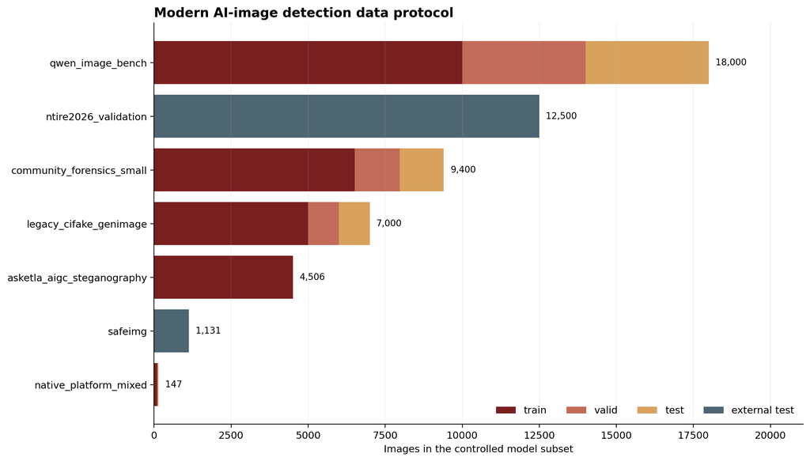

```python
from IPython.display import Image, display
display(Image(filename='outputs/figures/modern_detection_v1/dataset_protocol.png', width=1100))
```

#### 6.4.3 无泄漏切分与数据血缘审计

统一清单先保留数据来源、样本标识、生成器、切分、文件路径和研究用途，再构造受控的 52,684 张模型子集。Community Forensics 和 Qwen-Image-Bench 的生成器组在 train / valid / test 间不重叠；SafeIMG 与 NTIRE 的 `protocol_split` 固定为 `external_test`。旧 CIFAKE / GenImage 数据仅做历史可比性子集，不用它取代现代外部测试。

```python
import json
audit = json.loads((ROOT / "outputs/reports/modern_ai_detection_manifest_v1/audit.json").read_text(encoding="utf-8"))
modern_manifest = pd.read_csv(ROOT / "data/processed/experiment_tables/modern_ai_detection_model_subset_v1.csv", low_memory=False)
clip_embedding_metadata = json.loads((ROOT / "outputs/features/clip_binary_v1/metadata.json").read_text(encoding="utf-8"))
ensemble_summary = json.loads((ROOT / "outputs/reports/modern_detector_ensemble_v1/summary.json").read_text(encoding="utf-8"))
adaptation_summary = json.loads((ROOT / "outputs/reports/ntire_adapted_clip_v1/summary.json").read_text(encoding="utf-8"))
print("\n".join([
    "现代检测数据与切分审计",
    f"unified_manifest_rows      {audit['row_count']:,}",
    f"controlled_model_subset    {len(modern_manifest):,}",
    f"missing_path_count         {audit['missing_path_count']}",
    f"duplicate_sample_ids       {len(audit['duplicate_experiment_sample_ids'])}",
    f"generator_holdout_clean    {audit['generator_holdout_leakage_free']}",
    f"safeimg_training_rows      {audit['safeimg_training_rows']}",
    f"clip_completed_embeddings  {clip_embedding_metadata['completed_count']:,}",
    f"clip_failed_embeddings     {clip_embedding_metadata['failed_count']}",
    f"ensemble_aligned_rows      {ensemble_summary['aligned_rows']:,}",
    f"ntire_adapt_train_rows     {adaptation_summary['ntire_adaptation_training_rows']:,}",
    f"ntire_adapt_test_rows      {adaptation_summary['ntire_adaptation_test_rows']:,}",
    f"ntire_hard_training_rows   {adaptation_summary['ntire_hard_training_rows']}",
]))
```

```
现代检测数据与切分审计
unified_manifest_rows      82,955
controlled_model_subset    52,684
missing_path_count         0
duplicate_sample_ids       0
generator_holdout_clean    True
safeimg_training_rows      0
clip_completed_embeddings  52,684
clip_failed_embeddings     0
ensemble_aligned_rows      52,684
ntire_adapt_train_rows     2,000
ntire_adapt_test_rows      7,000
ntire_hard_training_rows   0
```

```python
modern_manifest = pd.read_csv(ROOT / "data/processed/experiment_tables/modern_ai_detection_model_subset_v1.csv", low_memory=False)
split_view = (modern_manifest.groupby(["source_family", "protocol_split", "label_name"], observed=True)
    .size().rename("n").reset_index()
    .pivot_table(index="source_family", columns=["protocol_split", "label_name"], values="n", fill_value=0, aggfunc="sum")
    .astype(int).reset_index())
split_view.columns = ["source_family" if not isinstance(c, tuple) else "_".join(x for x in c if x) for c in split_view.columns]
split_view
```

| source_family | external_test_generated | external_test_real | test_generated | test_real | train_generated | train_real | valid_generated | valid_real |
| --- | --- | --- | --- | --- | --- | --- | --- | --- |
| asketla_aigc_steganography | 0 | 0 | 0 | 0 | 4506 | 0 | 0 | 0 |
| community_forensics_small | 0 | 0 | 533 | 900 | 2310 | 4200 | 557 | 900 |
| legacy_cifake_genimage | 0 | 0 | 500 | 500 | 2500 | 2500 | 500 | 500 |
| native_platform_mixed | 0 | 0 | 20 | 4 | 86 | 13 | 20 | 4 |
| ntire2026_validation | 6250 | 6250 | 0 | 0 | 0 | 0 | 0 | 0 |
| qwen_image_bench | 0 | 0 | 4000 | 0 | 10000 | 0 | 4000 | 0 |
| safeimg | 1131 | 0 | 0 | 0 | 0 | 0 | 0 | 0 |

#### 6.4.4 三条模型路径与完整训练步骤

**路径 A：文件层 + 基础视觉特征。** 使用 64 个特征，包括尺寸、长宽比、文件大小、格式、EXIF、info 键、alpha、颜色、边缘和粗频域统计。它的优点是可解释、推理快，缺点是可能学到数据集或导出路径的快捷特征。

**路径 B：125 维纯像素取证特征。** 先对所有图像做 EXIF 方向校正、RGB 规范化、中心裁剪和 256×256 重采样，然后计算多尺度高斯/拉普拉斯残差、梯度方向、FFT 径向与方向频谱、8 像素块周期性、局部块一致性、JPEG q75/q90 重压缩残差、尺寸往返误差和噪声自相关。这条路径完全排除 EXIF、info、格式和原始尺寸。

**路径 C：冻结 CLIP ViT-B/32 + 线性探针。** 对每张图提取 512 维 L2 归一化视觉嵌入，不微调视觉编码器，只训练类别平衡的逻辑回归。这条路径参考 [Universal Fake Image Detector](https://openaccess.thecvf.com/content/CVPR2023/papers/Ojha_Towards_Universal_Fake_Image_Detectors_That_Generalize_Across_Generative_Models_CVPR_2023_paper.pdf) 的思路，目标是检验大规模预训练表征能否改善跨生成器泛化。

三条路径的共同步骤为：读取受控清单 → 仅在 train 上拟合 → 在 Community valid 上选模型并限制真实图误报 → 固定阈值 → 一次性评估隔离生成器与外部数据集 → 报告准确率、平衡准确率、生成类精确率/召回率/F1、ROC-AUC、真实图误报率、Brier 分数和 10 箱校准误差。

```python
base_candidates = pd.read_csv(ROOT / "outputs/tables/modern_aigc_detector_candidate_models_v1.csv")[[
    "feature_mode", "model_id", "selected", "tuned_threshold", "valid_balanced_accuracy_tuned",
    "valid_f1_generated_tuned", "valid_roc_auc", "valid_real_fpr_tuned"
]]
clip_candidates = pd.read_csv(ROOT / "outputs/reports/clip_binary_probe_v1/candidate_models.csv")
clip_candidates.insert(0, "feature_mode", "clip_embedding")
clip_candidates = clip_candidates.rename(columns={
    "threshold": "tuned_threshold", "valid_balanced_accuracy": "valid_balanced_accuracy_tuned",
    "valid_f1_generated": "valid_f1_generated_tuned", "valid_real_fpr": "valid_real_fpr_tuned",
})
candidate_view = pd.concat([base_candidates, clip_candidates[base_candidates.columns]], ignore_index=True)
candidate_view.round(4)
```

| feature_mode | model_id | selected | tuned_threshold | valid_balanced_accuracy_tuned | valid_f1_generated_tuned | valid_roc_auc | valid_real_fpr_tuned |
| --- | --- | --- | --- | --- | --- | --- | --- |
| enhanced_meta | logistic_regression | False | 0.685 | 0.9721 | 0.9613 | 0.9863 | 0.0378 |
| enhanced_meta | extra_trees | False | 0.920 | 0.9958 | 0.9937 | 0.9988 | 0.0067 |
| enhanced_meta | hist_gradient_boosting | True | 0.905 | 0.9958 | 0.9937 | 0.9992 | 0.0067 |
| forensic_visual_only | logistic_regression | False | 0.515 | 0.9260 | 0.9080 | 0.9744 | 0.0600 |
| forensic_visual_only | extra_trees | False | 0.735 | 0.9368 | 0.9225 | 0.9776 | 0.0456 |
| forensic_visual_only | hist_gradient_boosting | True | 0.615 | 0.9537 | 0.9399 | 0.9853 | 0.0478 |
| clip_embedding | clip_logreg_c0.01 | True | 0.345 | 0.9796 | 0.9733 | 0.9969 | 0.0211 |
| clip_embedding | clip_logreg_c0.1 | False | 0.490 | 0.9771 | 0.9713 | 0.9961 | 0.0189 |
| clip_embedding | clip_logreg_c1 | False | 0.325 | 0.9741 | 0.9662 | 0.9954 | 0.0267 |

```python
method_comparison = pd.read_csv(ROOT / "outputs/tables/modern_detection_method_comparison_v1.csv")
implemented = method_comparison[method_comparison["status"] == "implemented_and_rerun"]
implemented
```

| method | status | input | role | main_risk |
| --- | --- | --- | --- | --- |
| enhanced_meta + ExtraTrees/Logistic/HGB | implemented_and_rerun | file metadata plus color, edge and coarse frequency statistics | original-file evidence path and transparent baseline | metadata, format and resolution shortcuts may disappear after screenshots |
| 125D multi-scale forensic features | implemented_and_rerun | canonical pixels, noise residual, FFT, block, patch and recompression features | metadata-free content path for screenshots and re-exports | handcrafted features may miss new artifacts or be weakened by adaptive attacks |
| frozen CLIP ViT-B/32 linear probe | implemented_and_rerun | L2-normalized internet-scale pretrained visual embeddings | representation-level cross-generator generalization | latent dimensions are less human-readable and may retain semantic bias |
| robust and full-evidence ensembles | implemented_and_rerun | validation-selected weighted probabilities from complementary routes | separate screenshot/re-export handling from original-file handling | ensemble weights require monitoring as generator distributions evolve |
| CLIP few-shot NTIRE domain adaptation | implemented_and_rerun | frozen CLIP embeddings plus 2,000 labeled target-domain samples with explicit sample weighting | test whether data alignment can repair false positives under a new deployment domain | improves the target domain but degrades other domains, so it needs routing or domain-specific profiles |

#### 6.4.5 实验结果：域内进步与域外失效同时存在

在 Community Forensics 隔离生成器测试上，文件层路径、125 维取证路径、CLIP 路径和无元数据集成的平衡准确率分别为 **99.3%**、**91.8%**、**97.1%** 和 **97.2%**。SafeIMG 只含生成图，因此不报告“准确率”；纯像素取证和 CLIP 的生成召回率分别为 **99.2%** 和 **99.6%**。

但是，在严格外部的 NTIRE 2026 标准集上，无元数据集成的平衡准确率为 **52.8%**，真实图误报率为 **87.7%**。这表明完全未见数据来源下仍存在明显域偏移，不能把 Community 上的高分直接宣称为现实世界通用性。

这一现象与 2026 年对 16 种方法、12 个数据集、260 万张图和 291 个生成器的[综合基准研究](https://arxiv.org/abs/2602.07814)一致：不存在在所有数据上都稳定最优的检测器，训练数据与目标场景的对齐程度往往比单纯更换网络架构更重要。

因此，本轮最重要的结论有三点：

1. **更换逻辑回归、随机森林或梯度提升不是根本解决方案。** 域外性能更受数据匹配、成对真实/生成控制和生成器覆盖影响。
2. **文件层线索与内容层线索必须分开报告。** 前者适合原图快速初筛，后者适合截图、压缩和转存场景；两者都不是真实性证明。
3. **概率需要按部署域重新校准。** Brier 分数和校准误差在外部域显著恶化，网页端应输出“生成倾向 / 不确定 / 真实倾向”与复核建议，而不应把未校准分数当成精确百分比。

```python
metrics = pd.read_csv(ROOT / "outputs/tables/modern_detection_method_scope_comparison_v1.csv")
scope_order = [
    "primary_community_test", "qwen_unseen_generator_test", "safeimg_external_blind_test",
    "ntire2026_standard_external_test", "ntire2026_hard_external_test",
    "legacy_comparability_test", "native_export_test",
]
metric_view = metrics[metrics["eval_scope"].isin(scope_order)][[
    "method_label", "eval_scope", "n", "balanced_accuracy", "precision_generated",
    "recall_generated", "f1_generated", "roc_auc", "real_false_positive_rate",
    "brier_score", "expected_calibration_error_10bin",
]].copy()
metric_view["eval_scope"] = pd.Categorical(metric_view["eval_scope"], scope_order, ordered=True)
metric_view.sort_values(["method_label", "eval_scope"]).round(4)
```

| method_label | eval_scope | n | balanced_accuracy | precision_generated | recall_generated | f1_generated | roc_auc | real_false_positive_rate | brier_score | expected_calibration_error_10bin |
| --- | --- | --- | --- | --- | --- | --- | --- | --- | --- | --- |
| 125D forensic HGB | primary_community_test | 1433 | 0.9178 | 0.8420 | 0.9400 | 0.8883 | 0.9719 | 0.1044 | 0.0715 | 0.0623 |
| 125D forensic HGB | qwen_unseen_generator_test | 4000 | NaN | 1.0000 | 0.9642 | 0.9818 | NaN | NaN | 0.0217 | 0.0502 |
| 125D forensic HGB | safeimg_external_blind_test | 1131 | NaN | 1.0000 | 0.9920 | 0.9960 | NaN | NaN | 0.0040 | 0.0212 |
| 125D forensic HGB | ntire2026_standard_external_test | 10000 | 0.5091 | 0.5053 | 0.8700 | 0.6393 | 0.5549 | 0.8518 | 0.4184 | 0.4001 |
| 125D forensic HGB | ntire2026_hard_external_test | 2500 | 0.5068 | 0.5040 | 0.8648 | 0.6368 | 0.5311 | 0.8512 | 0.4231 | 0.4044 |
| 125D forensic HGB | legacy_comparability_test | 1000 | 0.5120 | 0.8750 | 0.0280 | 0.0543 | 0.6586 | 0.0040 | 0.2764 | 0.2272 |
| 125D forensic HGB | native_export_test | 24 | 0.5000 | 0.8333 | 1.0000 | 0.9091 | 0.7000 | 1.0000 | 0.1459 | 0.1428 |
| CLIP linear probe | primary_community_test | 1433 | 0.9706 | 0.9437 | 0.9756 | 0.9594 | 0.9950 | 0.0344 | 0.0226 | 0.0102 |
| CLIP linear probe | qwen_unseen_generator_test | 4000 | NaN | 1.0000 | 0.9975 | 0.9987 | NaN | NaN | 0.0032 | 0.0130 |
| CLIP linear probe | safeimg_external_blind_test | 1131 | NaN | 1.0000 | 0.9956 | 0.9978 | NaN | NaN | 0.0122 | 0.0491 |
| CLIP linear probe | ntire2026_standard_external_test | 10000 | 0.5172 | 0.5090 | 0.9678 | 0.6672 | 0.6257 | 0.9334 | 0.4045 | 0.3946 |
| CLIP linear probe | ntire2026_hard_external_test | 2500 | 0.5164 | 0.5087 | 0.9632 | 0.6657 | 0.5871 | 0.9304 | 0.4090 | 0.3941 |
| CLIP linear probe | legacy_comparability_test | 1000 | 0.5410 | 0.5880 | 0.2740 | 0.3738 | 0.6179 | 0.1920 | 0.3030 | 0.2460 |
| CLIP linear probe | native_export_test | 24 | 0.5000 | 0.8333 | 1.0000 | 0.9091 | 0.9750 | 1.0000 | 0.1251 | 0.1395 |
| File + visual HGB | primary_community_test | 1433 | 0.9926 | 0.9815 | 0.9962 | 0.9888 | 0.9995 | 0.0111 | 0.0325 | 0.0710 |
| File + visual HGB | qwen_unseen_generator_test | 4000 | NaN | 1.0000 | 0.8382 | 0.9120 | NaN | NaN | 0.0508 | 0.0886 |
| File + visual HGB | safeimg_external_blind_test | 1131 | NaN | 1.0000 | 0.1742 | 0.2967 | NaN | NaN | 0.4287 | 0.5639 |
| File + visual HGB | ntire2026_standard_external_test | 10000 | 0.4827 | 0.4734 | 0.3080 | 0.3732 | 0.4722 | 0.3426 | 0.4141 | 0.3728 |
| File + visual HGB | ntire2026_hard_external_test | 2500 | 0.5056 | 0.5097 | 0.2952 | 0.3739 | 0.5070 | 0.2840 | 0.3918 | 0.3493 |
| File + visual HGB | legacy_comparability_test | 1000 | 0.5070 | 1.0000 | 0.0140 | 0.0276 | 0.6326 | 0.0000 | 0.2818 | 0.2171 |
| File + visual HGB | native_export_test | 24 | 0.9750 | 1.0000 | 0.9500 | 0.9744 | 1.0000 | 0.0000 | 0.0175 | 0.0661 |
| Full-evidence ensemble | primary_community_test | 1433 | 0.9948 | 0.9981 | 0.9906 | 0.9944 | 0.9999 | 0.0011 | 0.0214 | 0.0652 |
| Full-evidence ensemble | qwen_unseen_generator_test | 4000 | NaN | 1.0000 | 0.9058 | 0.9505 | NaN | NaN | 0.0302 | 0.0697 |
| Full-evidence ensemble | safeimg_external_blind_test | 1131 | NaN | 1.0000 | 0.2599 | 0.4126 | NaN | NaN | 0.2536 | 0.4352 |
| Full-evidence ensemble | ntire2026_standard_external_test | 10000 | 0.4834 | 0.4809 | 0.4186 | 0.4476 | 0.4943 | 0.4518 | 0.3600 | 0.2983 |
| Full-evidence ensemble | ntire2026_hard_external_test | 2500 | 0.5120 | 0.5157 | 0.3944 | 0.4470 | 0.5208 | 0.3704 | 0.3370 | 0.2633 |
| Full-evidence ensemble | legacy_comparability_test | 1000 | 0.5130 | 1.0000 | 0.0260 | 0.0507 | 0.6406 | 0.0000 | 0.2832 | 0.2249 |
| Full-evidence ensemble | native_export_test | 24 | 0.9750 | 1.0000 | 0.9500 | 0.9744 | 1.0000 | 0.0000 | 0.0310 | 0.0859 |
| Robust content ensemble | primary_community_test | 1433 | 0.9718 | 0.9591 | 0.9681 | 0.9636 | 0.9954 | 0.0244 | 0.0238 | 0.0282 |
| Robust content ensemble | qwen_unseen_generator_test | 4000 | NaN | 1.0000 | 0.9950 | 0.9975 | NaN | NaN | 0.0040 | 0.0204 |
| Robust content ensemble | safeimg_external_blind_test | 1131 | NaN | 1.0000 | 0.9859 | 0.9929 | NaN | NaN | 0.0085 | 0.0435 |
| Robust content ensemble | ntire2026_standard_external_test | 10000 | 0.5278 | 0.5154 | 0.9324 | 0.6638 | 0.6210 | 0.8768 | 0.3959 | 0.3836 |
| Robust content ensemble | ntire2026_hard_external_test | 2500 | 0.5240 | 0.5133 | 0.9296 | 0.6614 | 0.5805 | 0.8816 | 0.3993 | 0.3815 |
| Robust content ensemble | legacy_comparability_test | 1000 | 0.5130 | 0.8824 | 0.0300 | 0.0580 | 0.6343 | 0.0040 | 0.2945 | 0.2405 |
| Robust content ensemble | native_export_test | 24 | 0.5000 | 0.8333 | 1.0000 | 0.9091 | 0.9125 | 1.0000 | 0.1281 | 0.1401 |

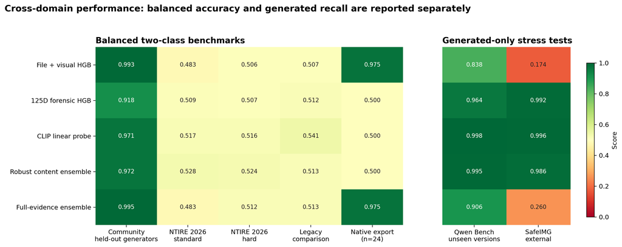

```python
from IPython.display import Image, display
display(Image(filename='outputs/figures/modern_detection_v1/cross_domain_performance.png', width=1100))
```

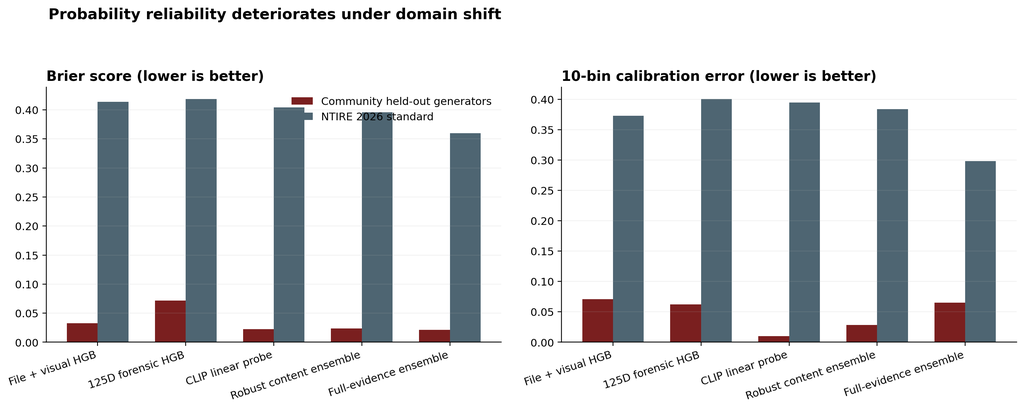

```python
from IPython.display import Image, display
display(Image(filename='outputs/figures/modern_detection_v1/calibration_shift.png', width=1100))
```

#### 6.4.6 少样本域适配：新数据能改善误报，但不能盲目覆盖通用模型

为了区分“网络结构不足”与“训练数据不对齐”，本项目在保留原始全量 NTIRE 盲测结果的前提下，又做了一个独立的少样本域适配实验。NTIRE 标准集按标签分层和稳定哈希划分为 2,000 张适配训练、1,000 张适配验证和 7,000 张最终测试；2,500 张困难集始终不参与拟合、选模型或阈值选择。视觉编码器仍然冻结，只重新训练带目标域样本权重的 CLIP 线性探针。

在完全相同的 7,000 张留出测试图上，基础 CLIP 模型与适配模型的平衡准确率从 **51.6%** 提升到 **69.9%**，真实图误报率从 **93.5%** 降到 **9.7%**。在完全未参与适配的困难集上，平衡准确率也从 **51.6%** 提升到 **63.4%**。这证明高质量目标域数据能够实质性改善模型，而不是只在原测试集上调一个阈值。

但适配模型在 Community 隔离生成器测试上从 **97.1%** 降到 **74.9%**，同时 Qwen 和 SafeIMG 的生成召回率也下降。这是典型的域间权衡：正确产品形态不是用 NTIRE 适配模型直接替换通用模型，而是保留多个专家档位，通过输入路径识别、域外检测、分场景校准和不确定性门控决定哪条路径可用。

```python
adaptation_view = pd.read_csv(ROOT / "outputs/tables/ntire_adapted_clip_scope_metrics_v1.csv")[[
    "method_id", "eval_scope", "n", "balanced_accuracy", "recall_generated",
    "real_false_positive_rate", "roc_auc", "brier_score", "expected_calibration_error_10bin",
]]
adaptation_view.round(4)
```

| method_id | eval_scope | n | balanced_accuracy | recall_generated | real_false_positive_rate | roc_auc | brier_score | expected_calibration_error_10bin |
| --- | --- | --- | --- | --- | --- | --- | --- | --- |
| clip_base_same_split | ntire_standard_adapt_test | 7000 | 0.5161 | 0.9671 | 0.9349 | 0.6223 | 0.4065 | 0.3964 |
| clip_base_same_split | ntire_hard_external_test | 2500 | 0.5164 | 0.9632 | 0.9304 | 0.5871 | 0.4090 | 0.3941 |
| clip_base_same_split | community_generator_holdout_test | 1433 | 0.9706 | 0.9756 | 0.0344 | 0.9950 | 0.0226 | 0.0102 |
| clip_base_same_split | qwen_unseen_generator_test | 4000 | NaN | 0.9975 | NaN | NaN | 0.0032 | 0.0130 |
| clip_base_same_split | safeimg_external_test | 1131 | NaN | 0.9956 | NaN | NaN | 0.0122 | 0.0491 |
| clip_base_same_split | native_export_test | 24 | 0.5000 | 1.0000 | 1.0000 | 0.9750 | 0.1251 | 0.1395 |
| clip_ntire_adapted | ntire_standard_adapt_test | 7000 | 0.6986 | 0.4943 | 0.0971 | 0.8259 | 0.1740 | 0.0577 |
| clip_ntire_adapted | ntire_hard_external_test | 2500 | 0.6344 | 0.4200 | 0.1512 | 0.7195 | 0.2306 | 0.1225 |
| clip_ntire_adapted | community_generator_holdout_test | 1433 | 0.7488 | 0.5009 | 0.0033 | 0.9535 | 0.0874 | 0.0728 |
| clip_ntire_adapted | qwen_unseen_generator_test | 4000 | NaN | 0.8390 | NaN | NaN | 0.0381 | 0.1118 |
| clip_ntire_adapted | safeimg_external_test | 1131 | NaN | 0.5411 | NaN | NaN | 0.1676 | 0.2974 |
| clip_ntire_adapted | native_export_test | 24 | 0.9500 | 0.9000 | 0.0000 | 0.9875 | 0.0340 | 0.0805 |

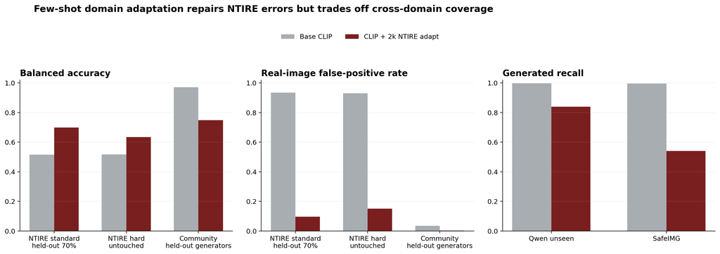

```python
from IPython.display import Image, display
display(Image(filename='outputs/figures/modern_detection_v1/domain_adaptation_tradeoff.png', width=1100))
```

#### 6.4.7 特征贡献与可解释边界

最终选中的 HistGradientBoosting 不提供像随机森林那样的内置特征重要性，因此本轮不用“没有重要性”来回避黑箱，而是在 Community 验证集上逐个打乱特征，记录 ROC-AUC 下降幅度。该数值回答“在当前数据和已拟合模型下，打乱这个特征会造成多大损失”，不证明因果关系，也不证明该特征是 AI 图的唯一指纹。

```python
importance = pd.read_csv(ROOT / "outputs/tables/modern_aigc_detector_feature_importance_v1.csv")
feature_dictionary = pd.read_csv(ROOT / "outputs/tables/modern_detection_forensic_feature_dictionary_v1.csv")
top_importance = importance.groupby("feature_mode", group_keys=False).head(12).copy()
lookup = feature_dictionary.set_index("feature")["feature_group"].to_dict()
top_importance["feature_group"] = top_importance["feature"].map(lookup).fillna("file_or_basic_visual")
top_importance[["feature_mode", "rank", "feature", "feature_group", "importance", "importance_method"]].round(6)
```

| feature_mode | rank | feature | feature_group | importance | importance_method |
| --- | --- | --- | --- | --- | --- |
| enhanced_meta | 1 | file_size_kb | file_or_basic_visual | 0.109141 | validation_permutation_importance_roc_auc |
| enhanced_meta | 2 | laplacian_var | file_or_basic_visual | 0.069842 | validation_permutation_importance_roc_auc |
| enhanced_meta | 3 | aspect_ratio | file_or_basic_visual | 0.000823 | validation_permutation_importance_roc_auc |
| enhanced_meta | 4 | channel_corr_rg | file_or_basic_visual | 0.000544 | validation_permutation_importance_roc_auc |
| enhanced_meta | 5 | info_key_count | file_or_basic_visual | 0.000428 | validation_permutation_importance_roc_auc |
| enhanced_meta | 6 | fft_band_4 | file_or_basic_visual | 0.000382 | validation_permutation_importance_roc_auc |
| enhanced_meta | 7 | edge_mean | file_or_basic_visual | 0.000326 | validation_permutation_importance_roc_auc |
| enhanced_meta | 8 | hist_b_7 | file_or_basic_visual | 0.000265 | validation_permutation_importance_roc_auc |
| enhanced_meta | 9 | megapixels | file_or_basic_visual | 0.000150 | validation_permutation_importance_roc_auc |
| enhanced_meta | 10 | hist_b_1 | file_or_basic_visual | 0.000091 | validation_permutation_importance_roc_auc |
| enhanced_meta | 11 | gray_p90 | file_or_basic_visual | 0.000089 | validation_permutation_importance_roc_auc |
| enhanced_meta | 12 | saturation_mean | file_or_basic_visual | 0.000086 | validation_permutation_importance_roc_auc |
| forensic_visual_only | 1 | gradient_orientation_6 | gradient_structure | 0.007785 | validation_permutation_importance_roc_auc |
| forensic_visual_only | 2 | fft_axis_vertical | frequency_spectrum | 0.005745 | validation_permutation_importance_roc_auc |
| forensic_visual_only | 3 | fft_radial_logmean_7 | frequency_spectrum | 0.005079 | validation_permutation_importance_roc_auc |
| forensic_visual_only | 4 | chroma_rg_std | color_distribution | 0.003464 | validation_permutation_importance_roc_auc |
| forensic_visual_only | 5 | jpeg_q90_p95_abs | recompression_error | 0.002600 | validation_permutation_importance_roc_auc |
| forensic_visual_only | 6 | gradient_orientation_1 | gradient_structure | 0.002529 | validation_permutation_importance_roc_auc |
| forensic_visual_only | 7 | color_corr_rb | color_distribution | 0.001240 | validation_permutation_importance_roc_auc |
| forensic_visual_only | 8 | fft_axis_diagonal | frequency_spectrum | 0.001170 | validation_permutation_importance_roc_auc |
| forensic_visual_only | 9 | gradient_orientation_entropy | gradient_structure | 0.001039 | validation_permutation_importance_roc_auc |
| forensic_visual_only | 10 | color_r_clip_high | color_distribution | 0.000973 | validation_permutation_importance_roc_auc |
| forensic_visual_only | 11 | fft_radial_energy_1 | frequency_spectrum | 0.000943 | validation_permutation_importance_roc_auc |
| forensic_visual_only | 12 | residual_scale_ratio_2_4 | multi_scale_noise_residual | 0.000799 | validation_permutation_importance_roc_auc |

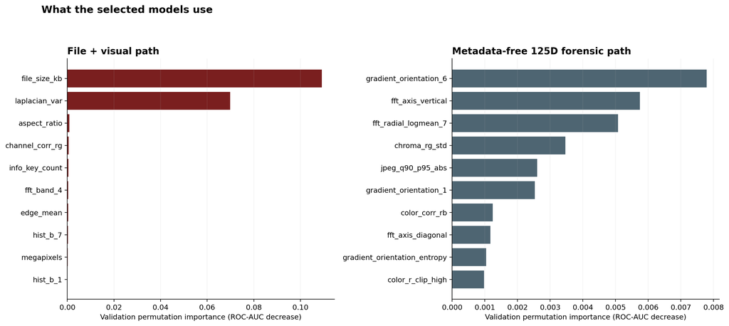

```python
from IPython.display import Image, display
display(Image(filename='outputs/figures/modern_detection_v1/feature_importance.png', width=1100))
```

#### 6.4.8 除现有方法外，还可以从哪些方向识别 AI 图像

单图二分类只是完整解决方案的一层。结合本轮结果与近年研究，可以形成六类互补方向：

1. **低层生成痕迹。** [NPR](https://openaccess.thecvf.com/content/CVPR2024/html/Tan_Rethinking_the_Up-Sampling_Operations_in_CNN-based_Generative_Network_for_Generalizable_CVPR_2024_paper.html) 学习相邻像素关系与上采样引入的局部周期性，可作为可学习的低层专家。
2. **重建残差。** [DIRE](https://openaccess.thecvf.com/content/ICCV2023/html/Wang_DIRE_for_Diffusion-Generated_Image_Detection_ICCV_2023_paper.html) 利用扩散重建误差，[AEROBLADE](https://openaccess.thecvf.com/content/CVPR2024/html/Ricker_AEROBLADE_Training-Free_Detection_of_Latent_Diffusion_Images_Using_Autoencoder_Reconstruction_CVPR_2024_paper.html) 利用潜空间自编码器重建误差，两者可以作为扩散模型特化证据。
3. **频域与语义联合建模。** [FatFormer](https://openaccess.thecvf.com/content/CVPR2024/papers/Liu_Forgery-aware_Adaptive_Transformer_for_Generalizable_Synthetic_Image_Detection_CVPR_2024_paper.pdf) 将空间信息与频域伪造线索结合，比单纯手工频谱特征具有更强表示能力。
4. **配对数据与去偏训练。** [B-Free](https://openaccess.thecvf.com/content/CVPR2025/html/Guillaro_A_Bias-Free_Training_Paradigm_for_More_General_AI-generated_Image_Detection_CVPR_2025_paper.html) 通过语义和品质更可控的真实/生成配对，减少模型偷学分辨率、内容类别或数据源。这是解决本轮 NTIRE 域偏移的重点。
5. **多专家、结构—纹理双流与可解释模型。** [OmniAID](https://arxiv.org/abs/2511.08423) 将内容域专家与通用伪影专家分开；2026 年的 [GPT Image2 / Nano Banana2 基准](https://arxiv.org/abs/2608.01258) 进一步提出结构伪影先验与纹理、结构双流建模，更适合文档、截图、文本密集图和局部编辑；[AIGI-Holmes](https://openaccess.thecvf.com/content/ICCV2025/html/Zhou_AIGI-Holmes_Towards_Explainable_and_Generalizable_AI-Generated_Image_Detection_via_Multimodal_ICCV_2025_paper.html) 则学习可审阅的异常区域与文字理由。解释仍需与取证证据交叉验证，不能把模型文字当成事实。
6. **正向来源证明与案件上下文。** 优先校验 [C2PA](https://spec.c2pa.org/about/about/) 签名凭证、平台签名导出记录或 [SynthID](https://deepmind.google/models/synthid/) 等供应商水印；对外卖与电商售后场景，再比较多角度图片的异物位置、几何结构、时间、订单和沟通记录。这一层判断的对象是“案件风险”，不再只是“单张图像”。

```python
method_comparison = pd.read_csv(ROOT / "outputs/tables/modern_detection_method_comparison_v1.csv")
future = method_comparison[method_comparison["status"] != "implemented_and_rerun"]
future
```

| method | status | input | role | main_risk |
| --- | --- | --- | --- | --- |
| NPR / neighboring-pixel detector | future_candidate | local pixel relationships introduced by generator upsampling | learnable low-level artifact expert | strong re-sampling and post-processing can suppress local periodicity |
| DIRE or AEROBLADE reconstruction error | future_candidate | diffusion or latent-autoencoder reconstruction residual | training-free or low-training diffusion-specific evidence | computationally expensive and less suitable for non-diffusion generators |
| OmniAID-style mixture of semantic and artifact experts | future_candidate | domain router, content experts and universal artifact expert | separate what is depicted from how the pixels were produced | requires larger paired data, GPU training and careful expert calibration |
| AIGI-Holmes or LEGION explainable MLLM | future_candidate | image, visual expert features and explanation supervision | produce human-verifiable suspicious regions and reasons | explanations may hallucinate and cannot replace forensic evidence |
| SAP-DSP structure-texture dual stream | future_candidate | structural artifact prior plus separate texture and structure prompt streams | detect text-rich documents, screenshots, local edits and hybrid MLLM-generated content | new benchmark and code require independent reproduction; model explanations remain probabilistic |
| C2PA credentials and platform watermark verification | future_system_layer | cryptographic provenance manifests or provider-specific invisible watermarks | positive provenance verification before probabilistic detection | absence is not proof of authenticity; credentials can be stripped and coverage is platform-specific |
| multi-image and transaction-context consistency | future_system_layer | multiple angles, object geometry, timestamps, order records and conversation behavior | case-level after-sales fraud risk assessment rather than single-image classification | requires privacy governance, human review and platform cooperation |

#### 6.4.9 未来落地方案：从一个分类器升级为七层证据系统

未来的官方平台不应将某个模型分数作为单独定责依据，而应按“来源证明优先、概率检测互补、不确定性显式、人工复核兜底”的顺序建立证据链。七层架构不是七个同类模型堆叠，而是七类不同证据的分工。

```python
architecture = pd.read_csv(ROOT / "outputs/tables/modern_detection_future_architecture_v1.csv")
architecture
```

| layer | name | decision | output |
| --- | --- | --- | --- |
| 1 | provenance_verification | Verify C2PA, signed export records and provider watermark when available. | verified provenance / absent / invalid |
| 2 | file_forensics | Inspect EXIF, PNG info, dimensions, encoding and export-path signatures. | transparent file evidence |
| 3 | pixel_forensics | Fuse multi-scale residual, NPR-like and reconstruction evidence. | artifact probability and suspicious regions |
| 4 | domain_router_and_semantic_reasoning | Estimate domain/OOD status, route to calibrated experts, then use CLIP/MoE/MLLM semantic evidence. | domain profile, semantic probability and constrained rationale |
| 5 | case_consistency | Compare multiple views, object position, time, order and communication context. | case-level inconsistency score |
| 6 | calibrated_governance | Return generated / real-like / uncertain and route uncertain or high-impact cases to review. | auditable report and human decision |
| 7 | continual_monitoring | Add temporal holdouts, drift alarms and periodic generator-family updates. | versioned benchmark and retraining trigger |

#### 6.4.10 复现命令与产物路径

本轮新增的数据清单、特征、嵌入、模型、预测、指标、特征贡献和图表都已落盘。关键脚本的执行顺序如下：

```
python scripts/216_download_modern_detection_datasets_v1.py --dataset all
python scripts/226_prepare_ntire2026_validation_v1.py
python scripts/217_build_modern_detection_manifest_v1.py --require-safeimg
python scripts/218_extract_modern_detection_features_v1.py --mode all
python scripts/219_train_modern_aigc_detectors_v1.py --mode all --bootstrap-iterations 500
python scripts/220_extract_clip_binary_embeddings_v1.py --device auto
python scripts/221_train_clip_binary_probe_v1.py --bootstrap-iterations 500
python scripts/224_evaluate_modern_detector_ensemble_v1.py
python scripts/230_train_ntire_adapted_clip_v1.py
python scripts/225_build_modern_detection_research_tables_v1.py
python scripts/228_build_modern_detection_figures_v1.py
```

主结果表位于 `outputs/tables/modern_*_v1.csv`，主图位于 `outputs/figures/modern_detection_v1/`，模型与详细预测位于 `outputs/reports/modern_aigc_detectors_v1/`、`outputs/reports/clip_binary_probe_v1/` 和 `outputs/reports/modern_detector_ensemble_v1/`。